[binary.com](https://github.com/englianhu/binary.com-interview-question) 面试试题 I - 多变量数据缺失值管理 II

[®γσ, Lian Hu（黄联富）](https://englianhu.github.io/) ®

2018-10-25

```r
suppressPackageStartupMessages(require('BBmisc'))

## 读取程序包
pkg <- c('devtools', 'tidyverse', 'timetk', 'lubridate', 'plyr', 'dplyr', 'magrittr', 'purrr', 'stringr', 'reshape', 'formattable', 'microbenchmark', 'knitr', 'kableExtra', 'VIM', 'mice', 'miceAdds', 'mi', 'mitools', 'Amelia', 'missForest', 'Hmisc', 'DMwR', 'imputeTS', 'tidyimpute', 'mtsdi', 'xts', 'forecast', 'marima', 'missMDA')

suppressAll(lib(pkg))
funs <- c('convertOHLC.R')
l_ply(funs, function(x) source(paste0('./function/', x)))

algo <- c('interpolation', 'locf', 'mean', 'random', 'kalman', 'ma')
rm(pkg, funs)
```

# 1 简介

## 1.1 介绍弥补数据

由于在科研[binary.com Interview Question I - Interday High Frequency Trading Models Comparison](https://rpubs.com/englianhu/binary-Q1Inter-HFT)测试高频率量化交易时，从fxcm/MarketData下载的数据并不完整[^1]，[binary.com 面试试题 I - 单变量数据缺失值管理](http://rpubs.com/englianhu/handle-missing-value)尝试弥补缺失值不果，单变量无法辨认开市价、最高价、最低价和闭市价之间的关系。

- [How to use auto.arima to impute missing values](https://stats.stackexchange.com/questions/104565/how-to-use-auto-arima-to-impute-missing-values)使用`auto.arima()`来弥补缺失值。
- [What should be the allowed percentage of Missing Values?](https://discuss.analyticsvidhya.com/t/what-should-be-the-allowed-percentage-of-missing-values/2456)讨论着一个数据最多可以允许20%~30%的缺失值，过多的缺失值的话，该数据基本上就无法使用了。一些统计学家有本事将50%缺失值的数据复原，不过是基于许多附属变量和数据才能弥补回数据。
- [Principled Missing Data Methods for Researchers](https://www.ncbi.nlm.nih.gov/pmc/articles/PMC3701793/)讲述许多弥补数据缺失值的方法与数学模式。
- [Imputation methods for time series data](https://stats.stackexchange.com/questions/261271/imputation-methods-for-time-series-data)
- [Imputing Missing Observation in Multivariate Time Series](https://stats.stackexchange.com/questions/103968/imputing-missing-observation-in-multivariate-time-series)
- [`imputeTS`: Time Series Missing Value Imputation in R](https://journal.r-project.org/archive/2017/RJ-2017-009/index.html)
- [How to Handle Missing Data](https://towardsdatascience.com/how-to-handle-missing-data-8646b18db0d4)

## 1.2 `impueTS`程序包

*imputeTS - Time Series Missing Value Imputation in R*讲述`mice`、`Amelia`、`missMDA`与`VIM`都是多变量弥补数据程序包，而`imputeTS`乃单变量弥补数据程序包，不过程序包中的`seadec()`函数乃弥补季节性数据。

| Simple | Imputation Imputation | Plots & Statistics | Datasets |
| --- | --- | --- | --- |
| na.locf | na.interpolation | plotNA.distribution | tsAirgap |
| na.mean | na.kalman | plotNA.distributionBar | tsAirgapComplete |
| na.random | na.ma | plotNA.gapsize | tsHeating |
| na.replace | na.seadec | plotNA.imputations | tsHeatingComplete |
| na.remove | na.seasplit | statsNA | tsNH4 |
|  |  |  | tsNH4Complete |

*Table 1: General Overview imputeTS package*

| Function | Option | Description |
| --- | --- | --- |
| na.interpolation | linear | Imputation by Linear Interpolation |
|  | spline | Imputation by Spline Interpolation |
|  | stine | Imputation by Stineman Interpolation |
| na.kalman | StructTS | Imputation by Structural Model & Kalman Smoothing |
|  | auto.arima | Imputation by ARIMA State Space Representation & Kalman Sm. |
| na.locf | locf | Imputation by Last Observation Carried Forward |
|  | nocb | Imputation by Next Observation Carried Backward |
| na.ma | simple | Missing Value Imputation by Simple Moving Average |
|  | linear | Missing Value Imputation by Linear Weighted Moving Average |
|  | exponential | Missing Value Imputation by Exponential Weighted Moving Average |
| na.mean | mean | MissingValue Imputation by Mean Value |
|  | median | Missing Value Imputation by Median Value |
|  | mode | Missing Value Imputation by Mode Value |
| na.random |  | Missing Value Imputation by Random Sample |
| na.replace |  | Replace Missing Values by a Defined Value |
| na.seadec |  | Seasonally Decomposed Missing Value Imputation |
| na.seasplit |  | Seasonally Splitted Missing Value Imputation |
| na.remove |  | Remove Missing Values |

*Table 3: Overview Imputation Algorithms*

## 1.3 `Amelia`程序包

[Amelia II: A Program for Missing Data](https://gking.harvard.edu/amelia)介绍`Amelia`程序包，而*AMELIA II - A Program for Missing Data*教导如何使用该程序包。[Error in as.POSIXct.numeric(value) : ‘origin’ must be supplied #18](https://github.com/IQSS/Amelia/issues/18)显示时间变量无法弥补，故此对于`Amelia`缺失值，僕得省略掉时间变量，仅设置价格变量为缺失值而已。

## 1.4 其它程序包

`mice`程序包可以使用`lm`函数将弥补数据线型化，`tidyr`程序包中有个`fill()`函数可以。而`dendextend::na_locf()`会比`zoo::na.locf()`高效率，不过弥补数据时会遇到一些参数问题。

# 2 数据

## 2.1 读取数据

### 2.1.1 1分钟数据

和之前的单变量一样，首先僕随机导入每分钟为1个时间单位的数据。

[output not shown]

由于频频出现错误信息[#imputeTS/issues/26](https://github.com/SteffenMoritz/imputeTS/issues/26)，于此僕使用sort(sample(length(fls), 1))随机筛选1个文件。

```r
pth <- 'C:/Users/scibr/Documents/GitHub/scibrokes/real-time-fxcm/data/USDJPY/'
fls <- list.files(pth, pattern = '^Y[0-9]{4}W[1-9]{1,2}_m1.rds$')

## 1分钟数据
## 由于频频出现错误信息，于此僕使用sort(sample(length(fls), 1))随机筛选4个文件。
data_m1 <- llply(fls[sort(sample(length(fls), 1))], function(x) {
    y <- readRDS(paste0(pth, x)) %>%
      dplyr::rename(index = DateTime) %>%
      mutate(index = index %>% mdy_hms %>%
               .POSIXct(tz = 'Europe/Athens') %>%
               force_tz())

    yw <- x %>% str_extract_all('Y[0-9]{4}W[0-9]{1,2}') %>%
      str_split_fixed('[A-Z]{1}', 3) %>% .[,-1]

    nch <- y$index[1] %>% substr(nchar(.)+2, nchar(.)+3)
    y %<>% mutate(
      year = as.numeric(yw[1]), week = as.numeric(yw[2]),
      nch = nch, index = if_else(
        nch == '23', index + hours(1), index)) %>%
      dplyr::select(-nch)
    }) %>% bind_rows %>% tbl_df %>% arrange(index)
dim(data_m1)
```

```
## [1] 7149   11
```

```r
data_m1
```

```
## # A tibble: 7,149 x 11
##    index               BidOpen BidHigh BidLow BidClose AskOpen AskHigh
##    <dttm>                <dbl>   <dbl>  <dbl>    <dbl>   <dbl>   <dbl>
##  1 2016-10-17 00:00:00    104.    104.   104.     104.    104.    104.
##  2 2016-10-17 00:01:00    104.    104.   104.     104.    104.    104.
##  3 2016-10-17 00:02:00    104.    104.   104.     104.    104.    104.
##  4 2016-10-17 00:03:00    104.    104.   104.     104.    104.    104.
##  5 2016-10-17 00:04:00    104.    104.   104.     104.    104.    104.
##  6 2016-10-17 00:05:00    104.    104.   104.     104.    104.    104.
##  7 2016-10-17 00:06:00    104.    104.   104.     104.    104.    104.
##  8 2016-10-17 00:07:00    104.    104.   104.     104.    104.    104.
##  9 2016-10-17 00:08:00    104.    104.   104.     104.    104.    104.
## 10 2016-10-17 00:09:00    104.    104.   104.     104.    104.    104.
## # ... with 7,139 more rows, and 4 more variables: AskLow <dbl>,
## #   AskClose <dbl>, year <dbl>, week <dbl>
```

```r
## 检验原始数据是否存在偏差。
data_m1 %<>% mutate(
  bias.open = if_else(AskOpen>AskHigh|AskOpen<AskLow, 1, 0),
  bias.high = if_else(AskHigh<AskOpen|AskHigh<AskLow|AskHigh<AskClose, 1, 0),
  bias.low = if_else(AskLow>AskOpen|AskLow>AskHigh|AskLow>AskClose, 1, 0),
  bias.close = if_else(AskClose>AskHigh|AskClose<AskLow, 1, 0))

data_m1 %>%
  dplyr::filter(bias.open==1|bias.high==1|bias.low==1|bias.close==1) %>%
  kable(caption = 'Bias Imputation') %>%
  kable_styling(bootstrap_options = c('striped', 'hover', 'condensed', 'responsive')) %>%
  scroll_box(width = '100%', height = '400px')
```

Bias Imputation

| index | BidOpen | BidHigh | BidLow | BidClose | AskOpen | AskHigh | AskLow | AskClose | year | week | bias.open | bias.high | bias.low | bias.close |
| --- | --- | --- | --- | --- | --- | --- | --- | --- | --- | --- | --- | --- | --- | --- |

### 2.1.2 Tick数据转为1分钟数据

接着，导入Tick数据[^2]，并且转为每分钟为1时间单位。

```r
pth <- 'C:/Users/scibr/Documents/GitHub/scibrokes/real-time-fxcm/data/USDJPY/'
fls <- list.files(pth, pattern = '^Y[0-9]{4}W[1-9]{1,2}.rds$')

## Tick数据转为1分钟数据
## 由于频频出现错误信息，于此僕使用sort(sample(length(fls), 1))随机筛选2个文件。
data_tm1 <- llply(fls[sort(sample(length(fls), 1))], function(x) {
    y <- readRDS(paste0(pth, x)) %>%
      convertOHLC(combine = TRUE)

    yw <- x %>% str_extract_all('Y[0-9]{4}W[0-9]{1,2}') %>%
      str_split_fixed('[A-Z]{1}', 3) %>% .[,-1]
    y %<>% mutate(
      year = as.numeric(yw[1]), week = as.numeric(yw[2]), .)
    }) %>% bind_rows %>% tbl_df %>% arrange(index)
dim(data_tm1)
```

```
## [1] 1628   11
```

```r
data_tm1
```

```
## # A tibble: 1,628 x 11
##    index               BidOpen BidHigh BidLow BidClose AskOpen AskHigh
##    <dttm>                <dbl>   <dbl>  <dbl>    <dbl>   <dbl>   <dbl>
##  1 2017-08-07 00:02:00    111.    111.   111.     111.    111.    111.
##  2 2017-08-07 00:03:00    111.    111.   111.     111.    111.    111.
##  3 2017-08-07 00:04:00    111.    111.   111.     111.    111.    111.
##  4 2017-08-07 00:05:00    111.    111.   111.     111.    111.    111.
##  5 2017-08-07 00:06:00    111.    111.   111.     111.    111.    111.
##  6 2017-08-07 00:07:00    111.    111.   111.     111.    111.    111.
##  7 2017-08-07 00:08:00    111.    111.   111.     111.    111.    111.
##  8 2017-08-07 00:09:00    111.    111.   111.     111.    111.    111.
##  9 2017-08-07 00:11:00    111.    111.   111.     111.    111.    111.
## 10 2017-08-07 00:17:00    111.    111.   111.     111.    111.    111.
## # ... with 1,618 more rows, and 4 more variables: AskLow <dbl>,
## #   AskClose <dbl>, year <dbl>, week <dbl>
```

```r
## 检验原始数据是否存在偏差。
data_tm1 %<>% mutate(
  bias.open = if_else(AskOpen>AskHigh|AskOpen<AskLow, 1, 0),
  bias.high = if_else(AskHigh<AskOpen|AskHigh<AskLow|AskHigh<AskClose, 1, 0),
  bias.low = if_else(AskLow>AskOpen|AskLow>AskHigh|AskLow>AskClose, 1, 0),
  bias.close = if_else(AskClose>AskHigh|AskClose<AskLow, 1, 0))

data_tm1 %>%
  dplyr::filter(bias.open==1|bias.high==1|bias.low==1|bias.close==1) %>%
  kable(caption = 'Bias Imputation') %>%
  kable_styling(bootstrap_options = c('striped', 'hover', 'condensed', 'responsive')) %>%
  scroll_box(width = '100%', height = '400px')
```

Bias Imputation

| index | BidOpen | BidHigh | BidLow | BidClose | AskOpen | AskHigh | AskLow | AskClose | year | week | bias.open | bias.high | bias.low | bias.close |
| --- | --- | --- | --- | --- | --- | --- | --- | --- | --- | --- | --- | --- | --- | --- |

## 2.2 设置缺失值

### 2.2.1 1分钟数据

现在尝试随机设置缺失值。

```r
data_m1_NA <- data_m1 %>%
  dplyr::select(index, BidOpen, BidHigh, BidLow, BidClose, AskOpen, AskHigh, AskLow,  AskClose) %>%
  prodNA(noNA = 0.01)
data_m1_NA
```

```
## # A tibble: 7,149 x 9
##    index               BidOpen BidHigh BidLow BidClose AskOpen AskHigh
##    <dttm>                <dbl>   <dbl>  <dbl>    <dbl>   <dbl>   <dbl>
##  1 2016-10-17 00:00:00    104.    104.   104.     104.    104.    104.
##  2 2016-10-17 00:01:00    104.    104.   104.     104.    104.    104.
##  3 2016-10-17 00:02:00    104.    104.   104.     104.    104.    104.
##  4 2016-10-17 00:03:00    104.    104.   104.     104.    104.    104.
##  5 2016-10-17 00:04:00    104.    104.   104.     104.    104.    104.
##  6 2016-10-17 00:05:00    104.    104.   104.     104.    104.    104.
##  7 2016-10-17 00:06:00    104.    104.   104.     104.    104.    104.
##  8 2016-10-17 00:07:00    104.    104.   104.     104.    104.    104.
##  9 2016-10-17 00:08:00    104.    104.   104.     104.    104.    104.
## 10 2016-10-17 00:09:00    104.    104.   104.     104.    104.    104.
## # ... with 7,139 more rows, and 2 more variables: AskLow <dbl>,
## #   AskClose <dbl>
```

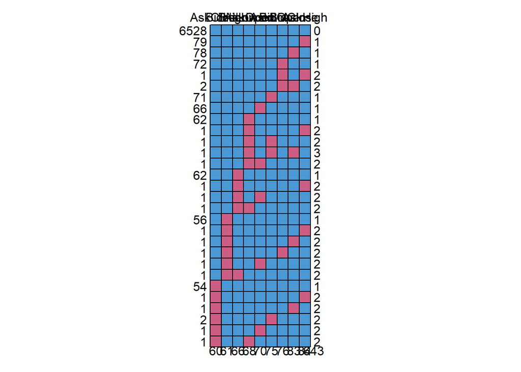

```
##      AskClose BidHigh BidLow AskOpen index AskLow BidOpen BidClose AskHigh
## 6528        1       1      1       1     1      1       1        1       1
## 79          1       1      1       1     1      1       1        1       0
## 78          1       1      1       1     1      1       1        0       1
## 72          1       1      1       1     1      1       0        1       1
## 1           1       1      1       1     1      1       0        1       0
## 2           1       1      1       1     1      1       0        0       1
## 71          1       1      1       1     1      0       1        1       1
## 66          1       1      1       1     0      1       1        1       1
## 62          1       1      1       0     1      1       1        1       1
## 1           1       1      1       0     1      1       1        1       0
## 1           1       1      1       0     1      0       1        1       1
## 1           1       1      1       0     1      0       1        0       1
## 1           1       1      1       0     0      1       1        1       1
## 62          1       1      0       1     1      1       1        1       1
```

[output cut: 47 more lines]

```r
data_m1_NA %>% md.pattern
```

```r
data_m1_NA %>% md.pairs
```

```
## $rr
##          index BidOpen BidHigh BidLow BidClose AskOpen AskHigh AskLow
## index     7079    7003    7019   7014     6996    7012    6995   7004
## BidOpen   7003    7073    7013   7007     6992    7005    6990   6998
## BidHigh   7019    7013    7088   7023     7006    7020    7005   7013
## BidLow    7014    7007    7023   7083     7000    7016    7000   7008
## BidClose  6996    6992    7006   7000     7066    6999    6982   6992
## AskOpen   7012    7005    7020   7016     6999    7081    6998   7008
## AskHigh   6995    6990    7005   7000     6982    6998    7065   6990
## AskLow    7004    6998    7013   7008     6992    7008    6990   7074
## AskClose  7020    7013    7028   7023     7007    7022    7006   7016
##          AskClose
## index        7020
## BidOpen      7013
## BidHigh      7028
## BidLow       7023
## BidClose     7007
## AskOpen      7022
## AskHigh      7006
## AskLow       7016
## AskClose     7089
##
## $rm
##          index BidOpen BidHigh BidLow BidClose AskOpen AskHigh AskLow
## index        0      76      60     65       83      67      84     75
## BidOpen     70       0      60     66       81      68      83     75
## BidHigh     69      75       0     65       82      68      83     75
## BidLow      69      76      60      0       83      67      83     75
## BidClose    70      74      60     66        0      67      84     74
## AskOpen     69      76      61     65       82       0      83     73
## AskHigh     70      75      60     65       83      67       0     75
## AskLow      70      76      61     66       82      66      84      0
## AskClose    69      76      61     66       82      67      83     73
##          AskClose
## index          59
## BidOpen        60
## BidHigh        60
## BidLow         60
## BidClose       59
## AskOpen        59
```

[output cut: 32 more lines]

```
## BidClose     0       2       1      0       83       1       0      1
## AskOpen      1       0       0      1        1      68       1      2
## AskHigh      0       1       1      1        0       1      84      0
## AskLow       0       0       0      0        1       2       0     75
## AskClose     1       0       0      0        1       1       1      2
##          AskClose
## index           1
## BidOpen         0
## BidHigh         0
## BidLow          0
## BidClose        1
## AskOpen         1
## AskHigh         1
## AskLow          2
## AskClose       60
```

### 2.2.2 Tick数据转为1分钟数据

```r
data_tm1_NA <- data_tm1 %>%
  dplyr::select(index, BidOpen, BidHigh, BidLow, BidClose, AskOpen, AskHigh, AskLow,  AskClose) %>%
  prodNA(noNA = 0.01)
data_tm1_NA
```

```
## # A tibble: 1,628 x 9
##    index               BidOpen BidHigh BidLow BidClose AskOpen AskHigh
##    <dttm>                <dbl>   <dbl>  <dbl>    <dbl>   <dbl>   <dbl>
##  1 2017-08-07 00:02:00    111.    111.   111.     111.    111.    111.
##  2 2017-08-07 00:03:00    111.    111.   111.     111.    111.    111.
##  3 2017-08-07 00:04:00    111.    111.   111.     111.    111.    111.
##  4 2017-08-07 00:05:00    111.    111.   111.     111.    111.    111.
##  5 2017-08-07 00:06:00    111.    111.   111.     111.    111.    111.
##  6 2017-08-07 00:07:00    111.    111.   111.     111.    111.    111.
##  7 2017-08-07 00:08:00    111.    111.   111.     111.    111.    111.
##  8 2017-08-07 00:09:00    111.    111.   111.     111.    111.    111.
##  9 2017-08-07 00:11:00    111.    111.   111.     111.    111.    111.
## 10 2017-08-07 00:17:00    111.    111.    NA      111.    111.    111.
## # ... with 1,618 more rows, and 2 more variables: AskLow <dbl>,
## #   AskClose <dbl>
```

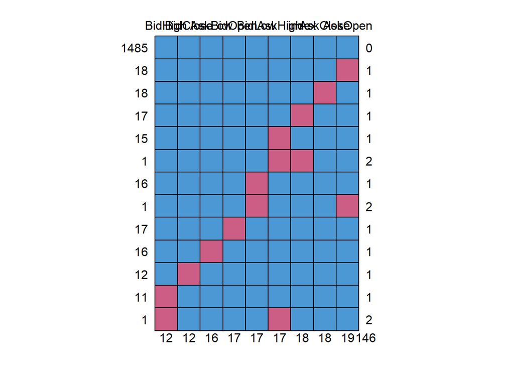

```
##      BidHigh BidClose AskLow BidOpen BidLow AskHigh index AskClose AskOpen
## 1485       1        1      1       1      1       1     1        1       1
## 18         1        1      1       1      1       1     1        1       0
## 18         1        1      1       1      1       1     1        0       1
## 17         1        1      1       1      1       1     0        1       1
## 15         1        1      1       1      1       0     1        1       1
## 1          1        1      1       1      1       0     0        1       1
## 16         1        1      1       1      0       1     1        1       1
## 1          1        1      1       1      0       1     1        1       0
## 17         1        1      1       0      1       1     1        1       1
## 16         1        1      0       1      1       1     1        1       1
## 12         1        0      1       1      1       1     1        1       1
## 11         0        1      1       1      1       1     1        1       1
## 1          0        1      1       1      1       0     1        1       1
##           12       12     16      17     17      17    18       18      19
##
## 1485   0
## 18     1
## 18     1
## 17     1
## 15     1
## 1      2
## 16     1
## 1      2
## 17     1
## 16     1
## 12     1
## 11     1
## 1      2
##      146
```

```r
data_tm1_NA %>% md.pattern
```

```r
data_tm1_NA %>% md.pairs
```

```
## $rr
##          index BidOpen BidHigh BidLow BidClose AskOpen AskHigh AskLow
## index     1610    1593    1598   1593     1598    1591    1594   1594
## BidOpen   1593    1611    1599   1594     1599    1592    1594   1595
## BidHigh   1598    1599    1616   1599     1604    1597    1600   1600
## BidLow    1593    1594    1599   1611     1599    1593    1594   1595
## BidClose  1598    1599    1604   1599     1616    1597    1599   1600
## AskOpen   1591    1592    1597   1593     1597    1609    1592   1593
## AskHigh   1594    1594    1600   1594     1599    1592    1611   1595
## AskLow    1594    1595    1600   1595     1600    1593    1595   1612
## AskClose  1592    1593    1598   1593     1598    1591    1593   1594
##          AskClose
## index        1592
## BidOpen      1593
## BidHigh      1598
## BidLow       1593
## BidClose     1598
## AskOpen      1591
## AskHigh      1593
## AskLow       1594
## AskClose     1610
##
## $rm
##          index BidOpen BidHigh BidLow BidClose AskOpen AskHigh AskLow
## index        0      17      12     17       12      19      16     16
## BidOpen     18       0      12     17       12      19      17     16
## BidHigh     18      17       0     17       12      19      16     16
## BidLow      18      17      12      0       12      18      17     16
## BidClose    18      17      12     17        0      19      17     16
## AskOpen     18      17      12     16       12       0      17     16
## AskHigh     17      17      11     17       12      19       0     16
## AskLow      18      17      12     17       12      19      17      0
## AskClose    18      17      12     17       12      19      17     16
##          AskClose
## index          18
## BidOpen        18
## BidHigh        18
## BidLow         18
## BidClose       18
## AskOpen        18
```

[output cut: 32 more lines]

```
## BidClose     0       0       0      0       12       0       0      0
## AskOpen      0       0       0      1        0      19       0      0
## AskHigh      1       0       1      0        0       0      17      0
## AskLow       0       0       0      0        0       0       0     16
## AskClose     0       0       0      0        0       0       0      0
##          AskClose
## index           0
## BidOpen         0
## BidHigh         0
## BidLow          0
## BidClose        0
## AskOpen         0
## AskHigh         0
## AskLow          0
## AskClose       18
```

# 3 统计模式

## 3.1 弥补缺失值

- [Imputing missing data with R; MICE package](https://www.r-bloggers.com/imputing-missing-data-with-r-mice-package/)
- [mice - Multivariate Imputation by Chained Equations in R](https://github.com/englianhu/binary.com-interview-question/blob/master/reference/mice%20Multivariate%20Imputation%20by%20Chained%20Equations%20in%20R.pdf)
- [mice : Multivariate Imputation by Chained Equations](https://github.com/stefvanbuuren/mice)
- [HOW DO I PERFORM MULTIPLE IMPUTATION USING PREDICTIVE MEAN MATCHING IN R? | R FAQ](https://stats.idre.ucla.edu/r/faq/how-do-i-perform-multiple-imputation-using-predictive-mean-matching-in-r/)
- [Imputing missing observation in multivariate time series](https://stats.stackexchange.com/questions/103968/imputing-missing-observation-in-multivariate-time-series)
- [arima method in mtsdi](https://stackoverflow.com/questions/29472532/arima-method-in-mtsdi)
- [Dealing with Missing Data using R](https://medium.com/coinmonks/dealing-with-missing-data-using-r-3ae428da2d17)
- [How to use auto.arima to impute missing values](https://stats.stackexchange.com/questions/104565/how-to-use-auto-arima-to-impute-missing-values)
- [How to Fill in Missing Data in Time Series?](https://stats.stackexchange.com/questions/245615/how-to-fill-in-missing-data-in-time-series)
- [Forecasting Multivariate Data with `auto.arima`](https://stackoverflow.com/questions/15495465/forecasting-multivariate-data-with-auto-arima)
- [Multivariate Time Series Model](https://stackoverflow.com/questions/44376808/multivariate-time-series-model)
- [`auto.arima` using `xreg` and Forecasting Several ts Together](https://stackoverflow.com/questions/25036986/auto-arima-using-xreg-and-forecasting-several-ts-together)
- [`auto.arima` Forecast with Multivariate `xreg` - unexpected Results](https://stackoverflow.com/questions/15054800/auto-arima-forecast-with-multivariate-xreg-unexpected-results)
- [`auto.arima` Warns `NaNs` Produced on Std Error](https://stats.stackexchange.com/questions/26999/auto-arima-warns-nans-produced-on-std-error)
- [Arima time series forecast (auto.arima) with multiple exogeneous variables in R](https://stats.stackexchange.com/questions/122803/arima-time-series-forecast-auto-arima-with-multiple-exogeneous-variables-in-r)
- [Multivariate ARIMA with regression](https://stats.stackexchange.com/questions/45993/multivariate-arima-with-regression)
- [I am trying to do a multivariate time series analysis on r. how to use auto.arima with Xreg?](https://www.researchgate.net/post/I_am_trying_to_do_a_multivariate_time_series_analysis_on_r_how_to_use_autoarima_with_Xreg)

```r
tttt <- data_m1_NA[-1] %>% amelia
```

```
## -- Imputation 1 --
##
##   1  2
##
## -- Imputation 2 --
##
##   1  2
##
## -- Imputation 3 --
##
##   1  2
##
## -- Imputation 4 --
##
##   1  2
##
## -- Imputation 5 --
##
##   1  2
```

```r
llply(tttt$imputations, function(x) {
    x %>% mutate(
  VA = if_else(AskOpen <= AskHigh & AskOpen >= AskLow &
               AskClose <= AskHigh & AskClose >= AskLow &
               AskHigh >= AskLow, 1, 0),
  VB = if_else(BidOpen <= BidHigh & BidOpen >= BidLow &
               BidClose <= BidHigh & BidClose >= BidLow &
               BidHigh >= BidLow, 1, 0)) %>%
  dplyr::filter(VA == 0|VB == 0)
})
```

```
## $imp1
## # A tibble: 114 x 10
##    BidOpen BidHigh BidLow BidClose AskOpen AskHigh AskLow AskClose    VA
##      <dbl>   <dbl>  <dbl>    <dbl>   <dbl>   <dbl>  <dbl>    <dbl> <dbl>
##  1    104.    104.   104.     104.    104.    104.   104.     104.     0
##  2    104.    104.   104.     104.    104.    104.   104.     104.     0
##  3    104.    104.   104.     104.    104.    104.   104.     104.     1
##  4    104.    104.   104.     104.    104.    104.   104.     104.     1
##  5    104.    104.   104.     104.    104.    104.   104.     104.     0
##  6    104.    104.   104.     104.    104.    104.   104.     104.     0
##  7    104.    104.   104.     104.    104.    104.   104.     104.     1
##  8    104.    104.   104.     104.    104.    104.   104.     104.     1
##  9    104.    104.   104.     104.    104.    104.   104.     104.     1
## 10    104.    104.   104.     104.    104.    104.   104.     104.     1
## # ... with 104 more rows, and 1 more variable: VB <dbl>
##
## $imp2
## # A tibble: 106 x 10
##    BidOpen BidHigh BidLow BidClose AskOpen AskHigh AskLow AskClose    VA
##      <dbl>   <dbl>  <dbl>    <dbl>   <dbl>   <dbl>  <dbl>    <dbl> <dbl>
##  1    104.    104.   104.     104.    104.    104.   104.     104.     0
##  2    104.    104.   104.     104.    104.    104.   104.     104.     0
##  3    104.    104.   104.     104.    104.    104.   104.     104.     1
##  4    104.    104.   104.     104.    104.    104.   104.     104.     0
##  5    104.    104.   104.     104.    104.    104.   104.     104.     1
##  6    104.    104.   104.     104.    104.    104.   104.     104.     1
##  7    104.    104.   104.     104.    104.    104.   104.     104.     1
##  8    104.    104.   104.     104.    104.    104.   104.     104.     1
##  9    104.    104.   104.     104.    104.    104.   104.     104.     1
## 10    104.    104.   104.     104.    104.    104.   104.     104.     1
## # ... with 96 more rows, and 1 more variable: VB <dbl>
##
## $imp3
## # A tibble: 107 x 10
##    BidOpen BidHigh BidLow BidClose AskOpen AskHigh AskLow AskClose    VA
##      <dbl>   <dbl>  <dbl>    <dbl>   <dbl>   <dbl>  <dbl>    <dbl> <dbl>
##  1    104.    104.   104.     104.    104.    104.   104.     104.     0
##  2    104.    104.   104.     104.    104.    104.   104.     104.     0
##  3    104.    104.   104.     104.    104.    104.   104.     104.     0
##  4    104.    104.   104.     104.    104.    104.   104.     104.     0
```

[output cut: 24 more lines]

```
## $imp5
## # A tibble: 95 x 10
##    BidOpen BidHigh BidLow BidClose AskOpen AskHigh AskLow AskClose    VA
##      <dbl>   <dbl>  <dbl>    <dbl>   <dbl>   <dbl>  <dbl>    <dbl> <dbl>
##  1    104.    104.   104.     104.    104.    104.   104.     104.     0
##  2    104.    104.   104.     104.    104.    104.   104.     104.     1
##  3    104.    104.   104.     104.    104.    104.   104.     104.     0
##  4    104.    104.   104.     104.    104.    104.   104.     104.     1
##  5    104.    104.   104.     104.    104.    104.   104.     104.     0
##  6    104.    104.   104.     104.    104.    104.   104.     104.     1
##  7    104.    104.   104.     104.    104.    104.   104.     104.     1
##  8    104.    104.   104.     104.    104.    104.   104.     104.     1
##  9    104.    104.   104.     104.    104.    104.   104.     104.     1
## 10    104.    104.   104.     104.    104.    104.   104.     104.     1
## # ... with 85 more rows, and 1 more variable: VB <dbl>
```

经过测试以上数据，结果发现`amelia`也是单变量数据弥补。

**注释：单变量弥补的数据将会与之前单变量预测数据一样，就是出现偏差，例如：**

- 开市价高于最高价
- 开市价低于最低价
- 最高价低于开市价
- 最高价低于最低价
- 最高价低于闭市价
- 最低价高于开市价
- 最低价高于最高价
- 最低价高于闭市价
- 闭市价高于最高价
- 闭市价低于最低价

## 3.2 1% 缺失值

### 3.2.1 1分钟数据

以下使用`imputeTS::na.seadec()`弥补1%数据缺失值。

```r
data_m1_NA <- data_m1 %>%
  dplyr::select(BidOpen, BidHigh, BidLow, BidClose,
                AskOpen, AskHigh, AskLow,  AskClose) %>%
  prodNA(noNA = 0.01) %>%
  cbind(data_m1[1], .) %>% tbl_df

data_m1_1_impTS <- llply(algo, function(x) {
  data_m1_NA %>%
    dplyr::select(starts_with('Ask'), starts_with('Bid')) %>%
    map(na.seadec, algorithm = x) %>% as.tibble
  })
names(data_m1_1_impTS) <- algo
data_m1_1_impTS %<>% ldply %>% tbl_df

data_m1_1_impTS %<>% mutate(
  bias.open = if_else(AskOpen>AskHigh|AskOpen<AskLow, 1, 0),
  bias.high = if_else(AskHigh<AskOpen|AskHigh<AskLow|AskHigh<AskClose, 1, 0),
  bias.low = if_else(AskLow>AskOpen|AskLow>AskHigh|AskLow>AskClose, 1, 0),
  bias.close = if_else(AskClose>AskHigh|AskClose<AskLow, 1, 0))

data_m1_1_impTS %>%
  dplyr::filter(bias.open==1|bias.high==1|bias.low==1|bias.close==1)
```

```
## # A tibble: 702 x 13
##    .id   AskOpen AskHigh AskLow AskClose BidOpen BidHigh BidLow BidClose
##    <chr>   <dbl>   <dbl>  <dbl>    <dbl>   <dbl>   <dbl>  <dbl>    <dbl>
##  1 inte~    104.    104.   104.     104.    104.    104.   104.     104.
##  2 inte~    104.    104.   104.     104.    104.    104.   104.     104.
##  3 inte~    104.    104.   104.     104.    104.    104.   104.     104.
##  4 inte~    104.    104.   104.     104.    104.    104.   104.     104.
##  5 inte~    104.    104.   104.     104.    104.    104.   104.     104.
##  6 inte~    104.    104.   104.     104.    104.    104.   104.     104.
##  7 inte~    104.    104.   104.     104.    104.    104.   104.     104.
##  8 inte~    104.    104.   104.     104.    104.    104.   104.     104.
##  9 inte~    104.    104.   104.     104.    104.    104.   104.     104.
## 10 inte~    104.    104.   104.     104.    104.    104.   104.     104.
## # ... with 692 more rows, and 4 more variables: bias.open <dbl>,
## #   bias.high <dbl>, bias.low <dbl>, bias.close <dbl>
```

```r
data_m1_1_impTS %<>%
  ddply(.(.id), summarise,
        AskOpen = mean((AskOpen - data_m1$AskOpen)^2),
        AskHigh = mean((AskHigh - data_m1$AskHigh)^2),
        AskLow = mean((AskLow - data_m1$AskLow)^2),
        AskClose = mean((AskClose - data_m1$AskClose)^2),
        Mean.HLC = (AskHigh + AskLow + AskClose)/3,
        Mean.OHLC = (AskOpen + AskHigh + AskLow + AskClose)/4,
        bias.open = sum(bias.open)/length(bias.open),
        bias.high = sum(bias.high)/length(bias.high),
        bias.low = sum(bias.low)/length(bias.low),
        bias.close = sum(bias.close)/length(bias.close)) %>% tbl_df

data_m1_1_impTS %>%
  kable(caption = 'MSE') %>%
  kable_styling(bootstrap_options = c('striped', 'hover', 'condensed', 'responsive')) %>%
  scroll_box(width = '100%')#, height = '400px')
```

MSE

| .id | AskOpen | AskHigh | AskLow | AskClose | Mean.HLC | Mean.OHLC | bias.open | bias.high | bias.low | bias.close |
| --- | --- | --- | --- | --- | --- | --- | --- | --- | --- | --- |
| interpolation | 0.0000006 | 0.0000008 | 0.0000009 | 0.0000013 | 0.0000010 | 0.0000009 | 0.0048958 | 0.0062946 | 0.0048958 | 0.0062946 |
| kalman | 0.0000006 | 0.0000008 | 0.0000009 | 0.0000013 | 0.0000010 | 0.0000009 | 0.0050357 | 0.0064345 | 0.0050357 | 0.0064345 |
| locf | 0.0000014 | 0.0000031 | 0.0000018 | 0.0000036 | 0.0000029 | 0.0000025 | 0.0037768 | 0.0053154 | 0.0043363 | 0.0058749 |
| ma | 0.0000007 | 0.0000014 | 0.0000012 | 0.0000013 | 0.0000013 | 0.0000012 | 0.0079731 | 0.0088124 | 0.0067142 | 0.0086725 |
| mean | 0.0005507 | 0.0005905 | 0.0004618 | 0.0006969 | 0.0005831 | 0.0005750 | 0.0194433 | 0.0179046 | 0.0205623 | 0.0194433 |
| random | 0.0024076 | 0.0006038 | 0.0023222 | 0.0008296 | 0.0012519 | 0.0015408 | 0.0145475 | 0.0093719 | 0.0195832 | 0.0145475 |

以下使用`Amelia::amelia()`弥补1%数据缺失值。

```r
data_m1_1_amelia <- data_m1_NA %>%
  amelia %>%
  .$imputations %>%
  ldply %>% tbl_df
```

```
## -- Imputation 1 --
##
##   1  2
##
## -- Imputation 2 --
##
##   1  2
##
## -- Imputation 3 --
##
##   1  2
##
## -- Imputation 4 --
##
##   1  2
##
## -- Imputation 5 --
##
##   1  2
```

```r
data_m1_1_amelia %>% anyNA
```

```
## [1] FALSE
```

```r
data_m1_1_amelia %<>% mutate(
  bias.open = if_else(AskOpen>AskHigh|AskOpen<AskLow, 1, 0),
  bias.high = if_else(AskHigh<AskOpen|AskHigh<AskLow|AskHigh<AskClose, 1, 0),
  bias.low = if_else(AskLow>AskOpen|AskLow>AskHigh|AskLow>AskClose, 1, 0),
  bias.close = if_else(AskClose>AskHigh|AskClose<AskLow, 1, 0))

data_m1_1_amelia %>%
  dplyr::filter(bias.open==1|bias.high==1|bias.low==1|bias.close==1)
```

```
## # A tibble: 237 x 14
##    .id   index               BidOpen BidHigh BidLow BidClose AskOpen
##    <chr> <dttm>                <dbl>   <dbl>  <dbl>    <dbl>   <dbl>
##  1 imp1  2016-10-17 00:37:00    104.    104.   104.     104.    104.
##  2 imp1  2016-10-17 02:44:00    104.    104.   104.     104.    104.
##  3 imp1  2016-10-17 02:46:00    104.    104.   104.     104.    104.
##  4 imp1  2016-10-17 07:04:00    104.    104.   104.     104.    104.
##  5 imp1  2016-10-17 12:23:00    104.    104.   104.     104.    104.
##  6 imp1  2016-10-17 16:06:00    104.    104.   104.     104.    104.
##  7 imp1  2016-10-17 17:35:00    104.    104.   104.     104.    104.
##  8 imp1  2016-10-17 19:19:00    104.    104.   104.     104.    104.
##  9 imp1  2016-10-17 23:38:00    104.    104.   104.     104.    104.
## 10 imp1  2016-10-18 00:27:00    104.    104.   104.     104.    104.
## # ... with 227 more rows, and 7 more variables: AskHigh <dbl>,
## #   AskLow <dbl>, AskClose <dbl>, bias.open <dbl>, bias.high <dbl>,
## #   bias.low <dbl>, bias.close <dbl>
```

```r
data_m1_1_amelia %<>%
  ddply(.(.id), summarise,
        AskOpen = mean((AskOpen - data_m1$AskOpen)^2),
        AskHigh = mean((AskHigh - data_m1$AskHigh)^2),
        AskLow = mean((AskLow - data_m1$AskLow)^2),
        AskClose = mean((AskClose - data_m1$AskClose)^2),
        Mean.HLC = (AskHigh + AskLow + AskClose)/3,
        Mean.OHLC = (AskOpen + AskHigh + AskLow + AskClose)/4,
        bias.open = sum(bias.open)/length(bias.open),
        bias.high = sum(bias.high)/length(bias.high),
        bias.low = sum(bias.low)/length(bias.low),
        bias.close = sum(bias.close)/length(bias.close)) %>% tbl_df

data_m1_1_amelia %>%
  kable(caption = 'MSE') %>%
  kable_styling(bootstrap_options = c('striped', 'hover', 'condensed', 'responsive')) %>%
  scroll_box(width = '100%')#, height = '400px')
```

MSE

| .id | AskOpen | AskHigh | AskLow | AskClose | Mean.HLC | Mean.OHLC | bias.open | bias.high | bias.low | bias.close |
| --- | --- | --- | --- | --- | --- | --- | --- | --- | --- | --- |
| imp1 | 0 | 1e-07 | 1e-07 | 3e-07 | 1e-07 | 1e-07 | 0.0039166 | 0.0034970 | 0.0030774 | 0.0029375 |
| imp2 | 0 | 1e-07 | 0e+00 | 2e-07 | 1e-07 | 1e-07 | 0.0032172 | 0.0034970 | 0.0029375 | 0.0036369 |
| imp3 | 0 | 0e+00 | 0e+00 | 2e-07 | 1e-07 | 1e-07 | 0.0036369 | 0.0033571 | 0.0030774 | 0.0032172 |
| imp4 | 0 | 1e-07 | 0e+00 | 2e-07 | 1e-07 | 1e-07 | 0.0037768 | 0.0036369 | 0.0029375 | 0.0032172 |
| imp5 | 0 | 0e+00 | 0e+00 | 2e-07 | 1e-07 | 1e-07 | 0.0043363 | 0.0043363 | 0.0034970 | 0.0040565 |

以下使用`tidyr::fill()`弥补1%数据缺失值。

```r
data_m1_1_tidyr <- data_m1_NA %>%
  fill(BidOpen, BidHigh, BidLow, BidClose,
       AskOpen, AskHigh, AskLow, AskClose) %>% #default direction down
  fill(BidOpen, BidHigh, BidLow, BidClose,
       AskOpen, AskHigh, AskLow, AskClose, .direction = 'up')

data_m1_1_tidyr %>% anyNA
```

```
## [1] FALSE
```

```r
data_m1_1_tidyr %<>% mutate(
  bias.open = if_else(AskOpen>AskHigh|AskOpen<AskLow, 1, 0),
  bias.high = if_else(AskHigh<AskOpen|AskHigh<AskLow|AskHigh<AskClose, 1, 0),
  bias.low = if_else(AskLow>AskOpen|AskLow>AskHigh|AskLow>AskClose, 1, 0),
  bias.close = if_else(AskClose>AskHigh|AskClose<AskLow, 1, 0))

data_m1_1_tidyr %>%
  dplyr::filter(bias.open==1|bias.high==1|bias.low==1|bias.close==1)
```

```
## # A tibble: 69 x 13
##    index               BidOpen BidHigh BidLow BidClose AskOpen AskHigh
##    <dttm>                <dbl>   <dbl>  <dbl>    <dbl>   <dbl>   <dbl>
##  1 2016-10-17 02:25:00    104.    104.   104.     104.    104.    104.
##  2 2016-10-17 02:34:00    104.    104.   104.     104.    104.    104.
##  3 2016-10-17 03:52:00    104.    104.   104.     104.    104.    104.
##  4 2016-10-17 04:04:00    104.    104.   104.     104.    104.    104.
##  5 2016-10-17 04:46:00    104.    104.   104.     104.    104.    104.
##  6 2016-10-17 08:00:00    104.    104.   104.     104.    104.    104.
##  7 2016-10-17 10:16:00    104.    104.   104.     104.    104.    104.
##  8 2016-10-17 12:23:00    104.    104.   104.     104.    104.    104.
##  9 2016-10-17 14:11:00    104.    104.   104.     104.    104.    104.
## 10 2016-10-17 16:58:00    104.    104.   104.     104.    104.    104.
## # ... with 59 more rows, and 6 more variables: AskLow <dbl>,
## #   AskClose <dbl>, bias.open <dbl>, bias.high <dbl>, bias.low <dbl>,
## #   bias.close <dbl>
```

```r
data_m1_1_tidyr %<>%
  summarise(
    AskOpen = mean((AskOpen - data_m1$AskOpen)^2),
    AskHigh = mean((AskHigh - data_m1$AskHigh)^2),
    AskLow = mean((AskLow - data_m1$AskLow)^2),
    AskClose = mean((AskClose - data_m1$AskClose)^2),
    Mean.HLC = (AskHigh + AskLow + AskClose)/3,
    Mean.OHLC = (AskOpen + AskHigh + AskLow + AskClose)/4,
    bias.open = sum(bias.open)/length(bias.open),
    bias.high = sum(bias.high)/length(bias.high),
    bias.low = sum(bias.low)/length(bias.low),
    bias.close = sum(bias.close)/length(bias.close)) %>% tbl_df

data_m1_1_tidyr %>%
  kable(caption = 'MSE') %>%
  kable_styling(bootstrap_options = c('striped', 'hover', 'condensed', 'responsive')) %>%
  scroll_box(width = '100%')#, height = '400px')
```

MSE

| AskOpen | AskHigh | AskLow | AskClose | Mean.HLC | Mean.OHLC | bias.open | bias.high | bias.low | bias.close |
| --- | --- | --- | --- | --- | --- | --- | --- | --- | --- |
| 1.4e-06 | 3.1e-06 | 1.8e-06 | 3.6e-06 | 2.9e-06 | 2.5e-06 | 0.0037768 | 0.0053154 | 0.0043363 | 0.0058749 |

### 3.2.2 Tick数据转为1分钟数据

以下使用`imputeTS::na.seadec()`弥补1%数据缺失值。

```r
data_tm1_NA <- data_tm1 %>%
  dplyr::select(BidOpen, BidHigh, BidLow, BidClose,
                AskOpen, AskHigh, AskLow,  AskClose) %>%
  prodNA(noNA = 0.01) %>%
  cbind(data_tm1[1], .) %>% tbl_df

data_tm1_1_impTS <- llply(algo, function(x) {
  data_tm1_NA %>%
    dplyr::select(starts_with('Ask'), starts_with('Bid')) %>%
    map(na.seadec, algorithm = x) %>% as.tibble
  })
names(data_tm1_1_impTS) <- algo
data_tm1_1_impTS %<>% ldply %>% tbl_df

data_tm1_1_impTS %<>% mutate(
  bias.open = if_else(AskOpen>AskHigh|AskOpen<AskLow, 1, 0),
  bias.high = if_else(AskHigh<AskOpen|AskHigh<AskLow|AskHigh<AskClose, 1, 0),
  bias.low = if_else(AskLow>AskOpen|AskLow>AskHigh|AskLow>AskClose, 1, 0),
  bias.close = if_else(AskClose>AskHigh|AskClose<AskLow, 1, 0))

data_tm1_1_impTS %>%
  dplyr::filter(bias.open==1|bias.high==1|bias.low==1|bias.close==1)
```

```
## # A tibble: 143 x 13
##    .id   AskOpen AskHigh AskLow AskClose BidOpen BidHigh BidLow BidClose
##    <chr>   <dbl>   <dbl>  <dbl>    <dbl>   <dbl>   <dbl>  <dbl>    <dbl>
##  1 inte~    111.    111.   111.     111.    111.    111.   111.     111.
##  2 inte~    111.    111.   111.     111.    111.    111.   111.     111.
##  3 inte~    111.    111.   111.     111.    111.    111.   111.     111.
##  4 inte~    111.    111.   111.     111.    111.    111.   111.     111.
##  5 inte~    111.    111.   111.     111.    111.    111.   111.     111.
##  6 inte~    111.    111.   111.     111.    111.    111.   111.     111.
##  7 inte~    111.    111.   111.     111.    111.    111.   111.     111.
##  8 locf     111.    111.   111.     111.    111.    111.   111.     111.
##  9 locf     111.    111.   111.     111.    111.    111.   111.     111.
## 10 locf     111.    111.   111.     111.    111.    111.   111.     111.
## # ... with 133 more rows, and 4 more variables: bias.open <dbl>,
## #   bias.high <dbl>, bias.low <dbl>, bias.close <dbl>
```

```r
data_tm1_1_impTS %<>%
  ddply(.(.id), summarise,
        AskOpen = mean((AskOpen - data_m1$AskOpen)^2),
        AskHigh = mean((AskHigh - data_m1$AskHigh)^2),
        AskLow = mean((AskLow - data_m1$AskLow)^2),
        AskClose = mean((AskClose - data_m1$AskClose)^2),
        Mean.HLC = (AskHigh + AskLow + AskClose)/3,
        Mean.OHLC = (AskOpen + AskHigh + AskLow + AskClose)/4,
        bias.open = sum(bias.open)/length(bias.open),
        bias.high = sum(bias.high)/length(bias.high),
        bias.low = sum(bias.low)/length(bias.low),
        bias.close = sum(bias.close)/length(bias.close)) %>% tbl_df

data_tm1_1_impTS %>%
  kable(caption = 'MSE') %>%
  kable_styling(bootstrap_options = c('striped', 'hover', 'condensed', 'responsive')) %>%
  scroll_box(width = '100%')#, height = '400px')
```

MSE

| .id | AskOpen | AskHigh | AskLow | AskClose | Mean.HLC | Mean.OHLC | bias.open | bias.high | bias.low | bias.close |
| --- | --- | --- | --- | --- | --- | --- | --- | --- | --- | --- |
| interpolation | 48.06478 | 48.03953 | 48.09285 | 48.06702 | 48.06647 | 48.06605 | 0.0024570 | 0.0012285 | 0.0030713 | 0.0018428 |
| kalman | 48.06484 | 48.03953 | 48.09285 | 48.06702 | 48.06646 | 48.06606 | 0.0030713 | 0.0024570 | 0.0030713 | 0.0024570 |
| locf | 48.06471 | 48.03943 | 48.09250 | 48.06706 | 48.06633 | 48.06592 | 0.0079853 | 0.0067568 | 0.0030713 | 0.0024570 |
| ma | 48.06507 | 48.03947 | 48.09286 | 48.06706 | 48.06647 | 48.06612 | 0.0055283 | 0.0055283 | 0.0042998 | 0.0055283 |
| mean | 48.06836 | 48.03966 | 48.09137 | 48.06870 | 48.06658 | 48.06702 | 0.0165848 | 0.0184275 | 0.0128993 | 0.0159705 |
| random | 48.06803 | 48.03820 | 48.10323 | 48.06020 | 48.06721 | 48.06742 | 0.0221130 | 0.0178133 | 0.0233415 | 0.0196560 |

以下使用`Amelia::amelia()`弥补1%数据缺失值。

```r
data_tm1_1_amelia <- data_tm1_NA %>%
  amelia %>%
  .$imputations %>%
  ldply %>% tbl_df
```

```
## -- Imputation 1 --
##
##   1  2
##
## -- Imputation 2 --
##
##   1  2
##
## -- Imputation 3 --
##
##   1  2
##
## -- Imputation 4 --
##
##   1  2
##
## -- Imputation 5 --
##
##   1  2
```

```r
data_tm1_1_amelia %>% anyNA
```

```
## [1] FALSE
```

```r
data_tm1_1_amelia %<>% mutate(
  bias.open = if_else(AskOpen>AskHigh|AskOpen<AskLow, 1, 0),
  bias.high = if_else(AskHigh<AskOpen|AskHigh<AskLow|AskHigh<AskClose, 1, 0),
  bias.low = if_else(AskLow>AskOpen|AskLow>AskHigh|AskLow>AskClose, 1, 0),
  bias.close = if_else(AskClose>AskHigh|AskClose<AskLow, 1, 0))

data_tm1_1_amelia %>%
  dplyr::filter(bias.open==1|bias.high==1|bias.low==1|bias.close==1)
```

```
## # A tibble: 67 x 14
##    .id   index               BidOpen BidHigh BidLow BidClose AskOpen
##    <chr> <dttm>                <dbl>   <dbl>  <dbl>    <dbl>   <dbl>
##  1 imp1  2017-08-07 03:37:00    111.    111.   111.     111.    111.
##  2 imp1  2017-08-07 04:59:00    111.    111.   111.     111.    111.
##  3 imp1  2017-08-07 05:33:00    111.    111.   111.     111.    111.
##  4 imp1  2017-08-07 07:13:00    111.    111.   111.     111.    111.
##  5 imp1  2017-08-07 11:32:00    111.    111.   111.     111.    111.
##  6 imp1  2017-08-07 13:46:00    111.    111.   111.     111.    111.
##  7 imp1  2017-08-07 18:02:00    111.    111.   111.     111.    111.
##  8 imp1  2017-08-07 18:38:00    111.    111.   111.     111.    111.
##  9 imp1  2017-08-07 20:20:00    111.    111.   111.     111.    111.
## 10 imp1  2017-08-07 20:25:00    111.    111.   111.     111.    111.
## # ... with 57 more rows, and 7 more variables: AskHigh <dbl>,
## #   AskLow <dbl>, AskClose <dbl>, bias.open <dbl>, bias.high <dbl>,
## #   bias.low <dbl>, bias.close <dbl>
```

```r
data_tm1_1_amelia %<>%
  ddply(.(.id), summarise,
        AskOpen = mean((AskOpen - data_m1$AskOpen)^2),
        AskHigh = mean((AskHigh - data_m1$AskHigh)^2),
        AskLow = mean((AskLow - data_m1$AskLow)^2),
        AskClose = mean((AskClose - data_m1$AskClose)^2),
        Mean.HLC = (AskHigh + AskLow + AskClose)/3,
        Mean.OHLC = (AskOpen + AskHigh + AskLow + AskClose)/4,
        bias.open = sum(bias.open)/length(bias.open),
        bias.high = sum(bias.high)/length(bias.high),
        bias.low = sum(bias.low)/length(bias.low),
        bias.close = sum(bias.close)/length(bias.close)) %>% tbl_df

data_tm1_1_amelia %>%
  kable(caption = 'MSE') %>%
  kable_styling(bootstrap_options = c('striped', 'hover', 'condensed', 'responsive')) %>%
  scroll_box(width = '100%')#, height = '400px')
```

MSE

| .id | AskOpen | AskHigh | AskLow | AskClose | Mean.HLC | Mean.OHLC | bias.open | bias.high | bias.low | bias.close |
| --- | --- | --- | --- | --- | --- | --- | --- | --- | --- | --- |
| imp1 | 48.06482 | 48.03931 | 48.09267 | 48.06713 | 48.06637 | 48.06598 | 0.0055283 | 0.0055283 | 0.0030713 | 0.0030713 |
| imp2 | 48.06482 | 48.03929 | 48.09266 | 48.06683 | 48.06626 | 48.06590 | 0.0055283 | 0.0042998 | 0.0055283 | 0.0049140 |
| imp3 | 48.06477 | 48.03933 | 48.09253 | 48.06716 | 48.06634 | 48.06595 | 0.0036855 | 0.0036855 | 0.0024570 | 0.0024570 |
| imp4 | 48.06483 | 48.03946 | 48.09270 | 48.06697 | 48.06638 | 48.06599 | 0.0036855 | 0.0030713 | 0.0042998 | 0.0036855 |
| imp5 | 48.06493 | 48.03940 | 48.09263 | 48.06691 | 48.06631 | 48.06597 | 0.0049140 | 0.0042998 | 0.0049140 | 0.0042998 |

以下使用`tidyr::fill()`弥补1%数据缺失值。

```r
data_tm1_1_tidyr <- data_tm1_NA %>%
  fill(BidOpen, BidHigh, BidLow, BidClose,
       AskOpen, AskHigh, AskLow, AskClose) %>% #default direction down
  fill(BidOpen, BidHigh, BidLow, BidClose,
       AskOpen, AskHigh, AskLow, AskClose, .direction = 'up')

data_tm1_1_tidyr %>% anyNA
```

```
## [1] FALSE
```

```r
data_tm1_1_tidyr %<>% mutate(
  bias.open = if_else(AskOpen>AskHigh|AskOpen<AskLow, 1, 0),
  bias.high = if_else(AskHigh<AskOpen|AskHigh<AskLow|AskHigh<AskClose, 1, 0),
  bias.low = if_else(AskLow>AskOpen|AskLow>AskHigh|AskLow>AskClose, 1, 0),
  bias.close = if_else(AskClose>AskHigh|AskClose<AskLow, 1, 0))

data_tm1_1_tidyr %>%
  dplyr::filter(bias.open==1|bias.high==1|bias.low==1|bias.close==1)
```

```
## # A tibble: 16 x 13
##    index               BidOpen BidHigh BidLow BidClose AskOpen AskHigh
##    <dttm>                <dbl>   <dbl>  <dbl>    <dbl>   <dbl>   <dbl>
##  1 2017-08-07 01:05:00    111.    111.   111.     111.    111.    111.
##  2 2017-08-07 01:26:00    111.    111.   111.     111.    111.    111.
##  3 2017-08-07 04:59:00    111.    111.   111.     111.    111.    111.
##  4 2017-08-07 05:14:00    111.    111.   111.     111.    111.    111.
##  5 2017-08-07 09:31:00    111.    111.   111.     111.    111.    111.
##  6 2017-08-07 11:53:00    111.    111.   111.     111.    111.    111.
##  7 2017-08-07 13:06:00    111.    111.   111.     111.    111.    111.
##  8 2017-08-07 16:49:00    111.    111.   111.     111.    111.    111.
##  9 2017-08-07 18:02:00    111.    111.   111.     111.    111.    111.
## 10 2017-08-07 18:07:00    111.    111.   111.     111.    111.    111.
## 11 2017-08-07 18:38:00    111.    111.   111.     111.    111.    111.
## 12 2017-08-07 18:53:00    111.    111.   111.     111.    111.    111.
## 13 2017-08-07 20:47:00    111.    111.   111.     111.    111.    111.
## 14 2017-08-07 23:18:00    111.    111.   111.     111.    111.    111.
## 15 2017-08-08 02:07:00    111.    111.   111.     111.    111.    111.
## 16 2017-08-08 03:28:00    111.    111.   111.     111.    111.    111.
## # ... with 6 more variables: AskLow <dbl>, AskClose <dbl>,
## #   bias.open <dbl>, bias.high <dbl>, bias.low <dbl>, bias.close <dbl>
```

```r
data_tm1_1_tidyr %<>%
  summarise(
    AskOpen = mean((AskOpen - data_m1$AskOpen)^2),
    AskHigh = mean((AskHigh - data_m1$AskHigh)^2),
    AskLow = mean((AskLow - data_m1$AskLow)^2),
    AskClose = mean((AskClose - data_m1$AskClose)^2),
    Mean.HLC = (AskHigh + AskLow + AskClose)/3,
    Mean.OHLC = (AskOpen + AskHigh + AskLow + AskClose)/4,
    bias.open = sum(bias.open)/length(bias.open),
    bias.high = sum(bias.high)/length(bias.high),
    bias.low = sum(bias.low)/length(bias.low),
    bias.close = sum(bias.close)/length(bias.close)) %>% tbl_df

data_tm1_1_tidyr %>%
  kable(caption = 'MSE') %>%
  kable_styling(bootstrap_options = c('striped', 'hover', 'condensed', 'responsive')) %>%
  scroll_box(width = '100%')#, height = '400px')
```

MSE

| AskOpen | AskHigh | AskLow | AskClose | Mean.HLC | Mean.OHLC | bias.open | bias.high | bias.low | bias.close |
| --- | --- | --- | --- | --- | --- | --- | --- | --- | --- |
| 48.06471 | 48.03943 | 48.0925 | 48.06706 | 48.06633 | 48.06592 | 0.0079853 | 0.0067568 | 0.0030713 | 0.002457 |

## 3.3 10% 缺失值

### 3.3.1 1分钟数据

以下使用`imputeTS::na.seadec()`弥补10%数据缺失值。

```r
data_m1_NA <- data_m1 %>%
  dplyr::select(BidOpen, BidHigh, BidLow, BidClose,
                AskOpen, AskHigh, AskLow,  AskClose) %>%
  prodNA(noNA = 0.1) %>%
  cbind(data_m1[1], .) %>% tbl_df

data_m1_10_impTS <- llply(algo, function(x) {
  data_m1_NA %>%
    dplyr::select(starts_with('Ask'), starts_with('Bid')) %>%
    map(na.seadec, algorithm = x) %>% as.tibble
  })
names(data_m1_10_impTS) <- algo
data_m1_10_impTS %<>% ldply %>% tbl_df

data_m1_10_impTS %<>% mutate(
  bias.open = if_else(AskOpen>AskHigh|AskOpen<AskLow, 1, 0),
  bias.high = if_else(AskHigh<AskOpen|AskHigh<AskLow|AskHigh<AskClose, 1, 0),
  bias.low = if_else(AskLow>AskOpen|AskLow>AskHigh|AskLow>AskClose, 1, 0),
  bias.close = if_else(AskClose>AskHigh|AskClose<AskLow, 1, 0))

data_m1_10_impTS %>%
  dplyr::filter(bias.open==1|bias.high==1|bias.low==1|bias.close==1)
```

```
## # A tibble: 6,105 x 13
##    .id   AskOpen AskHigh AskLow AskClose BidOpen BidHigh BidLow BidClose
##    <chr>   <dbl>   <dbl>  <dbl>    <dbl>   <dbl>   <dbl>  <dbl>    <dbl>
##  1 inte~    104.    104.   104.     104.    104.    104.   104.     104.
##  2 inte~    104.    104.   104.     104.    104.    104.   104.     104.
##  3 inte~    104.    104.   104.     104.    104.    104.   104.     104.
##  4 inte~    104.    104.   104.     104.    104.    104.   104.     104.
##  5 inte~    104.    104.   104.     104.    104.    104.   104.     104.
##  6 inte~    104.    104.   104.     104.    104.    104.   104.     104.
##  7 inte~    104.    104.   104.     104.    104.    104.   104.     104.
##  8 inte~    104.    104.   104.     104.    104.    104.   104.     104.
##  9 inte~    104.    104.   104.     104.    104.    104.   104.     104.
## 10 inte~    104.    104.   104.     104.    104.    104.   104.     104.
## # ... with 6,095 more rows, and 4 more variables: bias.open <dbl>,
## #   bias.high <dbl>, bias.low <dbl>, bias.close <dbl>
```

```r
data_m1_10_impTS %<>%
  ddply(.(.id), summarise,
        AskOpen = mean((AskOpen - data_m1$AskOpen)^2),
        AskHigh = mean((AskHigh - data_m1$AskHigh)^2),
        AskLow = mean((AskLow - data_m1$AskLow)^2),
        AskClose = mean((AskClose - data_m1$AskClose)^2),
        Mean.HLC = (AskHigh + AskLow + AskClose)/3,
        Mean.OHLC = (AskOpen + AskHigh + AskLow + AskClose)/4,
        bias.open = sum(bias.open)/length(bias.open),
        bias.high = sum(bias.high)/length(bias.high),
        bias.low = sum(bias.low)/length(bias.low),
        bias.close = sum(bias.close)/length(bias.close)) %>% tbl_df

data_m1_10_impTS %>%
  kable(caption = 'MSE 10% 缺失值') %>%
  kable_styling(bootstrap_options = c('striped', 'hover', 'condensed', 'responsive')) %>%
  scroll_box(width = '100%')#, height = '400px')
```

MSE 10% 缺失

| .id | AskOpen | AskHigh | AskLow | AskClose | Mean.HLC | Mean.OHLC | bias.open | bias.high | bias.low | bias.close |
| --- | --- | --- | --- | --- | --- | --- | --- | --- | --- | --- |
| interpolation | 0.0000090 | 0.0000071 | 0.0000075 | 0.0000095 | 0.0000080 | 0.0000083 | 0.0495174 | 0.0479787 | 0.0492377 | 0.0496573 |
| kalman | 0.0000090 | 0.0000071 | 0.0000075 | 0.0000096 | 0.0000081 | 0.0000083 | 0.0513359 | 0.0500769 | 0.0509162 | 0.0517555 |
| locf | 0.0000190 | 0.0000160 | 0.0000167 | 0.0000208 | 0.0000178 | 0.0000181 | 0.0530144 | 0.0507763 | 0.0471395 | 0.0464401 |
| ma | 0.0000108 | 0.0000100 | 0.0000107 | 0.0000129 | 0.0000112 | 0.0000111 | 0.0672821 | 0.0636453 | 0.0614072 | 0.0665827 |
| mean | 0.0057660 | 0.0063513 | 0.0060217 | 0.0066473 | 0.0063401 | 0.0061966 | 0.1719122 | 0.1493915 | 0.1814240 | 0.1751294 |
| random | 0.0077868 | 0.0226350 | 0.0087245 | 0.0291799 | 0.0201798 | 0.0170816 | 0.1092460 | 0.0870052 | 0.1375017 | 0.1214156 |

以下使用`Amelia::amelia()`弥补10%数据缺失值。

```r
data_m1_10_amelia <- data_m1_NA %>%
  amelia %>%
  .$imputations %>%
  ldply %>% tbl_df
```

```
## -- Imputation 1 --
##
##   1  2
##
## -- Imputation 2 --
##
##   1  2
##
## -- Imputation 3 --
##
##   1  2
##
## -- Imputation 4 --
##
##   1  2
##
## -- Imputation 5 --
##
##   1  2
```

```r
data_m1_10_amelia %>% anyNA
```

```
## [1] FALSE
```

```r
data_m1_10_amelia %<>% mutate(
  bias.open = if_else(AskOpen>AskHigh|AskOpen<AskLow, 1, 0),
  bias.high = if_else(AskHigh<AskOpen|AskHigh<AskLow|AskHigh<AskClose, 1, 0),
  bias.low = if_else(AskLow>AskOpen|AskLow>AskHigh|AskLow>AskClose, 1, 0),
  bias.close = if_else(AskClose>AskHigh|AskClose<AskLow, 1, 0))

data_m1_10_amelia %>%
  dplyr::filter(bias.open==1|bias.high==1|bias.low==1|bias.close==1)
```

```
## # A tibble: 2,601 x 14
##    .id   index               BidOpen BidHigh BidLow BidClose AskOpen
##    <chr> <dttm>                <dbl>   <dbl>  <dbl>    <dbl>   <dbl>
##  1 imp1  2016-10-17 00:01:00    104.    104.   104.     104.    104.
##  2 imp1  2016-10-17 00:02:00    104.    104.   104.     104.    104.
##  3 imp1  2016-10-17 00:11:00    104.    104.   104.     104.    104.
##  4 imp1  2016-10-17 00:12:00    104.    104.   104.     104.    104.
##  5 imp1  2016-10-17 00:13:00    104.    104.   104.     104.    104.
##  6 imp1  2016-10-17 00:16:00    104.    104.   104.     104.    104.
##  7 imp1  2016-10-17 00:22:00    104.    104.   104.     104.    104.
##  8 imp1  2016-10-17 00:30:00    104.    104.   104.     104.    104.
##  9 imp1  2016-10-17 00:36:00    104.    104.   104.     104.    104.
## 10 imp1  2016-10-17 00:39:00    104.    104.   104.     104.    104.
## # ... with 2,591 more rows, and 7 more variables: AskHigh <dbl>,
## #   AskLow <dbl>, AskClose <dbl>, bias.open <dbl>, bias.high <dbl>,
## #   bias.low <dbl>, bias.close <dbl>
```

```r
data_m1_10_amelia %<>%
  ddply(.(.id), summarise,
        AskOpen = mean((AskOpen - data_m1$AskOpen)^2),
        AskHigh = mean((AskHigh - data_m1$AskHigh)^2),
        AskLow = mean((AskLow - data_m1$AskLow)^2),
        AskClose = mean((AskClose - data_m1$AskClose)^2),
        Mean.HLC = (AskHigh + AskLow + AskClose)/3,
        Mean.OHLC = (AskOpen + AskHigh + AskLow + AskClose)/4,
        bias.open = sum(bias.open)/length(bias.open),
        bias.high = sum(bias.high)/length(bias.high),
        bias.low = sum(bias.low)/length(bias.low),
        bias.close = sum(bias.close)/length(bias.close)) %>% tbl_df

data_m1_10_amelia %>%
  kable(caption = 'MSE') %>%
  kable_styling(bootstrap_options = c('striped', 'hover', 'condensed', 'responsive')) %>%
  scroll_box(width = '100%')#, height = '400px')
```

MSE

| .id | AskOpen | AskHigh | AskLow | AskClose | Mean.HLC | Mean.OHLC | bias.open | bias.high | bias.low | bias.close |
| --- | --- | --- | --- | --- | --- | --- | --- | --- | --- | --- |
| imp1 | 1.0e-06 | 1.3e-06 | 1.1e-06 | 1.1e-06 | 1.2e-06 | 1.1e-06 | 0.0430829 | 0.0442020 | 0.0348300 | 0.0386068 |
| imp2 | 1.1e-06 | 9.0e-07 | 1.1e-06 | 9.0e-07 | 1.0e-06 | 1.0e-06 | 0.0432228 | 0.0395860 | 0.0372080 | 0.0365086 |
| imp3 | 9.0e-07 | 1.2e-06 | 1.1e-06 | 1.0e-06 | 1.1e-06 | 1.1e-06 | 0.0440621 | 0.0432228 | 0.0370681 | 0.0381872 |
| imp4 | 1.2e-06 | 1.1e-06 | 1.1e-06 | 1.0e-06 | 1.1e-06 | 1.1e-06 | 0.0402854 | 0.0415443 | 0.0345503 | 0.0379074 |
| imp5 | 1.1e-06 | 1.1e-06 | 1.1e-06 | 9.0e-07 | 1.0e-06 | 1.1e-06 | 0.0416842 | 0.0401455 | 0.0348300 | 0.0359491 |

以下使用`tidyr::fill()`弥补10%数据缺失值。

```r
data_m1_10_tidyr <- data_m1_NA %>%
  fill(BidOpen, BidHigh, BidLow, BidClose,
       AskOpen, AskHigh, AskLow, AskClose) %>% #default direction down
  fill(BidOpen, BidHigh, BidLow, BidClose,
       AskOpen, AskHigh, AskLow, AskClose, .direction = 'up')

data_m1_10_tidyr %>% anyNA
```

```
## [1] FALSE
```

```r
data_m1_10_tidyr %<>% mutate(
  bias.open = if_else(AskOpen>AskHigh|AskOpen<AskLow, 1, 0),
  bias.high = if_else(AskHigh<AskOpen|AskHigh<AskLow|AskHigh<AskClose, 1, 0),
  bias.low = if_else(AskLow>AskOpen|AskLow>AskHigh|AskLow>AskClose, 1, 0),
  bias.close = if_else(AskClose>AskHigh|AskClose<AskLow, 1, 0))

data_m1_10_tidyr %>%
  dplyr::filter(bias.open==1|bias.high==1|bias.low==1|bias.close==1)
```

```
## # A tibble: 674 x 13
##    index               BidOpen BidHigh BidLow BidClose AskOpen AskHigh
##    <dttm>                <dbl>   <dbl>  <dbl>    <dbl>   <dbl>   <dbl>
##  1 2016-10-17 00:01:00    104.    104.   104.     104.    104.    104.
##  2 2016-10-17 00:31:00    104.    104.   104.     104.    104.    104.
##  3 2016-10-17 01:20:00    104.    104.   104.     104.    104.    104.
##  4 2016-10-17 01:30:00    104.    104.   104.     104.    104.    104.
##  5 2016-10-17 01:37:00    104.    104.   104.     104.    104.    104.
##  6 2016-10-17 01:40:00    104.    104.   104.     104.    104.    104.
##  7 2016-10-17 01:49:00    104.    104.   104.     104.    104.    104.
##  8 2016-10-17 01:57:00    104.    104.   104.     104.    104.    104.
##  9 2016-10-17 02:19:00    104.    104.   104.     104.    104.    104.
## 10 2016-10-17 02:25:00    104.    104.   104.     104.    104.    104.
## # ... with 664 more rows, and 6 more variables: AskLow <dbl>,
## #   AskClose <dbl>, bias.open <dbl>, bias.high <dbl>, bias.low <dbl>,
## #   bias.close <dbl>
```

```r
data_m1_10_tidyr %<>%
  summarise(
    AskOpen = mean((AskOpen - data_m1$AskOpen)^2),
    AskHigh = mean((AskHigh - data_m1$AskHigh)^2),
    AskLow = mean((AskLow - data_m1$AskLow)^2),
    AskClose = mean((AskClose - data_m1$AskClose)^2),
    Mean.HLC = (AskHigh + AskLow + AskClose)/3,
    Mean.OHLC = (AskOpen + AskHigh + AskLow + AskClose)/4,
    bias.open = sum(bias.open)/length(bias.open),
    bias.high = sum(bias.high)/length(bias.high),
    bias.low = sum(bias.low)/length(bias.low),
    bias.close = sum(bias.close)/length(bias.close)) %>% tbl_df

data_m1_10_tidyr %>%
  kable(caption = 'MSE') %>%
  kable_styling(bootstrap_options = c('striped', 'hover', 'condensed', 'responsive')) %>%
  scroll_box(width = '100%')#, height = '400px')
```

MSE

| AskOpen | AskHigh | AskLow | AskClose | Mean.HLC | Mean.OHLC | bias.open | bias.high | bias.low | bias.close |
| --- | --- | --- | --- | --- | --- | --- | --- | --- | --- |
| 1.9e-05 | 1.6e-05 | 1.67e-05 | 2.08e-05 | 1.78e-05 | 1.81e-05 | 0.0530144 | 0.0507763 | 0.0471395 | 0.0464401 |

### 3.3.2 Tick数据转为1分钟数据

以下使用`imputeTS::na.seadec()`弥补10%数据缺失值。

```r
data_tm1_NA <- data_tm1 %>%
  dplyr::select(BidOpen, BidHigh, BidLow, BidClose,
                AskOpen, AskHigh, AskLow,  AskClose) %>%
  prodNA(noNA = 0.1) %>%
  cbind(data_tm1[1], .) %>% tbl_df

data_tm1_10_impTS <- llply(algo, function(x) {
  data_tm1_NA %>%
    dplyr::select(starts_with('Ask'), starts_with('Bid')) %>%
    map(na.seadec, algorithm = x) %>% as.tibble
  })
names(data_tm1_10_impTS) <- algo
data_tm1_10_impTS %<>% ldply %>% tbl_df

data_tm1_10_impTS %<>% mutate(
  bias.open = if_else(AskOpen>AskHigh|AskOpen<AskLow, 1, 0),
  bias.high = if_else(AskHigh<AskOpen|AskHigh<AskLow|AskHigh<AskClose, 1, 0),
  bias.low = if_else(AskLow>AskOpen|AskLow>AskHigh|AskLow>AskClose, 1, 0),
  bias.close = if_else(AskClose>AskHigh|AskClose<AskLow, 1, 0))

data_tm1_10_impTS %>%
  dplyr::filter(bias.open==1|bias.high==1|bias.low==1|bias.close==1)
```

```
## # A tibble: 1,411 x 13
##    .id   AskOpen AskHigh AskLow AskClose BidOpen BidHigh BidLow BidClose
##    <chr>   <dbl>   <dbl>  <dbl>    <dbl>   <dbl>   <dbl>  <dbl>    <dbl>
##  1 inte~    111.    111.   111.     111.    111.    111.   111.     111.
##  2 inte~    111.    111.   111.     111.    111.    111.   111.     111.
##  3 inte~    111.    111.   111.     111.    111.    111.   111.     111.
##  4 inte~    111.    111.   111.     111.    111.    111.   111.     111.
##  5 inte~    111.    111.   111.     111.    111.    111.   111.     111.
##  6 inte~    111.    111.   111.     111.    111.    111.   111.     111.
##  7 inte~    111.    111.   111.     111.    111.    111.   111.     111.
##  8 inte~    111.    111.   111.     111.    111.    111.   111.     111.
##  9 inte~    111.    111.   111.     111.    111.    111.   111.     111.
## 10 inte~    111.    111.   111.     111.    111.    111.   111.     111.
## # ... with 1,401 more rows, and 4 more variables: bias.open <dbl>,
## #   bias.high <dbl>, bias.low <dbl>, bias.close <dbl>
```

```r
data_tm1_10_impTS %<>%
  ddply(.(.id), summarise,
        AskOpen = mean((AskOpen - data_m1$AskOpen)^2),
        AskHigh = mean((AskHigh - data_m1$AskHigh)^2),
        AskLow = mean((AskLow - data_m1$AskLow)^2),
        AskClose = mean((AskClose - data_m1$AskClose)^2),
        Mean.HLC = (AskHigh + AskLow + AskClose)/3,
        Mean.OHLC = (AskOpen + AskHigh + AskLow + AskClose)/4,
        bias.open = sum(bias.open)/length(bias.open),
        bias.high = sum(bias.high)/length(bias.high),
        bias.low = sum(bias.low)/length(bias.low),
        bias.close = sum(bias.close)/length(bias.close)) %>% tbl_df

data_tm1_10_impTS %>%
  kable(caption = 'MSE 10% 缺失值') %>%
  kable_styling(bootstrap_options = c('striped', 'hover', 'condensed', 'responsive')) %>%
  scroll_box(width = '100%')#, height = '400px')
```

MSE 10% 缺失

| .id | AskOpen | AskHigh | AskLow | AskClose | Mean.HLC | Mean.OHLC | bias.open | bias.high | bias.low | bias.close |
| --- | --- | --- | --- | --- | --- | --- | --- | --- | --- | --- |
| interpolation | 48.06382 | 48.03829 | 48.09319 | 48.06827 | 48.06658 | 48.06589 | 0.0546683 | 0.0485258 | 0.0454545 | 0.0423833 |
| kalman | 48.06387 | 48.03828 | 48.09319 | 48.06821 | 48.06656 | 48.06589 | 0.0528256 | 0.0491400 | 0.0448403 | 0.0448403 |
| locf | 48.06388 | 48.04010 | 48.09277 | 48.06879 | 48.06722 | 48.06639 | 0.0589681 | 0.0485258 | 0.0558968 | 0.0472973 |
| ma | 48.06389 | 48.03796 | 48.09338 | 48.06803 | 48.06646 | 48.06581 | 0.0626536 | 0.0540541 | 0.0540541 | 0.0552826 |
| mean | 48.07145 | 48.03286 | 48.10848 | 48.06614 | 48.06916 | 48.06973 | 0.1726044 | 0.1603194 | 0.1572482 | 0.1664619 |
| random | 47.91482 | 48.20938 | 48.19080 | 48.04397 | 48.14805 | 48.08974 | 0.1848894 | 0.1025799 | 0.2291155 | 0.1633907 |

以下使用`Amelia::amelia()`弥补10%数据缺失值。

```r
data_tm1_10_amelia <- data_tm1_NA %>%
  amelia %>%
  .$imputations %>%
  ldply %>% tbl_df
```

```
## -- Imputation 1 --
##
##   1  2  3  4
##
## -- Imputation 2 --
##
##   1  2  3
##
## -- Imputation 3 --
##
##   1  2  3
##
## -- Imputation 4 --
##
##   1  2  3
##
## -- Imputation 5 --
##
##   1  2  3
```

```r
data_tm1_10_amelia %>% anyNA
```

```
## [1] FALSE
```

```r
data_tm1_10_amelia %<>% mutate(
  bias.open = if_else(AskOpen>AskHigh|AskOpen<AskLow, 1, 0),
  bias.high = if_else(AskHigh<AskOpen|AskHigh<AskLow|AskHigh<AskClose, 1, 0),
  bias.low = if_else(AskLow>AskOpen|AskLow>AskHigh|AskLow>AskClose, 1, 0),
  bias.close = if_else(AskClose>AskHigh|AskClose<AskLow, 1, 0))

data_tm1_10_amelia %>%
  dplyr::filter(bias.open==1|bias.high==1|bias.low==1|bias.close==1)
```

```
## # A tibble: 627 x 14
##    .id   index               BidOpen BidHigh BidLow BidClose AskOpen
##    <chr> <dttm>                <dbl>   <dbl>  <dbl>    <dbl>   <dbl>
##  1 imp1  2017-08-07 00:44:00    111.    111.   111.     111.    111.
##  2 imp1  2017-08-07 00:45:00    111.    111.   111.     111.    111.
##  3 imp1  2017-08-07 00:57:00    111.    111.   111.     111.    111.
##  4 imp1  2017-08-07 01:07:00    111.    111.   111.     111.    111.
##  5 imp1  2017-08-07 01:18:00    111.    111.   111.     111.    111.
##  6 imp1  2017-08-07 01:21:00    111.    111.   111.     111.    111.
##  7 imp1  2017-08-07 01:33:00    111.    111.   111.     111.    111.
##  8 imp1  2017-08-07 01:36:00    111.    111.   111.     111.    111.
##  9 imp1  2017-08-07 02:07:00    111.    111.   111.     111.    111.
## 10 imp1  2017-08-07 02:09:00    111.    111.   111.     111.    111.
## # ... with 617 more rows, and 7 more variables: AskHigh <dbl>,
## #   AskLow <dbl>, AskClose <dbl>, bias.open <dbl>, bias.high <dbl>,
## #   bias.low <dbl>, bias.close <dbl>
```

```r
data_tm1_10_amelia %<>%
  ddply(.(.id), summarise,
        AskOpen = mean((AskOpen - data_m1$AskOpen)^2),
        AskHigh = mean((AskHigh - data_m1$AskHigh)^2),
        AskLow = mean((AskLow - data_m1$AskLow)^2),
        AskClose = mean((AskClose - data_m1$AskClose)^2),
        Mean.HLC = (AskHigh + AskLow + AskClose)/3,
        Mean.OHLC = (AskOpen + AskHigh + AskLow + AskClose)/4,
        bias.open = sum(bias.open)/length(bias.open),
        bias.high = sum(bias.high)/length(bias.high),
        bias.low = sum(bias.low)/length(bias.low),
        bias.close = sum(bias.close)/length(bias.close)) %>% tbl_df

data_tm1_10_amelia %>%
  kable(caption = 'MSE') %>%
  kable_styling(bootstrap_options = c('striped', 'hover', 'condensed', 'responsive')) %>%
  scroll_box(width = '100%')#, height = '400px')
```

MSE

| .id | AskOpen | AskHigh | AskLow | AskClose | Mean.HLC | Mean.OHLC | bias.open | bias.high | bias.low | bias.close |
| --- | --- | --- | --- | --- | --- | --- | --- | --- | --- | --- |
| imp1 | 48.06460 | 48.03961 | 48.09248 | 48.06715 | 48.06642 | 48.06596 | 0.0479115 | 0.0337838 | 0.0411548 | 0.0307125 |
| imp2 | 48.06486 | 48.03910 | 48.09271 | 48.06702 | 48.06627 | 48.06592 | 0.0423833 | 0.0393120 | 0.0337838 | 0.0337838 |
| imp3 | 48.06492 | 48.03909 | 48.09336 | 48.06684 | 48.06643 | 48.06605 | 0.0472973 | 0.0411548 | 0.0509828 | 0.0485258 |
| imp4 | 48.06482 | 48.03913 | 48.09300 | 48.06658 | 48.06624 | 48.06588 | 0.0466830 | 0.0386978 | 0.0417690 | 0.0350123 |
| imp5 | 48.06506 | 48.03883 | 48.09322 | 48.06684 | 48.06630 | 48.06599 | 0.0565111 | 0.0466830 | 0.0448403 | 0.0399263 |

以下使用`tidyr::fill()`弥补10%数据缺失值。

```r
data_tm1_10_tidyr <- data_tm1_NA %>%
  fill(BidOpen, BidHigh, BidLow, BidClose,
       AskOpen, AskHigh, AskLow, AskClose) %>% #default direction down
  fill(BidOpen, BidHigh, BidLow, BidClose,
       AskOpen, AskHigh, AskLow, AskClose, .direction = 'up')

data_tm1_10_tidyr %>% anyNA
```

```
## [1] FALSE
```

```r
data_tm1_10_tidyr %<>% mutate(
  bias.open = if_else(AskOpen>AskHigh|AskOpen<AskLow, 1, 0),
  bias.high = if_else(AskHigh<AskOpen|AskHigh<AskLow|AskHigh<AskClose, 1, 0),
  bias.low = if_else(AskLow>AskOpen|AskLow>AskHigh|AskLow>AskClose, 1, 0),
  bias.close = if_else(AskClose>AskHigh|AskClose<AskLow, 1, 0))

data_tm1_10_tidyr %>%
  dplyr::filter(bias.open==1|bias.high==1|bias.low==1|bias.close==1)
```

```
## # A tibble: 164 x 13
##    index               BidOpen BidHigh BidLow BidClose AskOpen AskHigh
##    <dttm>                <dbl>   <dbl>  <dbl>    <dbl>   <dbl>   <dbl>
##  1 2017-08-07 00:05:00    111.    111.   111.     111.    111.    111.
##  2 2017-08-07 00:17:00    111.    111.   111.     111.    111.    111.
##  3 2017-08-07 00:44:00    111.    111.   111.     111.    111.    111.
##  4 2017-08-07 00:45:00    111.    111.   111.     111.    111.    111.
##  5 2017-08-07 01:03:00    111.    111.   111.     111.    111.    111.
##  6 2017-08-07 01:04:00    111.    111.   111.     111.    111.    111.
##  7 2017-08-07 01:11:00    111.    111.   111.     111.    111.    111.
##  8 2017-08-07 01:21:00    111.    111.   111.     111.    111.    111.
##  9 2017-08-07 02:09:00    111.    111.   111.     111.    111.    111.
## 10 2017-08-07 02:32:00    111.    111.   111.     111.    111.    111.
## # ... with 154 more rows, and 6 more variables: AskLow <dbl>,
## #   AskClose <dbl>, bias.open <dbl>, bias.high <dbl>, bias.low <dbl>,
## #   bias.close <dbl>
```

```r
data_tm1_10_tidyr %<>%
  summarise(
    AskOpen = mean((AskOpen - data_m1$AskOpen)^2),
    AskHigh = mean((AskHigh - data_m1$AskHigh)^2),
    AskLow = mean((AskLow - data_m1$AskLow)^2),
    AskClose = mean((AskClose - data_m1$AskClose)^2),
    Mean.HLC = (AskHigh + AskLow + AskClose)/3,
    Mean.OHLC = (AskOpen + AskHigh + AskLow + AskClose)/4,
    bias.open = sum(bias.open)/length(bias.open),
    bias.high = sum(bias.high)/length(bias.high),
    bias.low = sum(bias.low)/length(bias.low),
    bias.close = sum(bias.close)/length(bias.close)) %>% tbl_df

data_tm1_10_tidyr %>%
  kable(caption = 'MSE') %>%
  kable_styling(bootstrap_options = c('striped', 'hover', 'condensed', 'responsive')) %>%
  scroll_box(width = '100%')#, height = '400px')
```

MSE

| AskOpen | AskHigh | AskLow | AskClose | Mean.HLC | Mean.OHLC | bias.open | bias.high | bias.low | bias.close |
| --- | --- | --- | --- | --- | --- | --- | --- | --- | --- |
| 48.06388 | 48.0401 | 48.09277 | 48.06879 | 48.06722 | 48.06639 | 0.0589681 | 0.0485258 | 0.0558968 | 0.0472973 |

## 3.4 20% 缺失值

### 3.4.1 1分钟数据

以下使用`imputeTS::na.seadec()`弥补20%数据缺失值。

```r
data_m1_NA <- data_m1 %>%
  dplyr::select(BidOpen, BidHigh, BidLow, BidClose,
                AskOpen, AskHigh, AskLow,  AskClose) %>%
  prodNA(noNA = 0.2) %>%
  cbind(data_m1[1], .) %>% tbl_df

data_m1_20_impTS <- llply(algo, function(x) {
  data_m1_NA %>%
    dplyr::select(starts_with('Ask'), starts_with('Bid')) %>%
    map(na.seadec, algorithm = x) %>% as.tibble
  })
names(data_m1_20_impTS) <- algo
data_m1_20_impTS %<>% ldply %>% tbl_df

data_m1_20_impTS %<>% mutate(
  bias.open = if_else(AskOpen>AskHigh|AskOpen<AskLow, 1, 0),
  bias.high = if_else(AskHigh<AskOpen|AskHigh<AskLow|AskHigh<AskClose, 1, 0),
  bias.low = if_else(AskLow>AskOpen|AskLow>AskHigh|AskLow>AskClose, 1, 0),
  bias.close = if_else(AskClose>AskHigh|AskClose<AskLow, 1, 0))

data_m1_20_impTS %>%
  dplyr::filter(bias.open==1|bias.high==1|bias.low==1|bias.close==1)
```

```
## # A tibble: 11,975 x 13
##    .id   AskOpen AskHigh AskLow AskClose BidOpen BidHigh BidLow BidClose
##    <chr>   <dbl>   <dbl>  <dbl>    <dbl>   <dbl>   <dbl>  <dbl>    <dbl>
##  1 inte~    104.    104.   104.     104.    104.    104.   104.     104.
##  2 inte~    104.    104.   104.     104.    104.    104.   104.     104.
##  3 inte~    104.    104.   104.     104.    104.    104.   104.     104.
##  4 inte~    104.    104.   104.     104.    104.    104.   104.     104.
##  5 inte~    104.    104.   104.     104.    104.    104.   104.     104.
##  6 inte~    104.    104.   104.     104.    104.    104.   104.     104.
##  7 inte~    104.    104.   104.     104.    104.    104.   104.     104.
##  8 inte~    104.    104.   104.     104.    104.    104.   104.     104.
##  9 inte~    104.    104.   104.     104.    104.    104.   104.     104.
## 10 inte~    104.    104.   104.     104.    104.    104.   104.     104.
## # ... with 11,965 more rows, and 4 more variables: bias.open <dbl>,
## #   bias.high <dbl>, bias.low <dbl>, bias.close <dbl>
```

```r
data_m1_20_impTS %<>%
  ddply(.(.id), summarise,
        AskOpen = mean((AskOpen - data_m1$AskOpen)^2),
        AskHigh = mean((AskHigh - data_m1$AskHigh)^2),
        AskLow = mean((AskLow - data_m1$AskLow)^2),
        AskClose = mean((AskClose - data_m1$AskClose)^2),
        Mean.HLC = (AskHigh + AskLow + AskClose)/3,
        Mean.OHLC = (AskOpen + AskHigh + AskLow + AskClose)/4,
        bias.open = sum(bias.open)/length(bias.open),
        bias.high = sum(bias.high)/length(bias.high),
        bias.low = sum(bias.low)/length(bias.low),
        bias.close = sum(bias.close)/length(bias.close)) %>% tbl_df

data_m1_20_impTS %>%
  kable(caption = 'MSE 20% 缺失值') %>%
  kable_styling(bootstrap_options = c('striped', 'hover', 'condensed', 'responsive')) %>%
  scroll_box(width = '100%')#, height = '400px')
```

MSE 20% 缺失

| .id | AskOpen | AskHigh | AskLow | AskClose | Mean.HLC | Mean.OHLC | bias.open | bias.high | bias.low | bias.close |
| --- | --- | --- | --- | --- | --- | --- | --- | --- | --- | --- |
| interpolation | 0.0000229 | 0.0000146 | 0.0000154 | 0.0000201 | 0.0000167 | 0.0000182 | 0.1054693 | 0.0988950 | 0.0949783 | 0.0948384 |
| kalman | 0.0000229 | 0.0000146 | 0.0000154 | 0.0000202 | 0.0000167 | 0.0000183 | 0.1088264 | 0.1022521 | 0.0976360 | 0.0986152 |
| locf | 0.0000526 | 0.0000327 | 0.0000319 | 0.0000438 | 0.0000362 | 0.0000403 | 0.1105050 | 0.0969366 | 0.0981956 | 0.0916212 |
| ma | 0.0000275 | 0.0000192 | 0.0000198 | 0.0000245 | 0.0000212 | 0.0000228 | 0.1292488 | 0.1209959 | 0.1112044 | 0.1222549 |
| mean | 0.0123887 | 0.0117783 | 0.0116303 | 0.0126437 | 0.0120174 | 0.0121103 | 0.3066163 | 0.2652119 | 0.2957057 | 0.3014408 |
| random | 0.0308892 | 0.0318163 | 0.0327874 | 0.0353737 | 0.0333258 | 0.0327167 | 0.3551546 | 0.3561337 | 0.3119317 | 0.3477409 |

以下使用`Amelia::amelia()`弥20%数据缺失值。

```r
data_m1_20_amelia <- data_m1_NA %>%
  amelia %>%
  .$imputations %>%
  ldply %>% tbl_df
```

```
## -- Imputation 1 --
##
##   1  2  3
##
## -- Imputation 2 --
##
##   1  2  3
##
## -- Imputation 3 --
##
##   1  2  3
##
## -- Imputation 4 --
##
##   1  2  3
##
## -- Imputation 5 --
##
##   1  2  3
```

```r
data_m1_20_amelia %>% anyNA
```

```
## [1] FALSE
```

```r
data_m1_20_amelia %<>% mutate(
  bias.open = if_else(AskOpen>AskHigh|AskOpen<AskLow, 1, 0),
  bias.high = if_else(AskHigh<AskOpen|AskHigh<AskLow|AskHigh<AskClose, 1, 0),
  bias.low = if_else(AskLow>AskOpen|AskLow>AskHigh|AskLow>AskClose, 1, 0),
  bias.close = if_else(AskClose>AskHigh|AskClose<AskLow, 1, 0))

data_m1_20_amelia %>%
  dplyr::filter(bias.open==1|bias.high==1|bias.low==1|bias.close==1)
```

```
## # A tibble: 5,306 x 14
##    .id   index               BidOpen BidHigh BidLow BidClose AskOpen
##    <chr> <dttm>                <dbl>   <dbl>  <dbl>    <dbl>   <dbl>
##  1 imp1  2016-10-17 00:00:00    104.    104.   104.     104.    104.
##  2 imp1  2016-10-17 00:10:00    104.    104.   104.     104.    104.
##  3 imp1  2016-10-17 00:13:00    104.    104.   104.     104.    104.
##  4 imp1  2016-10-17 00:16:00    104.    104.   104.     104.    104.
##  5 imp1  2016-10-17 00:17:00    104.    104.   104.     104.    104.
##  6 imp1  2016-10-17 00:27:00    104.    104.   104.     104.    104.
##  7 imp1  2016-10-17 00:33:00    104.    104.   104.     104.    104.
##  8 imp1  2016-10-17 00:38:00    104.    104.   104.     104.    104.
##  9 imp1  2016-10-17 00:39:00    104.    104.   104.     104.    104.
## 10 imp1  2016-10-17 00:41:00    104.    104.   104.     104.    104.
## # ... with 5,296 more rows, and 7 more variables: AskHigh <dbl>,
## #   AskLow <dbl>, AskClose <dbl>, bias.open <dbl>, bias.high <dbl>,
## #   bias.low <dbl>, bias.close <dbl>
```

```r
data_m1_20_amelia %<>%
  ddply(.(.id), summarise,
        AskOpen = mean((AskOpen - data_m1$AskOpen)^2),
        AskHigh = mean((AskHigh - data_m1$AskHigh)^2),
        AskLow = mean((AskLow - data_m1$AskLow)^2),
        AskClose = mean((AskClose - data_m1$AskClose)^2),
        Mean.HLC = (AskHigh + AskLow + AskClose)/3,
        Mean.OHLC = (AskOpen + AskHigh + AskLow + AskClose)/4,
        bias.open = sum(bias.open)/length(bias.open),
        bias.high = sum(bias.high)/length(bias.high),
        bias.low = sum(bias.low)/length(bias.low),
        bias.close = sum(bias.close)/length(bias.close)) %>% tbl_df

data_m1_20_amelia %>%
  kable(caption = 'MSE') %>%
  kable_styling(bootstrap_options = c('striped', 'hover', 'condensed', 'responsive')) %>%
  scroll_box(width = '100%')#, height = '400px')
```

MSE

| .id | AskOpen | AskHigh | AskLow | AskClose | Mean.HLC | Mean.OHLC | bias.open | bias.high | bias.low | bias.close |
| --- | --- | --- | --- | --- | --- | --- | --- | --- | --- | --- |
| imp1 | 5.1e-06 | 3.9e-06 | 4.4e-06 | 3.9e-06 | 4.1e-06 | 4.3e-06 | 0.0969366 | 0.0854665 | 0.0762344 | 0.0698000 |
| imp2 | 5.0e-06 | 3.9e-06 | 3.6e-06 | 3.7e-06 | 3.7e-06 | 4.0e-06 | 0.0952581 | 0.0830885 | 0.0769338 | 0.0706393 |
| imp3 | 4.6e-06 | 3.5e-06 | 4.5e-06 | 3.8e-06 | 3.9e-06 | 4.1e-06 | 0.0951182 | 0.0811302 | 0.0819695 | 0.0742761 |
| imp4 | 4.4e-06 | 3.9e-06 | 4.0e-06 | 3.5e-06 | 3.8e-06 | 3.9e-06 | 0.0952581 | 0.0853266 | 0.0769338 | 0.0730172 |
| imp5 | 4.2e-06 | 3.8e-06 | 3.7e-06 | 3.4e-06 | 3.6e-06 | 3.8e-06 | 0.0959575 | 0.0844873 | 0.0770737 | 0.0706393 |

以下使用`tidyr::fill()`弥补20%数据缺失值。

```r
data_m1_20_tidyr <- data_m1_NA %>%
  fill(BidOpen, BidHigh, BidLow, BidClose,
       AskOpen, AskHigh, AskLow, AskClose) %>% #default direction down
  fill(BidOpen, BidHigh, BidLow, BidClose,
       AskOpen, AskHigh, AskLow, AskClose, .direction = 'up')

data_m1_20_tidyr %>% anyNA
```

```
## [1] FALSE
```

```r
data_m1_20_tidyr %<>% mutate(
  bias.open = if_else(AskOpen>AskHigh|AskOpen<AskLow, 1, 0),
  bias.high = if_else(AskHigh<AskOpen|AskHigh<AskLow|AskHigh<AskClose, 1, 0),
  bias.low = if_else(AskLow>AskOpen|AskLow>AskHigh|AskLow>AskClose, 1, 0),
  bias.close = if_else(AskClose>AskHigh|AskClose<AskLow, 1, 0))

data_m1_20_tidyr %>%
  dplyr::filter(bias.open==1|bias.high==1|bias.low==1|bias.close==1)
```

```
## # A tibble: 1,314 x 13
##    index               BidOpen BidHigh BidLow BidClose AskOpen AskHigh
##    <dttm>                <dbl>   <dbl>  <dbl>    <dbl>   <dbl>   <dbl>
##  1 2016-10-17 00:00:00    104.    104.   104.     104.    104.    104.
##  2 2016-10-17 00:03:00    104.    104.   104.     104.    104.    104.
##  3 2016-10-17 00:17:00    104.    104.   104.     104.    104.    104.
##  4 2016-10-17 00:19:00    104.    104.   104.     104.    104.    104.
##  5 2016-10-17 00:20:00    104.    104.   104.     104.    104.    104.
##  6 2016-10-17 00:21:00    104.    104.   104.     104.    104.    104.
##  7 2016-10-17 00:31:00    104.    104.   104.     104.    104.    104.
##  8 2016-10-17 00:33:00    104.    104.   104.     104.    104.    104.
##  9 2016-10-17 00:42:00    104.    104.   104.     104.    104.    104.
## 10 2016-10-17 00:55:00    104.    104.   104.     104.    104.    104.
## # ... with 1,304 more rows, and 6 more variables: AskLow <dbl>,
## #   AskClose <dbl>, bias.open <dbl>, bias.high <dbl>, bias.low <dbl>,
## #   bias.close <dbl>
```

```r
data_m1_20_tidyr %<>%
  summarise(
    AskOpen = mean((AskOpen - data_m1$AskOpen)^2),
    AskHigh = mean((AskHigh - data_m1$AskHigh)^2),
    AskLow = mean((AskLow - data_m1$AskLow)^2),
    AskClose = mean((AskClose - data_m1$AskClose)^2),
    Mean.HLC = (AskHigh + AskLow + AskClose)/3,
    Mean.OHLC = (AskOpen + AskHigh + AskLow + AskClose)/4,
    bias.open = sum(bias.open)/length(bias.open),
    bias.high = sum(bias.high)/length(bias.high),
    bias.low = sum(bias.low)/length(bias.low),
    bias.close = sum(bias.close)/length(bias.close)) %>% tbl_df

data_m1_20_tidyr %>%
  kable(caption = 'MSE') %>%
  kable_styling(bootstrap_options = c('striped', 'hover', 'condensed', 'responsive')) %>%
  scroll_box(width = '100%')#, height = '400px')
```

MSE

| AskOpen | AskHigh | AskLow | AskClose | Mean.HLC | Mean.OHLC | bias.open | bias.high | bias.low | bias.close |
| --- | --- | --- | --- | --- | --- | --- | --- | --- | --- |
| 5.26e-05 | 3.27e-05 | 3.19e-05 | 4.38e-05 | 3.62e-05 | 4.03e-05 | 0.110505 | 0.0969366 | 0.0981956 | 0.0916212 |

### 3.4.2 Tick数据转为1分钟数据

以下使用`imputeTS::na.seadec()`弥补20%数据缺失值。

```r
data_tm1_NA <- data_tm1 %>%
  dplyr::select(BidOpen, BidHigh, BidLow, BidClose,
                AskOpen, AskHigh, AskLow,  AskClose) %>%
  prodNA(noNA = 0.2) %>%
  cbind(data_tm1[1], .) %>% tbl_df

data_tm1_20_impTS <- llply(algo, function(x) {
  data_tm1_NA %>%
    dplyr::select(starts_with('Ask'), starts_with('Bid')) %>%
    map(na.seadec, algorithm = x) %>% as.tibble
  })
names(data_tm1_20_impTS) <- algo
data_tm1_20_impTS %<>% ldply %>% tbl_df

data_tm1_20_impTS %<>% mutate(
  bias.open = if_else(AskOpen>AskHigh|AskOpen<AskLow, 1, 0),
  bias.high = if_else(AskHigh<AskOpen|AskHigh<AskLow|AskHigh<AskClose, 1, 0),
  bias.low = if_else(AskLow>AskOpen|AskLow>AskHigh|AskLow>AskClose, 1, 0),
  bias.close = if_else(AskClose>AskHigh|AskClose<AskLow, 1, 0))

data_tm1_20_impTS %>%
  dplyr::filter(bias.open==1|bias.high==1|bias.low==1|bias.close==1)
```

```
## # A tibble: 2,538 x 13
##    .id   AskOpen AskHigh AskLow AskClose BidOpen BidHigh BidLow BidClose
##    <chr>   <dbl>   <dbl>  <dbl>    <dbl>   <dbl>   <dbl>  <dbl>    <dbl>
##  1 inte~    111.    111.   111.     111.    111.    111.   111.     111.
##  2 inte~    111.    111.   111.     111.    111.    111.   111.     111.
##  3 inte~    111.    111.   111.     111.    111.    111.   111.     111.
##  4 inte~    111.    111.   111.     111.    111.    111.   111.     111.
##  5 inte~    111.    111.   111.     111.    111.    111.   111.     111.
##  6 inte~    111.    111.   111.     111.    111.    111.   111.     111.
##  7 inte~    111.    111.   111.     111.    111.    111.   111.     111.
##  8 inte~    111.    111.   111.     111.    111.    111.   111.     111.
##  9 inte~    111.    111.   111.     111.    111.    111.   111.     111.
## 10 inte~    111.    111.   111.     111.    111.    111.   111.     111.
## # ... with 2,528 more rows, and 4 more variables: bias.open <dbl>,
## #   bias.high <dbl>, bias.low <dbl>, bias.close <dbl>
```

```r
data_tm1_20_impTS %<>%
  ddply(.(.id), summarise,
        AskOpen = mean((AskOpen - data_m1$AskOpen)^2),
        AskHigh = mean((AskHigh - data_m1$AskHigh)^2),
        AskLow = mean((AskLow - data_m1$AskLow)^2),
        AskClose = mean((AskClose - data_m1$AskClose)^2),
        Mean.HLC = (AskHigh + AskLow + AskClose)/3,
        Mean.OHLC = (AskOpen + AskHigh + AskLow + AskClose)/4,
        bias.open = sum(bias.open)/length(bias.open),
        bias.high = sum(bias.high)/length(bias.high),
        bias.low = sum(bias.low)/length(bias.low),
        bias.close = sum(bias.close)/length(bias.close)) %>% tbl_df

data_tm1_20_impTS %>%
  kable(caption = 'MSE 20% 缺失值') %>%
  kable_styling(bootstrap_options = c('striped', 'hover', 'condensed', 'responsive')) %>%
  scroll_box(width = '100%')#, height = '400px')
```

MSE 20% 缺失

| .id | AskOpen | AskHigh | AskLow | AskClose | Mean.HLC | Mean.OHLC | bias.open | bias.high | bias.low | bias.close |
| --- | --- | --- | --- | --- | --- | --- | --- | --- | --- | --- |
| interpolation | 48.06431 | 48.03889 | 48.09359 | 48.06921 | 48.06723 | 48.06650 | 0.0872236 | 0.0896806 | 0.0755528 | 0.0853808 |
| kalman | 48.06438 | 48.03886 | 48.09359 | 48.06910 | 48.06718 | 48.06648 | 0.0927518 | 0.0945946 | 0.0816953 | 0.0933661 |
| locf | 48.06368 | 48.03972 | 48.09354 | 48.06721 | 48.06683 | 48.06604 | 0.1068796 | 0.0976658 | 0.0970516 | 0.0952088 |
| ma | 48.06454 | 48.03813 | 48.09355 | 48.06860 | 48.06676 | 48.06620 | 0.1087224 | 0.1068796 | 0.0939803 | 0.1081081 |
| mean | 48.07973 | 48.02832 | 48.08681 | 48.08731 | 48.06748 | 48.07054 | 0.2782555 | 0.2721130 | 0.2395577 | 0.2800983 |
| random | 48.45310 | 48.01260 | 48.05931 | 47.86129 | 47.97773 | 48.09657 | 0.3366093 | 0.3218673 | 0.3126536 | 0.3359951 |

以下使用`Amelia::amelia()`弥补20%数据缺失值。

```r
data_tm1_20_amelia <- data_tm1_NA %>%
  amelia %>%
  .$imputations %>%
  ldply %>% tbl_df
```

```
## -- Imputation 1 --
##
##   1  2  3  4  5  6  7  8
##
## -- Imputation 2 --
##
##   1  2  3  4  5  6  7  8  9 10 11 12
##
## -- Imputation 3 --
##
##   1  2  3  4  5
##
## -- Imputation 4 --
##
##   1  2  3  4
##
## -- Imputation 5 --
##
##   1  2  3  4  5  6  7
```

```r
data_tm1_20_amelia %>% anyNA
```

```
## [1] FALSE
```

```r
data_tm1_20_amelia %<>% mutate(
  bias.open = if_else(AskOpen>AskHigh|AskOpen<AskLow, 1, 0),
  bias.high = if_else(AskHigh<AskOpen|AskHigh<AskLow|AskHigh<AskClose, 1, 0),
  bias.low = if_else(AskLow>AskOpen|AskLow>AskHigh|AskLow>AskClose, 1, 0),
  bias.close = if_else(AskClose>AskHigh|AskClose<AskLow, 1, 0))

data_tm1_20_amelia %>%
  dplyr::filter(bias.open==1|bias.high==1|bias.low==1|bias.close==1)
```

```
## # A tibble: 1,293 x 14
##    .id   index               BidOpen BidHigh BidLow BidClose AskOpen
##    <chr> <dttm>                <dbl>   <dbl>  <dbl>    <dbl>   <dbl>
##  1 imp1  2017-08-07 00:24:00    111.    111.   111.     111.    111.
##  2 imp1  2017-08-07 00:41:00    111.    111.   111.     111.    111.
##  3 imp1  2017-08-07 00:44:00    111.    111.   111.     111.    111.
##  4 imp1  2017-08-07 00:50:00    111.    111.   111.     111.    111.
##  5 imp1  2017-08-07 00:51:00    111.    111.   111.     111.    111.
##  6 imp1  2017-08-07 01:01:00    111.    111.   111.     111.    111.
##  7 imp1  2017-08-07 01:19:00    111.    111.   111.     111.    111.
##  8 imp1  2017-08-07 01:20:00    111.    111.   111.     111.    111.
##  9 imp1  2017-08-07 01:22:00    111.    111.   111.     111.    111.
## 10 imp1  2017-08-07 01:26:00    111.    111.   111.     111.    111.
## # ... with 1,283 more rows, and 7 more variables: AskHigh <dbl>,
## #   AskLow <dbl>, AskClose <dbl>, bias.open <dbl>, bias.high <dbl>,
## #   bias.low <dbl>, bias.close <dbl>
```

```r
data_tm1_20_amelia %<>%
  ddply(.(.id), summarise,
        AskOpen = mean((AskOpen - data_m1$AskOpen)^2),
        AskHigh = mean((AskHigh - data_m1$AskHigh)^2),
        AskLow = mean((AskLow - data_m1$AskLow)^2),
        AskClose = mean((AskClose - data_m1$AskClose)^2),
        Mean.HLC = (AskHigh + AskLow + AskClose)/3,
        Mean.OHLC = (AskOpen + AskHigh + AskLow + AskClose)/4,
        bias.open = sum(bias.open)/length(bias.open),
        bias.high = sum(bias.high)/length(bias.high),
        bias.low = sum(bias.low)/length(bias.low),
        bias.close = sum(bias.close)/length(bias.close)) %>% tbl_df

data_tm1_20_amelia %>%
  kable(caption = 'MSE') %>%
  kable_styling(bootstrap_options = c('striped', 'hover', 'condensed', 'responsive')) %>%
  scroll_box(width = '100%')#, height = '400px')
```

MSE

| .id | AskOpen | AskHigh | AskLow | AskClose | Mean.HLC | Mean.OHLC | bias.open | bias.high | bias.low | bias.close |
| --- | --- | --- | --- | --- | --- | --- | --- | --- | --- | --- |
| imp1 | 48.06460 | 48.03932 | 48.09376 | 48.06750 | 48.06686 | 48.06629 | 0.1056511 | 0.0970516 | 0.0970516 | 0.0982801 |
| imp2 | 48.06493 | 48.03925 | 48.09323 | 48.06796 | 48.06682 | 48.06635 | 0.0921376 | 0.0884521 | 0.0823096 | 0.0902948 |
| imp3 | 48.06402 | 48.04021 | 48.09313 | 48.06711 | 48.06682 | 48.06612 | 0.0902948 | 0.0743243 | 0.0939803 | 0.0859951 |
| imp4 | 48.06378 | 48.03896 | 48.09348 | 48.06752 | 48.06665 | 48.06593 | 0.0921376 | 0.0804668 | 0.0878378 | 0.0853808 |
| imp5 | 48.06468 | 48.03944 | 48.09354 | 48.06753 | 48.06684 | 48.06630 | 0.1007371 | 0.0786241 | 0.0853808 | 0.0687961 |

以下使用`tidyr::fill()`弥补20%数据缺失值。

```r
data_tm1_20_tidyr <- data_tm1_NA %>%
  fill(BidOpen, BidHigh, BidLow, BidClose,
       AskOpen, AskHigh, AskLow, AskClose) %>% #default direction down
  fill(BidOpen, BidHigh, BidLow, BidClose,
       AskOpen, AskHigh, AskLow, AskClose, .direction = 'up')

data_tm1_20_tidyr %>% anyNA
```

```
## [1] FALSE
```

```r
data_tm1_20_tidyr %<>% mutate(
  bias.open = if_else(AskOpen>AskHigh|AskOpen<AskLow, 1, 0),
  bias.high = if_else(AskHigh<AskOpen|AskHigh<AskLow|AskHigh<AskClose, 1, 0),
  bias.low = if_else(AskLow>AskOpen|AskLow>AskHigh|AskLow>AskClose, 1, 0),
  bias.close = if_else(AskClose>AskHigh|AskClose<AskLow, 1, 0))

data_tm1_20_tidyr %>%
  dplyr::filter(bias.open==1|bias.high==1|bias.low==1|bias.close==1)
```

```
## # A tibble: 291 x 13
##    index               BidOpen BidHigh BidLow BidClose AskOpen AskHigh
##    <dttm>                <dbl>   <dbl>  <dbl>    <dbl>   <dbl>   <dbl>
##  1 2017-08-07 00:02:00    111.    111.   111.     111.    111.    111.
##  2 2017-08-07 00:03:00    111.    111.   111.     111.    111.    111.
##  3 2017-08-07 00:04:00    111.    111.   111.     111.    111.    111.
##  4 2017-08-07 00:05:00    111.    111.   111.     111.    111.    111.
##  5 2017-08-07 00:17:00    111.    111.   111.     111.    111.    111.
##  6 2017-08-07 00:22:00    111.    111.   111.     111.    111.    111.
##  7 2017-08-07 00:24:00    111.    111.   111.     111.    111.    111.
##  8 2017-08-07 00:41:00    111.    111.   111.     111.    111.    111.
##  9 2017-08-07 00:44:00    111.    111.   111.     111.    111.    111.
## 10 2017-08-07 01:00:00    111.    111.   111.     111.    111.    111.
## # ... with 281 more rows, and 6 more variables: AskLow <dbl>,
## #   AskClose <dbl>, bias.open <dbl>, bias.high <dbl>, bias.low <dbl>,
## #   bias.close <dbl>
```

```r
data_tm1_20_tidyr %<>%
  summarise(
    AskOpen = mean((AskOpen - data_m1$AskOpen)^2),
    AskHigh = mean((AskHigh - data_m1$AskHigh)^2),
    AskLow = mean((AskLow - data_m1$AskLow)^2),
    AskClose = mean((AskClose - data_m1$AskClose)^2),
    Mean.HLC = (AskHigh + AskLow + AskClose)/3,
    Mean.OHLC = (AskOpen + AskHigh + AskLow + AskClose)/4,
    bias.open = sum(bias.open)/length(bias.open),
    bias.high = sum(bias.high)/length(bias.high),
    bias.low = sum(bias.low)/length(bias.low),
    bias.close = sum(bias.close)/length(bias.close)) %>% tbl_df

data_tm1_20_tidyr %>%
  kable(caption = 'MSE') %>%
  kable_styling(bootstrap_options = c('striped', 'hover', 'condensed', 'responsive')) %>%
  scroll_box(width = '100%')#, height = '400px')
```

MSE

| AskOpen | AskHigh | AskLow | AskClose | Mean.HLC | Mean.OHLC | bias.open | bias.high | bias.low | bias.close |
| --- | --- | --- | --- | --- | --- | --- | --- | --- | --- |
| 48.06368 | 48.03972 | 48.09354 | 48.06721 | 48.06683 | 48.06604 | 0.1068796 | 0.0976658 | 0.0970516 | 0.0952088 |

## 3.5 30% 缺失值

### 3.5.1 1分钟数据

以下使用`imputeTS::na.seadec()`弥补30%数据缺失值。

```r
data_m1_NA <- data_m1 %>%
  dplyr::select(BidOpen, BidHigh, BidLow, BidClose,
                AskOpen, AskHigh, AskLow,  AskClose) %>%
  prodNA(noNA = 0.3) %>%
  cbind(data_m1[1], .) %>% tbl_df

data_m1_30_impTS <- llply(algo, function(x) {
  data_m1_NA %>%
    dplyr::select(starts_with('Ask'), starts_with('Bid')) %>%
    map(na.seadec, algorithm = x) %>% as.tibble
  })
names(data_m1_30_impTS) <- algo
data_m1_30_impTS %<>% ldply %>% tbl_df

data_m1_30_impTS %<>% mutate(
  bias.open = if_else(AskOpen>AskHigh|AskOpen<AskLow, 1, 0),
  bias.high = if_else(AskHigh<AskOpen|AskHigh<AskLow|AskHigh<AskClose, 1, 0),
  bias.low = if_else(AskLow>AskOpen|AskLow>AskHigh|AskLow>AskClose, 1, 0),
  bias.close = if_else(AskClose>AskHigh|AskClose<AskLow, 1, 0))

data_m1_30_impTS %>%
  dplyr::filter(bias.open==1|bias.high==1|bias.low==1|bias.close==1)
```

```
## # A tibble: 16,045 x 13
##    .id   AskOpen AskHigh AskLow AskClose BidOpen BidHigh BidLow BidClose
##    <chr>   <dbl>   <dbl>  <dbl>    <dbl>   <dbl>   <dbl>  <dbl>    <dbl>
##  1 inte~    104.    104.   104.     104.    104.    104.   104.     104.
##  2 inte~    104.    104.   104.     104.    104.    104.   104.     104.
##  3 inte~    104.    104.   104.     104.    104.    104.   104.     104.
##  4 inte~    104.    104.   104.     104.    104.    104.   104.     104.
##  5 inte~    104.    104.   104.     104.    104.    104.   104.     104.
##  6 inte~    104.    104.   104.     104.    104.    104.   104.     104.
##  7 inte~    104.    104.   104.     104.    104.    104.   104.     104.
##  8 inte~    104.    104.   104.     104.    104.    104.   104.     104.
##  9 inte~    104.    104.   104.     104.    104.    104.   104.     104.
## 10 inte~    104.    104.   104.     104.    104.    104.   104.     104.
## # ... with 16,035 more rows, and 4 more variables: bias.open <dbl>,
## #   bias.high <dbl>, bias.low <dbl>, bias.close <dbl>
```

```r
data_m1_30_impTS %<>%
  ddply(.(.id), summarise,
        AskOpen = mean((AskOpen - data_m1$AskOpen)^2),
        AskHigh = mean((AskHigh - data_m1$AskHigh)^2),
        AskLow = mean((AskLow - data_m1$AskLow)^2),
        AskClose = mean((AskClose - data_m1$AskClose)^2),
        Mean.HLC = (AskHigh + AskLow + AskClose)/3,
        Mean.OHLC = (AskOpen + AskHigh + AskLow + AskClose)/4,
        bias.open = sum(bias.open)/length(bias.open),
        bias.high = sum(bias.high)/length(bias.high),
        bias.low = sum(bias.low)/length(bias.low),
        bias.close = sum(bias.close)/length(bias.close)) %>% tbl_df

data_m1_30_impTS %>%
  kable(caption = 'MSE 30% 缺失值') %>%
  kable_styling(bootstrap_options = c('striped', 'hover', 'condensed', 'responsive')) %>%
  scroll_box(width = '100%')#, height = '400px')
```

MSE 30% 缺失

| .id | AskOpen | AskHigh | AskLow | AskClose | Mean.HLC | Mean.OHLC | bias.open | bias.high | bias.low | bias.close |
| --- | --- | --- | --- | --- | --- | --- | --- | --- | --- | --- |
| interpolation | 0.0000374 | 0.0000247 | 0.0000282 | 0.0000342 | 0.0000290 | 0.0000311 | 0.1573647 | 0.1435166 | 0.1454749 | 0.1502308 |
| kalman | 0.0000373 | 0.0000247 | 0.0000282 | 0.0000344 | 0.0000291 | 0.0000312 | 0.1603021 | 0.1458945 | 0.1481326 | 0.1537278 |
| locf | 0.0000830 | 0.0000646 | 0.0000672 | 0.0000785 | 0.0000701 | 0.0000733 | 0.1658973 | 0.1559659 | 0.1465939 | 0.1577843 |
| ma | 0.0000425 | 0.0000321 | 0.0000351 | 0.0000407 | 0.0000359 | 0.0000376 | 0.1805847 | 0.1612813 | 0.1653378 | 0.1772276 |
| mean | 0.0190881 | 0.0174648 | 0.0182534 | 0.0190274 | 0.0182485 | 0.0184584 | 0.4018744 | 0.3536159 | 0.3729193 | 0.4076095 |
| random | 0.0891399 | 0.0503076 | 0.0991078 | 0.0534894 | 0.0676349 | 0.0730112 | 0.4879004 | 0.5048258 | 0.3189257 | 0.3983774 |

以下使用`Amelia::amelia()`弥补30%数据缺失值。

```r
data_m1_30_amelia <- data_m1_NA %>%
  amelia %>%
  .$imputations %>%
  ldply %>% tbl_df
```

```
## -- Imputation 1 --
##
##   1  2  3  4
##
## -- Imputation 2 --
##
##   1  2  3  4
##
## -- Imputation 3 --
##
##   1  2  3  4
##
## -- Imputation 4 --
##
##   1  2  3  4
##
## -- Imputation 5 --
##
##   1  2  3  4
```

```r
data_m1_30_amelia %>% anyNA
```

```
## [1] FALSE
```

```r
data_m1_30_amelia %<>% mutate(
  bias.open = if_else(AskOpen>AskHigh|AskOpen<AskLow, 1, 0),
  bias.high = if_else(AskHigh<AskOpen|AskHigh<AskLow|AskHigh<AskClose, 1, 0),
  bias.low = if_else(AskLow>AskOpen|AskLow>AskHigh|AskLow>AskClose, 1, 0),
  bias.close = if_else(AskClose>AskHigh|AskClose<AskLow, 1, 0))

data_m1_30_amelia %>%
  dplyr::filter(bias.open==1|bias.high==1|bias.low==1|bias.close==1)
```

```
## # A tibble: 7,961 x 14
##    .id   index               BidOpen BidHigh BidLow BidClose AskOpen
##    <chr> <dttm>                <dbl>   <dbl>  <dbl>    <dbl>   <dbl>
##  1 imp1  2016-10-17 00:00:00    104.    104.   104.     104.    104.
##  2 imp1  2016-10-17 00:03:00    104.    104.   104.     104.    104.
##  3 imp1  2016-10-17 00:07:00    104.    104.   104.     104.    104.
##  4 imp1  2016-10-17 00:08:00    104.    104.   104.     104.    104.
##  5 imp1  2016-10-17 00:09:00    104.    104.   104.     104.    104.
##  6 imp1  2016-10-17 00:10:00    104.    104.   104.     104.    104.
##  7 imp1  2016-10-17 00:11:00    104.    104.   104.     104.    104.
##  8 imp1  2016-10-17 00:16:00    104.    104.   104.     104.    104.
##  9 imp1  2016-10-17 00:17:00    104.    104.   104.     104.    104.
## 10 imp1  2016-10-17 00:23:00    104.    104.   104.     104.    104.
## # ... with 7,951 more rows, and 7 more variables: AskHigh <dbl>,
## #   AskLow <dbl>, AskClose <dbl>, bias.open <dbl>, bias.high <dbl>,
## #   bias.low <dbl>, bias.close <dbl>
```

```r
data_m1_30_amelia %<>%
  ddply(.(.id), summarise,
        AskOpen = mean((AskOpen - data_m1$AskOpen)^2),
        AskHigh = mean((AskHigh - data_m1$AskHigh)^2),
        AskLow = mean((AskLow - data_m1$AskLow)^2),
        AskClose = mean((AskClose - data_m1$AskClose)^2),
        Mean.HLC = (AskHigh + AskLow + AskClose)/3,
        Mean.OHLC = (AskOpen + AskHigh + AskLow + AskClose)/4,
        bias.open = sum(bias.open)/length(bias.open),
        bias.high = sum(bias.high)/length(bias.high),
        bias.low = sum(bias.low)/length(bias.low),
        bias.close = sum(bias.close)/length(bias.close)) %>% tbl_df

data_m1_30_amelia %>%
  kable(caption = 'MSE') %>%
  kable_styling(bootstrap_options = c('striped', 'hover', 'condensed', 'responsive')) %>%
  scroll_box(width = '100%')#, height = '400px')
```

MSE

| .id | AskOpen | AskHigh | AskLow | AskClose | Mean.HLC | Mean.OHLC | bias.open | bias.high | bias.low | bias.close |
| --- | --- | --- | --- | --- | --- | --- | --- | --- | --- | --- |
| imp1 | 1.12e-05 | 8.6e-06 | 9.7e-06 | 8.2e-06 | 8.8e-06 | 9.4e-06 | 0.1486921 | 0.1268709 | 0.1289691 | 0.1187579 |
| imp2 | 1.06e-05 | 7.7e-06 | 9.2e-06 | 8.0e-06 | 8.3e-06 | 8.9e-06 | 0.1419779 | 0.1198769 | 0.1221150 | 0.1113442 |
| imp3 | 1.05e-05 | 7.9e-06 | 9.4e-06 | 8.0e-06 | 8.4e-06 | 9.0e-06 | 0.1437963 | 0.1226745 | 0.1253322 | 0.1134424 |
| imp4 | 1.12e-05 | 8.9e-06 | 9.2e-06 | 8.1e-06 | 8.8e-06 | 9.4e-06 | 0.1421178 | 0.1278500 | 0.1281298 | 0.1249126 |
| imp5 | 1.17e-05 | 8.3e-06 | 9.6e-06 | 8.2e-06 | 8.7e-06 | 9.4e-06 | 0.1407190 | 0.1202965 | 0.1254721 | 0.1179186 |

以下使用`tidyr::fill()`弥补30%数据缺失值。

```r
data_m1_30_tidyr <- data_m1_NA %>%
  fill(BidOpen, BidHigh, BidLow, BidClose,
       AskOpen, AskHigh, AskLow, AskClose) %>% #default direction down
  fill(BidOpen, BidHigh, BidLow, BidClose,
       AskOpen, AskHigh, AskLow, AskClose, .direction = 'up')

data_m1_30_tidyr %>% anyNA
```

```
## [1] FALSE
```

```r
data_m1_30_tidyr %<>% mutate(
  bias.open = if_else(AskOpen>AskHigh|AskOpen<AskLow, 1, 0),
  bias.high = if_else(AskHigh<AskOpen|AskHigh<AskLow|AskHigh<AskClose, 1, 0),
  bias.low = if_else(AskLow>AskOpen|AskLow>AskHigh|AskLow>AskClose, 1, 0),
  bias.close = if_else(AskClose>AskHigh|AskClose<AskLow, 1, 0))

data_m1_30_tidyr %>%
  dplyr::filter(bias.open==1|bias.high==1|bias.low==1|bias.close==1)
```

```
## # A tibble: 1,929 x 13
##    index               BidOpen BidHigh BidLow BidClose AskOpen AskHigh
##    <dttm>                <dbl>   <dbl>  <dbl>    <dbl>   <dbl>   <dbl>
##  1 2016-10-17 00:05:00    104.    104.   104.     104.    104.    104.
##  2 2016-10-17 00:09:00    104.    104.   104.     104.    104.    104.
##  3 2016-10-17 00:10:00    104.    104.   104.     104.    104.    104.
##  4 2016-10-17 00:11:00    104.    104.   104.     104.    104.    104.
##  5 2016-10-17 00:19:00    104.    104.   104.     104.    104.    104.
##  6 2016-10-17 00:23:00    104.    104.   104.     104.    104.    104.
##  7 2016-10-17 00:38:00    104.    104.   104.     104.    104.    104.
##  8 2016-10-17 00:39:00    104.    104.   104.     104.    104.    104.
##  9 2016-10-17 00:42:00    104.    104.   104.     104.    104.    104.
## 10 2016-10-17 00:44:00    104.    104.   104.     104.    104.    104.
## # ... with 1,919 more rows, and 6 more variables: AskLow <dbl>,
## #   AskClose <dbl>, bias.open <dbl>, bias.high <dbl>, bias.low <dbl>,
## #   bias.close <dbl>
```

```r
data_m1_30_tidyr %<>%
  summarise(
    AskOpen = mean((AskOpen - data_m1$AskOpen)^2),
    AskHigh = mean((AskHigh - data_m1$AskHigh)^2),
    AskLow = mean((AskLow - data_m1$AskLow)^2),
    AskClose = mean((AskClose - data_m1$AskClose)^2),
    Mean.HLC = (AskHigh + AskLow + AskClose)/3,
    Mean.OHLC = (AskOpen + AskHigh + AskLow + AskClose)/4,
    bias.open = sum(bias.open)/length(bias.open),
    bias.high = sum(bias.high)/length(bias.high),
    bias.low = sum(bias.low)/length(bias.low),
    bias.close = sum(bias.close)/length(bias.close)) %>% tbl_df

data_m1_30_tidyr %>%
  kable(caption = 'MSE') %>%
  kable_styling(bootstrap_options = c('striped', 'hover', 'condensed', 'responsive')) %>%
  scroll_box(width = '100%')#, height = '400px')
```

MSE

| AskOpen | AskHigh | AskLow | AskClose | Mean.HLC | Mean.OHLC | bias.open | bias.high | bias.low | bias.close |
| --- | --- | --- | --- | --- | --- | --- | --- | --- | --- |
| 8.3e-05 | 6.46e-05 | 6.72e-05 | 7.85e-05 | 7.01e-05 | 7.33e-05 | 0.1658973 | 0.1559659 | 0.1465939 | 0.1577843 |

### 3.5.2 Tick数据转为1分钟数据

以下使用`imputeTS::na.seadec()`弥补30%数据缺失值。

```r
data_tm1_NA <- data_tm1 %>%
  dplyr::select(BidOpen, BidHigh, BidLow, BidClose,
                AskOpen, AskHigh, AskLow,  AskClose) %>%
  prodNA(noNA = 0.3) %>%
  cbind(data_tm1[1], .) %>% tbl_df

data_tm1_30_impTS <- llply(algo, function(x) {
  data_tm1_NA %>%
    dplyr::select(starts_with('Ask'), starts_with('Bid')) %>%
    map(na.seadec, algorithm = x) %>% as.tibble
  })
names(data_tm1_30_impTS) <- algo
data_tm1_30_impTS %<>% ldply %>% tbl_df

data_tm1_30_impTS %<>% mutate(
  bias.open = if_else(AskOpen>AskHigh|AskOpen<AskLow, 1, 0),
  bias.high = if_else(AskHigh<AskOpen|AskHigh<AskLow|AskHigh<AskClose, 1, 0),
  bias.low = if_else(AskLow>AskOpen|AskLow>AskHigh|AskLow>AskClose, 1, 0),
  bias.close = if_else(AskClose>AskHigh|AskClose<AskLow, 1, 0))

data_tm1_30_impTS %>%
  dplyr::filter(bias.open==1|bias.high==1|bias.low==1|bias.close==1)
```

```
## # A tibble: 3,569 x 13
##    .id   AskOpen AskHigh AskLow AskClose BidOpen BidHigh BidLow BidClose
##    <chr>   <dbl>   <dbl>  <dbl>    <dbl>   <dbl>   <dbl>  <dbl>    <dbl>
##  1 inte~    111.    111.   111.     111.    111.    111.   111.     111.
##  2 inte~    111.    111.   111.     111.    111.    111.   111.     111.
##  3 inte~    111.    111.   111.     111.    111.    111.   111.     111.
##  4 inte~    111.    111.   111.     111.    111.    111.   111.     111.
##  5 inte~    111.    111.   111.     111.    111.    111.   111.     111.
##  6 inte~    111.    111.   111.     111.    111.    111.   111.     111.
##  7 inte~    111.    111.   111.     111.    111.    111.   111.     111.
##  8 inte~    111.    111.   111.     111.    111.    111.   111.     111.
##  9 inte~    111.    111.   111.     111.    111.    111.   111.     111.
## 10 inte~    111.    111.   111.     111.    111.    111.   111.     111.
## # ... with 3,559 more rows, and 4 more variables: bias.open <dbl>,
## #   bias.high <dbl>, bias.low <dbl>, bias.close <dbl>
```

```r
data_tm1_30_impTS %<>%
  ddply(.(.id), summarise,
        AskOpen = mean((AskOpen - data_m1$AskOpen)^2),
        AskHigh = mean((AskHigh - data_m1$AskHigh)^2),
        AskLow = mean((AskLow - data_m1$AskLow)^2),
        AskClose = mean((AskClose - data_m1$AskClose)^2),
        Mean.HLC = (AskHigh + AskLow + AskClose)/3,
        Mean.OHLC = (AskOpen + AskHigh + AskLow + AskClose)/4,
        bias.open = sum(bias.open)/length(bias.open),
        bias.high = sum(bias.high)/length(bias.high),
        bias.low = sum(bias.low)/length(bias.low),
        bias.close = sum(bias.close)/length(bias.close)) %>% tbl_df

data_tm1_30_impTS %>%
  kable(caption = 'MSE 30% 缺失值') %>%
  kable_styling(bootstrap_options = c('striped', 'hover', 'condensed', 'responsive')) %>%
  scroll_box(width = '100%')#, height = '400px')
```

MSE 30% 缺失

| .id | AskOpen | AskHigh | AskLow | AskClose | Mean.HLC | Mean.OHLC | bias.open | bias.high | bias.low | bias.close |
| --- | --- | --- | --- | --- | --- | --- | --- | --- | --- | --- |
| interpolation | 48.06474 | 48.03922 | 48.09377 | 48.06792 | 48.06697 | 48.06641 | 0.1461916 | 0.1351351 | 0.1332924 | 0.1461916 |
| kalman | 48.06447 | 48.03942 | 48.09377 | 48.06791 | 48.06703 | 48.06639 | 0.1529484 | 0.1418919 | 0.1363636 | 0.1541769 |
| locf | 48.06791 | 48.04236 | 48.09580 | 48.06738 | 48.06851 | 48.06836 | 0.1621622 | 0.1461916 | 0.1541769 | 0.1658477 |
| ma | 48.06320 | 48.04018 | 48.09408 | 48.06792 | 48.06739 | 48.06635 | 0.1566339 | 0.1345209 | 0.1547912 | 0.1689189 |
| mean | 48.07771 | 48.04385 | 48.10906 | 48.09428 | 48.08240 | 48.08122 | 0.3642506 | 0.3507371 | 0.3224816 | 0.3869779 |
| random | 48.25972 | 48.06207 | 48.33286 | 47.77778 | 48.05757 | 48.10811 | 0.5165848 | 0.4864865 | 0.5558968 | 0.5423833 |

以下使用`Amelia::amelia()`弥补30%数据缺失值。

```r
data_tm1_30_amelia <- data_tm1_NA %>%
  amelia %>%
  .$imputations %>%
  ldply %>% tbl_df
```

```
## -- Imputation 1 --
##
##   1  2  3  4  5  6  7  8
##
## -- Imputation 2 --
##
##   1  2  3  4  5  6  7  8
##
## -- Imputation 3 --
##
##   1  2  3  4  5  6  7  8  9
##
## -- Imputation 4 --
##
##   1  2  3  4  5  6  7
##
## -- Imputation 5 --
##
##   1  2  3  4  5  6  7  8
```

```r
data_tm1_30_amelia %>% anyNA
```

```
## [1] FALSE
```

```r
data_tm1_30_amelia %<>% mutate(
  bias.open = if_else(AskOpen>AskHigh|AskOpen<AskLow, 1, 0),
  bias.high = if_else(AskHigh<AskOpen|AskHigh<AskLow|AskHigh<AskClose, 1, 0),
  bias.low = if_else(AskLow>AskOpen|AskLow>AskHigh|AskLow>AskClose, 1, 0),
  bias.close = if_else(AskClose>AskHigh|AskClose<AskLow, 1, 0))

data_tm1_30_amelia %>%
  dplyr::filter(bias.open==1|bias.high==1|bias.low==1|bias.close==1)
```

```
## # A tibble: 1,704 x 14
##    .id   index               BidOpen BidHigh BidLow BidClose AskOpen
##    <chr> <dttm>                <dbl>   <dbl>  <dbl>    <dbl>   <dbl>
##  1 imp1  2017-08-07 00:04:00    111.    111.   111.     111.    111.
##  2 imp1  2017-08-07 00:07:00    111.    111.   111.     111.    111.
##  3 imp1  2017-08-07 00:17:00    111.    111.   111.     111.    111.
##  4 imp1  2017-08-07 00:18:00    111.    111.   111.     111.    111.
##  5 imp1  2017-08-07 00:22:00    111.    111.   111.     111.    111.
##  6 imp1  2017-08-07 00:50:00    111.    111.   111.     111.    111.
##  7 imp1  2017-08-07 00:52:00    111.    111.   111.     111.    111.
##  8 imp1  2017-08-07 00:59:00    111.    111.   111.     111.    111.
##  9 imp1  2017-08-07 01:00:00    111.    111.   111.     111.    111.
## 10 imp1  2017-08-07 01:12:00    111.    111.   111.     111.    111.
## # ... with 1,694 more rows, and 7 more variables: AskHigh <dbl>,
## #   AskLow <dbl>, AskClose <dbl>, bias.open <dbl>, bias.high <dbl>,
## #   bias.low <dbl>, bias.close <dbl>
```

```r
data_tm1_30_amelia %<>%
  ddply(.(.id), summarise,
        AskOpen = mean((AskOpen - data_m1$AskOpen)^2),
        AskHigh = mean((AskHigh - data_m1$AskHigh)^2),
        AskLow = mean((AskLow - data_m1$AskLow)^2),
        AskClose = mean((AskClose - data_m1$AskClose)^2),
        Mean.HLC = (AskHigh + AskLow + AskClose)/3,
        Mean.OHLC = (AskOpen + AskHigh + AskLow + AskClose)/4,
        bias.open = sum(bias.open)/length(bias.open),
        bias.high = sum(bias.high)/length(bias.high),
        bias.low = sum(bias.low)/length(bias.low),
        bias.close = sum(bias.close)/length(bias.close)) %>% tbl_df

data_tm1_30_amelia %>%
  kable(caption = 'MSE') %>%
  kable_styling(bootstrap_options = c('striped', 'hover', 'condensed', 'responsive')) %>%
  scroll_box(width = '100%')#, height = '400px')
```

MSE

| .id | AskOpen | AskHigh | AskLow | AskClose | Mean.HLC | Mean.OHLC | bias.open | bias.high | bias.low | bias.close |
| --- | --- | --- | --- | --- | --- | --- | --- | --- | --- | --- |
| imp1 | 48.06165 | 48.03872 | 48.09386 | 48.06788 | 48.06682 | 48.06553 | 0.1425061 | 0.1314496 | 0.1173219 | 0.1216216 |
| imp2 | 48.06313 | 48.03819 | 48.09304 | 48.06734 | 48.06619 | 48.06543 | 0.1412776 | 0.1332924 | 0.1025799 | 0.1068796 |
| imp3 | 48.06348 | 48.03940 | 48.09352 | 48.06649 | 48.06647 | 48.06572 | 0.1308354 | 0.1210074 | 0.1081081 | 0.1093366 |
| imp4 | 48.06310 | 48.04006 | 48.09321 | 48.06804 | 48.06711 | 48.06610 | 0.1351351 | 0.1283784 | 0.1062654 | 0.1142506 |
| imp5 | 48.06414 | 48.03950 | 48.09303 | 48.06767 | 48.06673 | 48.06608 | 0.1400491 | 0.1265356 | 0.1056511 | 0.1068796 |

以下使用`tidyr::fill()`弥补30%数据缺失值。

```r
data_tm1_30_tidyr <- data_tm1_NA %>%
  fill(BidOpen, BidHigh, BidLow, BidClose,
       AskOpen, AskHigh, AskLow, AskClose) %>% #default direction down
  fill(BidOpen, BidHigh, BidLow, BidClose,
       AskOpen, AskHigh, AskLow, AskClose, .direction = 'up')

data_tm1_30_tidyr %>% anyNA
```

```
## [1] FALSE
```

```r
data_tm1_30_tidyr %<>% mutate(
  bias.open = if_else(AskOpen>AskHigh|AskOpen<AskLow, 1, 0),
  bias.high = if_else(AskHigh<AskOpen|AskHigh<AskLow|AskHigh<AskClose, 1, 0),
  bias.low = if_else(AskLow>AskOpen|AskLow>AskHigh|AskLow>AskClose, 1, 0),
  bias.close = if_else(AskClose>AskHigh|AskClose<AskLow, 1, 0))

data_tm1_30_tidyr %>%
  dplyr::filter(bias.open==1|bias.high==1|bias.low==1|bias.close==1)
```

```
## # A tibble: 431 x 13
##    index               BidOpen BidHigh BidLow BidClose AskOpen AskHigh
##    <dttm>                <dbl>   <dbl>  <dbl>    <dbl>   <dbl>   <dbl>
##  1 2017-08-07 00:02:00    111.    111.   111.     111.    111.    111.
##  2 2017-08-07 00:03:00    111.    111.   111.     111.    111.    111.
##  3 2017-08-07 00:04:00    111.    111.   111.     111.    111.    111.
##  4 2017-08-07 00:05:00    111.    111.   111.     111.    111.    111.
##  5 2017-08-07 00:06:00    111.    111.   111.     111.    111.    111.
##  6 2017-08-07 00:07:00    111.    111.   111.     111.    111.    111.
##  7 2017-08-07 00:18:00    111.    111.   111.     111.    111.    111.
##  8 2017-08-07 00:43:00    111.    111.   111.     111.    111.    111.
##  9 2017-08-07 00:44:00    111.    111.   111.     111.    111.    111.
## 10 2017-08-07 00:45:00    111.    111.   111.     111.    111.    111.
## # ... with 421 more rows, and 6 more variables: AskLow <dbl>,
## #   AskClose <dbl>, bias.open <dbl>, bias.high <dbl>, bias.low <dbl>,
## #   bias.close <dbl>
```

```r
data_tm1_30_tidyr %<>%
  summarise(
    AskOpen = mean((AskOpen - data_m1$AskOpen)^2),
    AskHigh = mean((AskHigh - data_m1$AskHigh)^2),
    AskLow = mean((AskLow - data_m1$AskLow)^2),
    AskClose = mean((AskClose - data_m1$AskClose)^2),
    Mean.HLC = (AskHigh + AskLow + AskClose)/3,
    Mean.OHLC = (AskOpen + AskHigh + AskLow + AskClose)/4,
    bias.open = sum(bias.open)/length(bias.open),
    bias.high = sum(bias.high)/length(bias.high),
    bias.low = sum(bias.low)/length(bias.low),
    bias.close = sum(bias.close)/length(bias.close)) %>% tbl_df

data_tm1_30_tidyr %>%
  kable(caption = 'MSE') %>%
  kable_styling(bootstrap_options = c('striped', 'hover', 'condensed', 'responsive')) %>%
  scroll_box(width = '100%')#, height = '400px')
```

MSE

| AskOpen | AskHigh | AskLow | AskClose | Mean.HLC | Mean.OHLC | bias.open | bias.high | bias.low | bias.close |
| --- | --- | --- | --- | --- | --- | --- | --- | --- | --- |
| 48.06791 | 48.04236 | 48.0958 | 48.06738 | 48.06851 | 48.06836 | 0.1621622 | 0.1461916 | 0.1541769 | 0.1658477 |

## 3.6 50% 缺失值

### 3.6.1 1分钟数据

以下使用`imputeTS::na.seadec()`弥补50%数据缺失值。

```r
data_m1_NA <- data_m1 %>%
  dplyr::select(BidOpen, BidHigh, BidLow, BidClose,
                AskOpen, AskHigh, AskLow,  AskClose) %>%
  prodNA(noNA = 0.5) %>%
  cbind(data_m1[1], .) %>% tbl_df

data_m1_50_impTS <- llply(algo, function(x) {
  data_m1_NA %>%
    dplyr::select(starts_with('Ask'), starts_with('Bid')) %>%
    map(na.seadec, algorithm = x) %>% as.tibble
  })
names(data_m1_50_impTS) <- algo
data_m1_50_impTS %<>% ldply %>% tbl_df

data_m1_50_impTS %<>% mutate(
  bias.open = if_else(AskOpen>AskHigh|AskOpen<AskLow, 1, 0),
  bias.high = if_else(AskHigh<AskOpen|AskHigh<AskLow|AskHigh<AskClose, 1, 0),
  bias.low = if_else(AskLow>AskOpen|AskLow>AskHigh|AskLow>AskClose, 1, 0),
  bias.close = if_else(AskClose>AskHigh|AskClose<AskLow, 1, 0))

data_m1_50_impTS %>%
  dplyr::filter(bias.open==1|bias.high==1|bias.low==1|bias.close==1)
```

```
## # A tibble: 22,342 x 13
##    .id   AskOpen AskHigh AskLow AskClose BidOpen BidHigh BidLow BidClose
##    <chr>   <dbl>   <dbl>  <dbl>    <dbl>   <dbl>   <dbl>  <dbl>    <dbl>
##  1 inte~    104.    104.   104.     104.    104.    104.   104.     104.
##  2 inte~    104.    104.   104.     104.    104.    104.   104.     104.
##  3 inte~    104.    104.   104.     104.    104.    104.   104.     104.
##  4 inte~    104.    104.   104.     104.    104.    104.   104.     104.
##  5 inte~    104.    104.   104.     104.    104.    104.   104.     104.
##  6 inte~    104.    104.   104.     104.    104.    104.   104.     104.
##  7 inte~    104.    104.   104.     104.    104.    104.   104.     104.
##  8 inte~    104.    104.   104.     104.    104.    104.   104.     104.
##  9 inte~    104.    104.   104.     104.    104.    104.   104.     104.
## 10 inte~    104.    104.   104.     104.    104.    104.   104.     104.
## # ... with 22,332 more rows, and 4 more variables: bias.open <dbl>,
## #   bias.high <dbl>, bias.low <dbl>, bias.close <dbl>
```

```r
data_m1_50_impTS %<>%
  ddply(.(.id), summarise,
        AskOpen = mean((AskOpen - data_m1$AskOpen)^2),
        AskHigh = mean((AskHigh - data_m1$AskHigh)^2),
        AskLow = mean((AskLow - data_m1$AskLow)^2),
        AskClose = mean((AskClose - data_m1$AskClose)^2),
        Mean.HLC = (AskHigh + AskLow + AskClose)/3,
        Mean.OHLC = (AskOpen + AskHigh + AskLow + AskClose)/4,
        bias.open = sum(bias.open)/length(bias.open),
        bias.high = sum(bias.high)/length(bias.high),
        bias.low = sum(bias.low)/length(bias.low),
        bias.close = sum(bias.close)/length(bias.close)) %>% tbl_df

data_m1_50_impTS %>%
  kable(caption = 'MSE 50% 缺失值') %>%
  kable_styling(bootstrap_options = c('striped', 'hover', 'condensed', 'responsive')) %>%
  scroll_box(width = '100%')#, height = '400px')
```

MSE 50% 缺失

| .id | AskOpen | AskHigh | AskLow | AskClose | Mean.HLC | Mean.OHLC | bias.open | bias.high | bias.low | bias.close |
| --- | --- | --- | --- | --- | --- | --- | --- | --- | --- | --- |
| interpolation | 0.0000704 | 0.0000582 | 0.0000780 | 0.0000750 | 0.0000704 | 0.0000704 | 0.2460484 | 0.2282837 | 0.2087005 | 0.2559799 |
| kalman | 0.0000704 | 0.0000582 | 0.0000783 | 0.0000750 | 0.0000705 | 0.0000705 | 0.2530424 | 0.2322003 | 0.2149951 | 0.2632536 |
| locf | 0.0001652 | 0.0001420 | 0.0001480 | 0.0001916 | 0.0001606 | 0.0001617 | 0.2764023 | 0.2480067 | 0.2397538 | 0.2771017 |
| ma | 0.0000804 | 0.0000680 | 0.0001001 | 0.0000872 | 0.0000851 | 0.0000839 | 0.2808784 | 0.2552805 | 0.2345783 | 0.2899706 |
| mean | 0.0306066 | 0.0306853 | 0.0305917 | 0.0302918 | 0.0305230 | 0.0305439 | 0.4684571 | 0.4066303 | 0.4129249 | 0.4671982 |
| random | 0.0401562 | 0.0407120 | 0.0546502 | 0.0518731 | 0.0490784 | 0.0468479 | 0.8181564 | 0.7682193 | 0.7954959 | 0.7911596 |

以下使用`Amelia::amelia()`弥补50%数据缺失值。

```r
data_m1_50_amelia <- data_m1_NA %>%
  amelia %>%
  .$imputations %>%
  ldply %>% tbl_df
```

```
## -- Imputation 1 --
##
##   1  2  3  4  5  6  7  8  9 10 11 12
##
## -- Imputation 2 --
##
##   1  2  3  4  5  6  7  8  9
##
## -- Imputation 3 --
##
##   1  2  3  4  5  6  7  8  9
##
## -- Imputation 4 --
##
##   1  2  3  4  5  6  7  8  9 10 11
##
## -- Imputation 5 --
##
##   1  2  3  4  5  6  7  8
```

```r
data_m1_50_amelia %>% anyNA
```

```
## [1] FALSE
```

```r
data_m1_50_amelia %<>% mutate(
  bias.open = if_else(AskOpen>AskHigh|AskOpen<AskLow, 1, 0),
  bias.high = if_else(AskHigh<AskOpen|AskHigh<AskLow|AskHigh<AskClose, 1, 0),
  bias.low = if_else(AskLow>AskOpen|AskLow>AskHigh|AskLow>AskClose, 1, 0),
  bias.close = if_else(AskClose>AskHigh|AskClose<AskLow, 1, 0))

data_m1_50_amelia %>%
  dplyr::filter(bias.open==1|bias.high==1|bias.low==1|bias.close==1)
```

```
## # A tibble: 12,149 x 14
##    .id   index               BidOpen BidHigh BidLow BidClose AskOpen
##    <chr> <dttm>                <dbl>   <dbl>  <dbl>    <dbl>   <dbl>
##  1 imp1  2016-10-17 00:03:00    104.    104.   104.     104.    104.
##  2 imp1  2016-10-17 00:04:00    104.    104.   104.     104.    104.
##  3 imp1  2016-10-17 00:05:00    104.    104.   104.     104.    104.
##  4 imp1  2016-10-17 00:07:00    104.    104.   104.     104.    104.
##  5 imp1  2016-10-17 00:08:00    104.    104.   104.     104.    104.
##  6 imp1  2016-10-17 00:09:00    104.    104.   104.     104.    104.
##  7 imp1  2016-10-17 00:10:00    104.    104.   104.     104.    104.
##  8 imp1  2016-10-17 00:11:00    104.    104.   104.     104.    104.
##  9 imp1  2016-10-17 00:12:00    104.    104.   104.     104.    104.
## 10 imp1  2016-10-17 00:13:00    104.    104.   104.     104.    104.
## # ... with 12,139 more rows, and 7 more variables: AskHigh <dbl>,
## #   AskLow <dbl>, AskClose <dbl>, bias.open <dbl>, bias.high <dbl>,
## #   bias.low <dbl>, bias.close <dbl>
```

```r
data_m1_50_amelia %<>%
  ddply(.(.id), summarise,
        AskOpen = mean((AskOpen - data_m1$AskOpen)^2),
        AskHigh = mean((AskHigh - data_m1$AskHigh)^2),
        AskLow = mean((AskLow - data_m1$AskLow)^2),
        AskClose = mean((AskClose - data_m1$AskClose)^2),
        Mean.HLC = (AskHigh + AskLow + AskClose)/3,
        Mean.OHLC = (AskOpen + AskHigh + AskLow + AskClose)/4,
        bias.open = sum(bias.open)/length(bias.open),
        bias.high = sum(bias.high)/length(bias.high),
        bias.low = sum(bias.low)/length(bias.low),
        bias.close = sum(bias.close)/length(bias.close)) %>% tbl_df

data_m1_50_amelia %>%
  kable(caption = 'MSE') %>%
  kable_styling(bootstrap_options = c('striped', 'hover', 'condensed', 'responsive')) %>%
  scroll_box(width = '100%')#, height = '400px')
```

MSE

| .id | AskOpen | AskHigh | AskLow | AskClose | Mean.HLC | Mean.OHLC | bias.open | bias.high | bias.low | bias.close |
| --- | --- | --- | --- | --- | --- | --- | --- | --- | --- | --- |
| imp1 | 0.0002917 | 0.0002841 | 0.0002886 | 0.0002930 | 0.0002886 | 0.0002894 | 0.2471674 | 0.2261855 | 0.1993286 | 0.1994685 |
| imp2 | 0.0004936 | 0.0004858 | 0.0004941 | 0.0004908 | 0.0004902 | 0.0004911 | 0.2330396 | 0.2022661 | 0.2007274 | 0.1881382 |
| imp3 | 0.0005796 | 0.0005732 | 0.0005761 | 0.0005780 | 0.0005758 | 0.0005767 | 0.2238075 | 0.2071618 | 0.1945727 | 0.1948524 |
| imp4 | 0.0004111 | 0.0004062 | 0.0004048 | 0.0004095 | 0.0004068 | 0.0004079 | 0.2572388 | 0.2260456 | 0.2201707 | 0.2075815 |
| imp5 | 0.0005000 | 0.0004896 | 0.0005036 | 0.0004981 | 0.0004971 | 0.0004978 | 0.2285634 | 0.2045041 | 0.2000280 | 0.1926144 |

以下使用`tidyr::fill()`弥补50%数据缺失值。

```r
data_m1_50_tidyr <- data_m1_NA %>%
  fill(BidOpen, BidHigh, BidLow, BidClose,
       AskOpen, AskHigh, AskLow, AskClose) %>% #default direction down
  fill(BidOpen, BidHigh, BidLow, BidClose,
       AskOpen, AskHigh, AskLow, AskClose, .direction = 'up')

data_m1_50_tidyr %>% anyNA
```

```
## [1] FALSE
```

```r
data_m1_50_tidyr %<>% mutate(
  bias.open = if_else(AskOpen>AskHigh|AskOpen<AskLow, 1, 0),
  bias.high = if_else(AskHigh<AskOpen|AskHigh<AskLow|AskHigh<AskClose, 1, 0),
  bias.low = if_else(AskLow>AskOpen|AskLow>AskHigh|AskLow>AskClose, 1, 0),
  bias.close = if_else(AskClose>AskHigh|AskClose<AskLow, 1, 0))

data_m1_50_tidyr %>%
  dplyr::filter(bias.open==1|bias.high==1|bias.low==1|bias.close==1)
```

```
## # A tibble: 2,974 x 13
##    index               BidOpen BidHigh BidLow BidClose AskOpen AskHigh
##    <dttm>                <dbl>   <dbl>  <dbl>    <dbl>   <dbl>   <dbl>
##  1 2016-10-17 00:04:00    104.    104.   104.     104.    104.    104.
##  2 2016-10-17 00:06:00    104.    104.   104.     104.    104.    104.
##  3 2016-10-17 00:07:00    104.    104.   104.     104.    104.    104.
##  4 2016-10-17 00:08:00    104.    104.   104.     104.    104.    104.
##  5 2016-10-17 00:09:00    104.    104.   104.     104.    104.    104.
##  6 2016-10-17 00:10:00    104.    104.   104.     104.    104.    104.
##  7 2016-10-17 00:11:00    104.    104.   104.     104.    104.    104.
##  8 2016-10-17 00:12:00    104.    104.   104.     104.    104.    104.
##  9 2016-10-17 00:13:00    104.    104.   104.     104.    104.    104.
## 10 2016-10-17 00:20:00    104.    104.   104.     104.    104.    104.
## # ... with 2,964 more rows, and 6 more variables: AskLow <dbl>,
## #   AskClose <dbl>, bias.open <dbl>, bias.high <dbl>, bias.low <dbl>,
## #   bias.close <dbl>
```

```r
data_m1_50_tidyr %<>%
  summarise(
    AskOpen = mean((AskOpen - data_m1$AskOpen)^2),
    AskHigh = mean((AskHigh - data_m1$AskHigh)^2),
    AskLow = mean((AskLow - data_m1$AskLow)^2),
    AskClose = mean((AskClose - data_m1$AskClose)^2),
    Mean.HLC = (AskHigh + AskLow + AskClose)/3,
    Mean.OHLC = (AskOpen + AskHigh + AskLow + AskClose)/4,
    bias.open = sum(bias.open)/length(bias.open),
    bias.high = sum(bias.high)/length(bias.high),
    bias.low = sum(bias.low)/length(bias.low),
    bias.close = sum(bias.close)/length(bias.close)) %>% tbl_df

data_m1_50_tidyr %>%
  kable(caption = 'MSE') %>%
  kable_styling(bootstrap_options = c('striped', 'hover', 'condensed', 'responsive')) %>%
  scroll_box(width = '100%')#, height = '400px')
```

MSE

| AskOpen | AskHigh | AskLow | AskClose | Mean.HLC | Mean.OHLC | bias.open | bias.high | bias.low | bias.close |
| --- | --- | --- | --- | --- | --- | --- | --- | --- | --- |
| 0.0001652 | 0.000142 | 0.000148 | 0.0001916 | 0.0001606 | 0.0001617 | 0.2764023 | 0.2480067 | 0.2397538 | 0.2771017 |

### 3.6.2 Tick数据转为1分钟数据

以下使用`imputeTS::na.seadec()`弥补50%数据缺失值。

```r
data_tm1_NA <- data_tm1 %>%
  dplyr::select(BidOpen, BidHigh, BidLow, BidClose,
                AskOpen, AskHigh, AskLow,  AskClose) %>%
  prodNA(noNA = 0.5) %>%
  cbind(data_tm1[1], .) %>% tbl_df

data_tm1_50_impTS <- llply(algo, function(x) {
  data_tm1_NA %>%
    dplyr::select(starts_with('Ask'), starts_with('Bid')) %>%
    map(na.seadec, algorithm = x) %>% as.tibble
  })
names(data_tm1_50_impTS) <- algo
data_tm1_50_impTS %<>% ldply %>% tbl_df

data_tm1_50_impTS %<>% mutate(
  bias.open = if_else(AskOpen>AskHigh|AskOpen<AskLow, 1, 0),
  bias.high = if_else(AskHigh<AskOpen|AskHigh<AskLow|AskHigh<AskClose, 1, 0),
  bias.low = if_else(AskLow>AskOpen|AskLow>AskHigh|AskLow>AskClose, 1, 0),
  bias.close = if_else(AskClose>AskHigh|AskClose<AskLow, 1, 0))

data_tm1_50_impTS %>%
  dplyr::filter(bias.open==1|bias.high==1|bias.low==1|bias.close==1)
```

```
## # A tibble: 4,649 x 13
##    .id   AskOpen AskHigh AskLow AskClose BidOpen BidHigh BidLow BidClose
##    <chr>   <dbl>   <dbl>  <dbl>    <dbl>   <dbl>   <dbl>  <dbl>    <dbl>
##  1 inte~    111.    111.   111.     111.    111.    111.   111.     111.
##  2 inte~    111.    111.   111.     111.    111.    111.   111.     111.
##  3 inte~    111.    111.   111.     111.    111.    111.   111.     111.
##  4 inte~    111.    111.   111.     111.    111.    111.   111.     111.
##  5 inte~    111.    111.   111.     111.    111.    111.   111.     111.
##  6 inte~    111.    111.   111.     111.    111.    111.   111.     111.
##  7 inte~    111.    111.   111.     111.    111.    111.   111.     111.
##  8 inte~    111.    111.   111.     111.    111.    111.   111.     111.
##  9 inte~    111.    111.   111.     111.    111.    111.   111.     111.
## 10 inte~    111.    111.   111.     111.    111.    111.   111.     111.
## # ... with 4,639 more rows, and 4 more variables: bias.open <dbl>,
## #   bias.high <dbl>, bias.low <dbl>, bias.close <dbl>
```

```r
data_tm1_50_impTS %<>%
  ddply(.(.id), summarise,
        AskOpen = mean((AskOpen - data_m1$AskOpen)^2),
        AskHigh = mean((AskHigh - data_m1$AskHigh)^2),
        AskLow = mean((AskLow - data_m1$AskLow)^2),
        AskClose = mean((AskClose - data_m1$AskClose)^2),
        Mean.HLC = (AskHigh + AskLow + AskClose)/3,
        Mean.OHLC = (AskOpen + AskHigh + AskLow + AskClose)/4,
        bias.open = sum(bias.open)/length(bias.open),
        bias.high = sum(bias.high)/length(bias.high),
        bias.low = sum(bias.low)/length(bias.low),
        bias.close = sum(bias.close)/length(bias.close)) %>% tbl_df

data_tm1_50_impTS %>%
  kable(caption = 'MSE 50% 缺失值') %>%
  kable_styling(bootstrap_options = c('striped', 'hover', 'condensed', 'responsive')) %>%
  scroll_box(width = '100%')#, height = '400px')
```

MSE 50% 缺失

| .id | AskOpen | AskHigh | AskLow | AskClose | Mean.HLC | Mean.OHLC | bias.open | bias.high | bias.low | bias.close |
| --- | --- | --- | --- | --- | --- | --- | --- | --- | --- | --- |
| interpolation | 48.06646 | 48.03692 | 48.09347 | 48.06623 | 48.06554 | 48.06577 | 0.2223587 | 0.2094595 | 0.1799754 | 0.2260442 |
| kalman | 48.06676 | 48.03676 | 48.09347 | 48.06627 | 48.06550 | 48.06581 | 0.2340295 | 0.2168305 | 0.1848894 | 0.2315725 |
| locf | 48.06433 | 48.03798 | 48.09349 | 48.06476 | 48.06541 | 48.06514 | 0.2807125 | 0.2444717 | 0.2242015 | 0.2585995 |
| ma | 48.06724 | 48.03628 | 48.09353 | 48.06685 | 48.06555 | 48.06597 | 0.2469287 | 0.2266585 | 0.1996314 | 0.2432432 |
| mean | 48.10011 | 48.05789 | 48.10226 | 48.06800 | 48.07605 | 48.08206 | 0.4484029 | 0.3900491 | 0.3832924 | 0.4318182 |
| random | 48.61875 | 48.18569 | 47.83183 | 47.39597 | 47.80450 | 48.00806 | 0.6044226 | 0.5761671 | 0.5909091 | 0.6173219 |

以下使用`Amelia::amelia()`弥补50%数据缺失值。

```r
data_tm1_50_amelia <- data_tm1_NA %>%
  amelia %>%
  .$imputations %>%
  ldply %>% tbl_df
```

```
## -- Imputation 1 --
##
##   1  2  3  4  5  6  7  8  9 10 11 12 13 14 15 16 17 18 19 20
##  21 22 23 24 25 26 27 28 29 30 31 32 33 34 35 36 37 38 39 40
##  41 42
##
## -- Imputation 2 --
##
##   1  2  3  4  5  6  7  8  9 10 11 12 13 14 15 16 17 18 19 20
##  21 22 23 24 25 26 27 28 29 30 31 32 33 34 35 36 37 38
##
## -- Imputation 3 --
##
##   1  2  3  4  5  6  7  8  9 10 11 12 13 14 15 16 17 18 19 20
##  21 22 23 24 25 26 27 28 29 30 31 32 33 34 35 36 37 38 39 40
##  41 42 43
##
## -- Imputation 4 --
##
##   1  2  3  4  5  6  7  8  9 10 11 12 13 14 15 16 17 18 19 20
##  21 22 23 24 25 26 27 28 29 30 31 32 33 34 35 36 37 38 39 40
##  41 42
##
## -- Imputation 5 --
##
##   1  2  3  4  5  6  7  8  9 10 11 12 13 14 15 16 17 18 19 20
##  21 22 23 24 25 26 27 28 29 30 31 32 33 34 35 36 37 38 39 40
##  41 42 43 44 45
```

```r
data_tm1_50_amelia %>% anyNA
```

```
## [1] FALSE
```

```r
data_tm1_50_amelia %<>% mutate(
  bias.open = if_else(AskOpen>AskHigh|AskOpen<AskLow, 1, 0),
  bias.high = if_else(AskHigh<AskOpen|AskHigh<AskLow|AskHigh<AskClose, 1, 0),
  bias.low = if_else(AskLow>AskOpen|AskLow>AskHigh|AskLow>AskClose, 1, 0),
  bias.close = if_else(AskClose>AskHigh|AskClose<AskLow, 1, 0))

data_tm1_50_amelia %>%
  dplyr::filter(bias.open==1|bias.high==1|bias.low==1|bias.close==1)
```

```
## # A tibble: 2,800 x 14
##    .id   index               BidOpen BidHigh BidLow BidClose AskOpen
##    <chr> <dttm>                <dbl>   <dbl>  <dbl>    <dbl>   <dbl>
##  1 imp1  2017-08-07 00:03:00    111.    111.   111.     111.    111.
##  2 imp1  2017-08-07 00:07:00    111.    111.   111.     111.    111.
##  3 imp1  2017-08-07 00:08:00    111.    111.   111.     111.    111.
##  4 imp1  2017-08-07 00:18:00    111.    111.   111.     111.    111.
##  5 imp1  2017-08-07 00:24:00    111.    111.   111.     111.    111.
##  6 imp1  2017-08-07 00:40:00    111.    111.   111.     111.    111.
##  7 imp1  2017-08-07 00:42:00    111.    111.   111.     111.    111.
##  8 imp1  2017-08-07 00:43:00    111.    111.   111.     111.    111.
##  9 imp1  2017-08-07 00:44:00    111.    111.   111.     111.    111.
## 10 imp1  2017-08-07 00:45:00    111.    111.   111.     111.    111.
## # ... with 2,790 more rows, and 7 more variables: AskHigh <dbl>,
## #   AskLow <dbl>, AskClose <dbl>, bias.open <dbl>, bias.high <dbl>,
## #   bias.low <dbl>, bias.close <dbl>
```

```r
data_tm1_50_amelia %<>%
  ddply(.(.id), summarise,
        AskOpen = mean((AskOpen - data_m1$AskOpen)^2),
        AskHigh = mean((AskHigh - data_m1$AskHigh)^2),
        AskLow = mean((AskLow - data_m1$AskLow)^2),
        AskClose = mean((AskClose - data_m1$AskClose)^2),
        Mean.HLC = (AskHigh + AskLow + AskClose)/3,
        Mean.OHLC = (AskOpen + AskHigh + AskLow + AskClose)/4,
        bias.open = sum(bias.open)/length(bias.open),
        bias.high = sum(bias.high)/length(bias.high),
        bias.low = sum(bias.low)/length(bias.low),
        bias.close = sum(bias.close)/length(bias.close)) %>% tbl_df

data_tm1_50_amelia %>%
  kable(caption = 'MSE') %>%
  kable_styling(bootstrap_options = c('striped', 'hover', 'condensed', 'responsive')) %>%
  scroll_box(width = '100%')#, height = '400px')
```

MSE

| .id | AskOpen | AskHigh | AskLow | AskClose | Mean.HLC | Mean.OHLC | bias.open | bias.high | bias.low | bias.close |
| --- | --- | --- | --- | --- | --- | --- | --- | --- | --- | --- |
| imp1 | 48.06908 | 48.04628 | 48.10127 | 48.07136 | 48.07297 | 48.07200 | 0.2192875 | 0.1934889 | 0.2039312 | 0.2027027 |
| imp2 | 48.06819 | 48.04509 | 48.09811 | 48.07183 | 48.07168 | 48.07080 | 0.2340295 | 0.2235872 | 0.2094595 | 0.2260442 |
| imp3 | 48.06598 | 48.04386 | 48.09902 | 48.06832 | 48.07040 | 48.06930 | 0.2156020 | 0.1971744 | 0.2082310 | 0.2100737 |
| imp4 | 48.06758 | 48.04450 | 48.09766 | 48.07323 | 48.07180 | 48.07074 | 0.2143735 | 0.2039312 | 0.1947174 | 0.2063882 |
| imp5 | 48.06570 | 48.04092 | 48.09609 | 48.06943 | 48.06881 | 48.06803 | 0.2506143 | 0.2346437 | 0.2223587 | 0.2297297 |

以下使用`tidyr::fill()`弥补50%数据缺失值。

```r
data_tm1_50_tidyr <- data_tm1_NA %>%
  fill(BidOpen, BidHigh, BidLow, BidClose,
       AskOpen, AskHigh, AskLow, AskClose) %>% #default direction down
  fill(BidOpen, BidHigh, BidLow, BidClose,
       AskOpen, AskHigh, AskLow, AskClose, .direction = 'up')

data_tm1_50_tidyr %>% anyNA
```

```
## [1] FALSE
```

```r
data_tm1_50_tidyr %<>% mutate(
  bias.open = if_else(AskOpen>AskHigh|AskOpen<AskLow, 1, 0),
  bias.high = if_else(AskHigh<AskOpen|AskHigh<AskLow|AskHigh<AskClose, 1, 0),
  bias.low = if_else(AskLow>AskOpen|AskLow>AskHigh|AskLow>AskClose, 1, 0),
  bias.close = if_else(AskClose>AskHigh|AskClose<AskLow, 1, 0))

data_tm1_50_tidyr %>%
  dplyr::filter(bias.open==1|bias.high==1|bias.low==1|bias.close==1)
```

```
## # A tibble: 656 x 13
##    index               BidOpen BidHigh BidLow BidClose AskOpen AskHigh
##    <dttm>                <dbl>   <dbl>  <dbl>    <dbl>   <dbl>   <dbl>
##  1 2017-08-07 00:02:00    111.    111.   111.     111.    111.    111.
##  2 2017-08-07 00:03:00    111.    111.   111.     111.    111.    111.
##  3 2017-08-07 00:04:00    111.    111.   111.     111.    111.    111.
##  4 2017-08-07 00:05:00    111.    111.   111.     111.    111.    111.
##  5 2017-08-07 00:07:00    111.    111.   111.     111.    111.    111.
##  6 2017-08-07 00:17:00    111.    111.   111.     111.    111.    111.
##  7 2017-08-07 00:18:00    111.    111.   111.     111.    111.    111.
##  8 2017-08-07 00:43:00    111.    111.   111.     111.    111.    111.
##  9 2017-08-07 00:44:00    111.    111.   111.     111.    111.    111.
## 10 2017-08-07 00:45:00    111.    111.   111.     111.    111.    111.
## # ... with 646 more rows, and 6 more variables: AskLow <dbl>,
## #   AskClose <dbl>, bias.open <dbl>, bias.high <dbl>, bias.low <dbl>,
## #   bias.close <dbl>
```

```r
data_tm1_50_tidyr %<>%
  summarise(
    AskOpen = mean((AskOpen - data_m1$AskOpen)^2),
    AskHigh = mean((AskHigh - data_m1$AskHigh)^2),
    AskLow = mean((AskLow - data_m1$AskLow)^2),
    AskClose = mean((AskClose - data_m1$AskClose)^2),
    Mean.HLC = (AskHigh + AskLow + AskClose)/3,
    Mean.OHLC = (AskOpen + AskHigh + AskLow + AskClose)/4,
    bias.open = sum(bias.open)/length(bias.open),
    bias.high = sum(bias.high)/length(bias.high),
    bias.low = sum(bias.low)/length(bias.low),
    bias.close = sum(bias.close)/length(bias.close)) %>% tbl_df

data_tm1_50_tidyr %>%
  kable(caption = 'MSE') %>%
  kable_styling(bootstrap_options = c('striped', 'hover', 'condensed', 'responsive')) %>%
  scroll_box(width = '100%')#, height = '400px')
```

MSE

| AskOpen | AskHigh | AskLow | AskClose | Mean.HLC | Mean.OHLC | bias.open | bias.high | bias.low | bias.close |
| --- | --- | --- | --- | --- | --- | --- | --- | --- | --- |
| 48.06433 | 48.03798 | 48.09349 | 48.06476 | 48.06541 | 48.06514 | 0.2807125 | 0.2444717 | 0.2242015 | 0.2585995 |

## 3.7 65% 缺失值

### 3.7.1 1分钟数据

以下使用`imputeTS::na.seadec()`弥补65%数据缺失值。

```r
data_m1_NA <- data_m1 %>%
  dplyr::select(BidOpen, BidHigh, BidLow, BidClose,
                AskOpen, AskHigh, AskLow,  AskClose) %>%
  prodNA(noNA = 0.65) %>%
  cbind(data_m1[1], .) %>% tbl_df

data_m1_65_impTS <- llply(algo, function(x) {
  data_m1_NA %>%
    dplyr::select(starts_with('Ask'), starts_with('Bid')) %>%
    map(na.seadec, algorithm = x) %>% as.tibble
  })
names(data_m1_65_impTS) <- algo
data_m1_65_impTS %<>% ldply %>% tbl_df

data_m1_65_impTS %<>% mutate(
  bias.open = if_else(AskOpen>AskHigh|AskOpen<AskLow, 1, 0),
  bias.high = if_else(AskHigh<AskOpen|AskHigh<AskLow|AskHigh<AskClose, 1, 0),
  bias.low = if_else(AskLow>AskOpen|AskLow>AskHigh|AskLow>AskClose, 1, 0),
  bias.close = if_else(AskClose>AskHigh|AskClose<AskLow, 1, 0))

data_m1_65_impTS %>%
  dplyr::filter(bias.open==1|bias.high==1|bias.low==1|bias.close==1)
```

```
## # A tibble: 24,251 x 13
##    .id   AskOpen AskHigh AskLow AskClose BidOpen BidHigh BidLow BidClose
##    <chr>   <dbl>   <dbl>  <dbl>    <dbl>   <dbl>   <dbl>  <dbl>    <dbl>
##  1 inte~    104.    104.   104.     104.    104.    104.   104.     104.
##  2 inte~    104.    104.   104.     104.    104.    104.   104.     104.
##  3 inte~    104.    104.   104.     104.    104.    104.   104.     104.
##  4 inte~    104.    104.   104.     104.    104.    104.   104.     104.
##  5 inte~    104.    104.   104.     104.    104.    104.   104.     104.
##  6 inte~    104.    104.   104.     104.    104.    104.   104.     104.
##  7 inte~    104.    104.   104.     104.    104.    104.   104.     104.
##  8 inte~    104.    104.   104.     104.    104.    104.   104.     104.
##  9 inte~    104.    104.   104.     104.    104.    104.   104.     104.
## 10 inte~    104.    104.   104.     104.    104.    104.   104.     104.
## # ... with 24,241 more rows, and 4 more variables: bias.open <dbl>,
## #   bias.high <dbl>, bias.low <dbl>, bias.close <dbl>
```

```r
data_m1_65_impTS %<>%
  ddply(.(.id), summarise,
        AskOpen = mean((AskOpen - data_m1$AskOpen)^2),
        AskHigh = mean((AskHigh - data_m1$AskHigh)^2),
        AskLow = mean((AskLow - data_m1$AskLow)^2),
        AskClose = mean((AskClose - data_m1$AskClose)^2),
        Mean.HLC = (AskHigh + AskLow + AskClose)/3,
        Mean.OHLC = (AskOpen + AskHigh + AskLow + AskClose)/4,
        bias.open = sum(bias.open)/length(bias.open),
        bias.high = sum(bias.high)/length(bias.high),
        bias.low = sum(bias.low)/length(bias.low),
        bias.close = sum(bias.close)/length(bias.close)) %>% tbl_df

data_m1_65_impTS %>%
  kable(caption = 'MSE 65% 缺失值') %>%
  kable_styling(bootstrap_options = c('striped', 'hover', 'condensed', 'responsive')) %>%
  scroll_box(width = '100%')#, height = '400px')
```

MSE 65% 缺失

| .id | AskOpen | AskHigh | AskLow | AskClose | Mean.HLC | Mean.OHLC | bias.open | bias.high | bias.low | bias.close |
| --- | --- | --- | --- | --- | --- | --- | --- | --- | --- | --- |
| interpolation | 0.0001279 | 0.0001238 | 0.0001136 | 0.0001206 | 0.0001193 | 0.0001215 | 0.3662051 | 0.3241013 | 0.2831165 | 0.3394880 |
| kalman | 0.0001282 | 0.0001238 | 0.0001133 | 0.0001202 | 0.0001191 | 0.0001214 | 0.3674640 | 0.3241013 | 0.2845153 | 0.3415862 |
| locf | 0.0002955 | 0.0003304 | 0.0002383 | 0.0002986 | 0.0002891 | 0.0002907 | 0.3817317 | 0.3404672 | 0.3154287 | 0.3776752 |
| ma | 0.0001512 | 0.0001488 | 0.0001313 | 0.0001449 | 0.0001417 | 0.0001441 | 0.3813121 | 0.3329137 | 0.3022800 | 0.3621486 |
| mean | 0.0400602 | 0.0406286 | 0.0391629 | 0.0395314 | 0.0397743 | 0.0398458 | 0.4402014 | 0.3983774 | 0.3761365 | 0.4364247 |
| random | 0.0533171 | 0.0806651 | 0.1361035 | 0.1684688 | 0.1284125 | 0.1096386 | 0.2796195 | 0.2432508 | 0.6848510 | 0.6998182 |

以下使用`Amelia::amelia()`弥补65%数据缺失值。

```r
data_m1_65_amelia <- data_m1_NA %>%
  amelia %>%
  .$imputations %>%
  ldply %>% tbl_df
```

```
## -- Imputation 1 --
##
##   1  2  3  4  5  6  7  8  9 10 11 12 13 14 15 16 17 18 19 20
##  21 22 23 24 25 26 27 28 29 30 31 32 33
##
## -- Imputation 2 --
##
##   1  2  3  4  5  6  7  8  9 10 11 12 13 14 15 16 17 18 19 20
##  21 22 23 24 25 26 27 28 29 30 31 32 33 34
##
## -- Imputation 3 --
##
##   1  2  3  4  5  6  7  8  9 10 11 12 13 14 15 16 17 18 19 20
##  21 22 23 24 25 26 27 28 29 30 31
##
## -- Imputation 4 --
##
##   1  2  3  4  5  6  7  8  9 10 11 12 13 14 15 16 17 18 19 20
##  21 22 23 24 25 26 27 28 29 30 31 32 33 34 35 36 37
##
## -- Imputation 5 --
##
##   1  2  3  4  5  6  7  8  9 10 11 12 13 14 15 16 17 18 19 20
##  21 22 23 24 25 26 27 28 29 30 31 32 33 34 35 36 37
```

```r
data_m1_65_amelia %>% anyNA
```

```
## [1] FALSE
```

```r
data_m1_65_amelia %<>% mutate(
  bias.open = if_else(AskOpen>AskHigh|AskOpen<AskLow, 1, 0),
  bias.high = if_else(AskHigh<AskOpen|AskHigh<AskLow|AskHigh<AskClose, 1, 0),
  bias.low = if_else(AskLow>AskOpen|AskLow>AskHigh|AskLow>AskClose, 1, 0),
  bias.close = if_else(AskClose>AskHigh|AskClose<AskLow, 1, 0))

data_m1_65_amelia %>%
  dplyr::filter(bias.open==1|bias.high==1|bias.low==1|bias.close==1)
```

```
## # A tibble: 17,317 x 14
##    .id   index               BidOpen BidHigh BidLow BidClose AskOpen
##    <chr> <dttm>                <dbl>   <dbl>  <dbl>    <dbl>   <dbl>
##  1 imp1  2016-10-17 00:03:00    104.    104.   104.     104.    104.
##  2 imp1  2016-10-17 00:04:00    104.    104.   104.     104.    104.
##  3 imp1  2016-10-17 00:07:00    104.    104.   104.     104.    104.
##  4 imp1  2016-10-17 00:08:00    104.    104.   104.     104.    104.
##  5 imp1  2016-10-17 00:12:00    104.    104.   104.     104.    104.
##  6 imp1  2016-10-17 00:15:00    104.    104.   104.     104.    104.
##  7 imp1  2016-10-17 00:16:00    104.    104.   104.     104.    104.
##  8 imp1  2016-10-17 00:17:00    104.    104.   104.     104.    104.
##  9 imp1  2016-10-17 00:18:00    104.    104.   104.     104.    104.
## 10 imp1  2016-10-17 00:20:00    104.    104.   104.     104.    104.
## # ... with 17,307 more rows, and 7 more variables: AskHigh <dbl>,
## #   AskLow <dbl>, AskClose <dbl>, bias.open <dbl>, bias.high <dbl>,
## #   bias.low <dbl>, bias.close <dbl>
```

```r
data_m1_65_amelia %<>%
  ddply(.(.id), summarise,
        AskOpen = mean((AskOpen - data_m1$AskOpen)^2),
        AskHigh = mean((AskHigh - data_m1$AskHigh)^2),
        AskLow = mean((AskLow - data_m1$AskLow)^2),
        AskClose = mean((AskClose - data_m1$AskClose)^2),
        Mean.HLC = (AskHigh + AskLow + AskClose)/3,
        Mean.OHLC = (AskOpen + AskHigh + AskLow + AskClose)/4,
        bias.open = sum(bias.open)/length(bias.open),
        bias.high = sum(bias.high)/length(bias.high),
        bias.low = sum(bias.low)/length(bias.low),
        bias.close = sum(bias.close)/length(bias.close)) %>% tbl_df

data_m1_65_amelia %>%
  kable(caption = 'MSE') %>%
  kable_styling(bootstrap_options = c('striped', 'hover', 'condensed', 'responsive')) %>%
  scroll_box(width = '100%')#, height = '400px')
```

MSE

| .id | AskOpen | AskHigh | AskLow | AskClose | Mean.HLC | Mean.OHLC | bias.open | bias.high | bias.low | bias.close |
| --- | --- | --- | --- | --- | --- | --- | --- | --- | --- | --- |
| imp1 | 0.0037038 | 0.0036950 | 0.0037028 | 0.0037144 | 0.0037040 | 0.0037040 | 0.3534760 | 0.3313750 | 0.3049378 | 0.3376696 |
| imp2 | 0.0037461 | 0.0037553 | 0.0037236 | 0.0037351 | 0.0037380 | 0.0037400 | 0.3432648 | 0.3056372 | 0.2940271 | 0.3113722 |
| imp3 | 0.0040437 | 0.0040587 | 0.0040400 | 0.0040502 | 0.0040496 | 0.0040481 | 0.3513778 | 0.3303959 | 0.2906700 | 0.3392083 |
| imp4 | 0.0040114 | 0.0039923 | 0.0040178 | 0.0040065 | 0.0040055 | 0.0040070 | 0.3424255 | 0.3155686 | 0.2971045 | 0.3151490 |
| imp5 | 0.0041922 | 0.0041956 | 0.0041963 | 0.0042075 | 0.0041998 | 0.0041979 | 0.3347321 | 0.3033991 | 0.2861939 | 0.3043782 |

以下使用`tidyr::fill()`弥补65%数据缺失值。

```r
data_m1_65_tidyr <- data_m1_NA %>%
  fill(BidOpen, BidHigh, BidLow, BidClose,
       AskOpen, AskHigh, AskLow, AskClose) %>% #default direction down
  fill(BidOpen, BidHigh, BidLow, BidClose,
       AskOpen, AskHigh, AskLow, AskClose, .direction = 'up')

data_m1_65_tidyr %>% anyNA
```

```
## [1] FALSE
```

```r
data_m1_65_tidyr %<>% mutate(
  bias.open = if_else(AskOpen>AskHigh|AskOpen<AskLow, 1, 0),
  bias.high = if_else(AskHigh<AskOpen|AskHigh<AskLow|AskHigh<AskClose, 1, 0),
  bias.low = if_else(AskLow>AskOpen|AskLow>AskHigh|AskLow>AskClose, 1, 0),
  bias.close = if_else(AskClose>AskHigh|AskClose<AskLow, 1, 0))

data_m1_65_tidyr %>%
  dplyr::filter(bias.open==1|bias.high==1|bias.low==1|bias.close==1)
```

```
## # A tibble: 3,737 x 13
##    index               BidOpen BidHigh BidLow BidClose AskOpen AskHigh
##    <dttm>                <dbl>   <dbl>  <dbl>    <dbl>   <dbl>   <dbl>
##  1 2016-10-17 00:07:00    104.    104.   104.     104.    104.    104.
##  2 2016-10-17 00:08:00    104.    104.   104.     104.    104.    104.
##  3 2016-10-17 00:09:00    104.    104.   104.     104.    104.    104.
##  4 2016-10-17 00:10:00    104.    104.   104.     104.    104.    104.
##  5 2016-10-17 00:11:00    104.    104.   104.     104.    104.    104.
##  6 2016-10-17 00:12:00    104.    104.   104.     104.    104.    104.
##  7 2016-10-17 00:13:00    104.    104.   104.     104.    104.    104.
##  8 2016-10-17 00:14:00    104.    104.   104.     104.    104.    104.
##  9 2016-10-17 00:15:00    104.    104.   104.     104.    104.    104.
## 10 2016-10-17 00:18:00    104.    104.   104.     104.    104.    104.
## # ... with 3,727 more rows, and 6 more variables: AskLow <dbl>,
## #   AskClose <dbl>, bias.open <dbl>, bias.high <dbl>, bias.low <dbl>,
## #   bias.close <dbl>
```

```r
data_m1_65_tidyr %<>%
  summarise(
    AskOpen = mean((AskOpen - data_m1$AskOpen)^2),
    AskHigh = mean((AskHigh - data_m1$AskHigh)^2),
    AskLow = mean((AskLow - data_m1$AskLow)^2),
    AskClose = mean((AskClose - data_m1$AskClose)^2),
    Mean.HLC = (AskHigh + AskLow + AskClose)/3,
    Mean.OHLC = (AskOpen + AskHigh + AskLow + AskClose)/4,
    bias.open = sum(bias.open)/length(bias.open),
    bias.high = sum(bias.high)/length(bias.high),
    bias.low = sum(bias.low)/length(bias.low),
    bias.close = sum(bias.close)/length(bias.close)) %>% tbl_df

data_m1_65_tidyr %>%
  kable(caption = 'MSE') %>%
  kable_styling(bootstrap_options = c('striped', 'hover', 'condensed', 'responsive')) %>%
  scroll_box(width = '100%')#, height = '400px')
```

MSE

| AskOpen | AskHigh | AskLow | AskClose | Mean.HLC | Mean.OHLC | bias.open | bias.high | bias.low | bias.close |
| --- | --- | --- | --- | --- | --- | --- | --- | --- | --- |
| 0.0002955 | 0.0003304 | 0.0002383 | 0.0002986 | 0.0002891 | 0.0002907 | 0.3817317 | 0.3404672 | 0.3154287 | 0.3776752 |

### 3.7.2 Tick数据转为1分钟数据

以下使用`imputeTS::na.seadec()`弥补65%数据缺失值。

```r
data_tm1_NA <- data_tm1 %>%
  dplyr::select(BidOpen, BidHigh, BidLow, BidClose,
                AskOpen, AskHigh, AskLow,  AskClose) %>%
  prodNA(noNA = 0.65) %>%
  cbind(data_tm1[1], .) %>% tbl_df

data_tm1_65_impTS <- llply(algo, function(x) {
  data_tm1_NA %>%
    dplyr::select(starts_with('Ask'), starts_with('Bid')) %>%
    map(na.seadec, algorithm = x) %>% as.tibble
  })
names(data_tm1_65_impTS) <- algo
data_tm1_65_impTS %<>% ldply %>% tbl_df

data_tm1_65_impTS %<>% mutate(
  bias.open = if_else(AskOpen>AskHigh|AskOpen<AskLow, 1, 0),
  bias.high = if_else(AskHigh<AskOpen|AskHigh<AskLow|AskHigh<AskClose, 1, 0),
  bias.low = if_else(AskLow>AskOpen|AskLow>AskHigh|AskLow>AskClose, 1, 0),
  bias.close = if_else(AskClose>AskHigh|AskClose<AskLow, 1, 0))

data_tm1_65_impTS %>%
  dplyr::filter(bias.open==1|bias.high==1|bias.low==1|bias.close==1)
```

```
## # A tibble: 5,425 x 13
##    .id   AskOpen AskHigh AskLow AskClose BidOpen BidHigh BidLow BidClose
##    <chr>   <dbl>   <dbl>  <dbl>    <dbl>   <dbl>   <dbl>  <dbl>    <dbl>
##  1 inte~    111.    111.   111.     111.    111.    111.   111.     111.
##  2 inte~    111.    111.   111.     111.    111.    111.   111.     111.
##  3 inte~    111.    111.   111.     111.    111.    111.   111.     111.
##  4 inte~    111.    111.   111.     111.    111.    111.   111.     111.
##  5 inte~    111.    111.   111.     111.    111.    111.   111.     111.
##  6 inte~    111.    111.   111.     111.    111.    111.   111.     111.
##  7 inte~    111.    111.   111.     111.    111.    111.   111.     111.
##  8 inte~    111.    111.   111.     111.    111.    111.   111.     111.
##  9 inte~    111.    111.   111.     111.    111.    111.   111.     111.
## 10 inte~    111.    111.   111.     111.    111.    111.   111.     111.
## # ... with 5,415 more rows, and 4 more variables: bias.open <dbl>,
## #   bias.high <dbl>, bias.low <dbl>, bias.close <dbl>
```

```r
data_tm1_65_impTS %<>%
  ddply(.(.id), summarise,
        AskOpen = mean((AskOpen - data_m1$AskOpen)^2),
        AskHigh = mean((AskHigh - data_m1$AskHigh)^2),
        AskLow = mean((AskLow - data_m1$AskLow)^2),
        AskClose = mean((AskClose - data_m1$AskClose)^2),
        Mean.HLC = (AskHigh + AskLow + AskClose)/3,
        Mean.OHLC = (AskOpen + AskHigh + AskLow + AskClose)/4,
        bias.open = sum(bias.open)/length(bias.open),
        bias.high = sum(bias.high)/length(bias.high),
        bias.low = sum(bias.low)/length(bias.low),
        bias.close = sum(bias.close)/length(bias.close)) %>% tbl_df

data_tm1_65_impTS %>%
  kable(caption = 'MSE 65% 缺失值') %>%
  kable_styling(bootstrap_options = c('striped', 'hover', 'condensed', 'responsive')) %>%
  scroll_box(width = '100%')#, height = '400px')
```

MSE 65% 缺失

| .id | AskOpen | AskHigh | AskLow | AskClose | Mean.HLC | Mean.OHLC | bias.open | bias.high | bias.low | bias.close |
| --- | --- | --- | --- | --- | --- | --- | --- | --- | --- | --- |
| interpolation | 48.07036 | 48.04468 | 48.08991 | 48.07116 | 48.06858 | 48.06903 | 0.3095823 | 0.2659705 | 0.2457002 | 0.2948403 |
| kalman | 48.07038 | 48.04468 | 48.08991 | 48.07061 | 48.06840 | 48.06890 | 0.3114251 | 0.2684275 | 0.2450860 | 0.2911548 |
| locf | 48.06478 | 48.04620 | 48.08847 | 48.06434 | 48.06634 | 48.06595 | 0.3544226 | 0.3138821 | 0.2942260 | 0.3445946 |
| ma | 48.07108 | 48.04394 | 48.09041 | 48.07027 | 48.06821 | 48.06892 | 0.3353808 | 0.2764128 | 0.2647420 | 0.3101966 |
| mean | 48.06675 | 48.02981 | 48.12859 | 48.11165 | 48.09002 | 48.08420 | 0.4367322 | 0.3814496 | 0.3783784 | 0.4176904 |
| random | 47.50568 | 48.49940 | 49.01626 | 47.85631 | 48.45733 | 48.21942 | 0.8832924 | 0.6977887 | 0.9195332 | 0.8298526 |

以下使用`Amelia::amelia()`弥补65%数据缺失值。

```r
data_tm1_65_amelia <- data_tm1_NA %>%
  amelia %>%
  .$imputations %>%
  ldply %>% tbl_df
```

```
## -- Imputation 1 --
##
##   1  2  3  4  5  6  7  8  9 10 11 12 13 14 15 16 17 18 19 20
##  21 22 23 24 25 26 27 28 29 30 31 32 33 34 35 36 37 38 39 40
##  41 42 43 44 45 46 47 48 49 50 51 52 53 54 55 56 57 58 59 60
##  61 62 63 64 65 66 67 68 69
##
## -- Imputation 2 --
##
##   1  2  3  4  5  6  7  8  9 10 11 12 13 14 15 16 17 18 19 20
##  21 22 23 24 25 26 27 28 29 30 31 32 33 34 35 36 37 38 39 40
##  41 42 43 44 45 46 47 48 49 50 51 52 53 54 55
##
## -- Imputation 3 --
##
##   1  2  3  4  5  6  7  8  9 10 11 12 13 14 15 16 17 18 19 20
##  21 22 23 24 25 26 27 28 29 30 31 32 33 34 35 36 37 38 39 40
##  41 42 43 44 45 46 47 48 49 50 51 52 53 54 55 56 57 58 59 60
##  61 62 63
##
## -- Imputation 4 --
##
##   1  2  3  4  5  6  7  8  9 10 11 12 13 14 15 16 17 18 19 20
##  21 22 23 24 25 26 27 28 29 30 31 32 33 34 35 36 37 38 39 40
##  41 42 43 44 45 46 47 48 49 50 51 52 53 54 55 56 57 58 59 60
##  61 62 63 64 65 66 67 68 69 70 71 72
##
## -- Imputation 5 --
##
##   1  2  3  4  5  6  7  8  9 10 11 12 13 14 15 16 17 18 19 20
##  21 22 23 24 25 26 27 28 29 30 31 32 33 34 35 36 37 38 39 40
##  41 42 43 44 45 46 47 48
```

```r
data_tm1_65_amelia %>% anyNA
```

```
## [1] FALSE
```

```r
data_tm1_65_amelia %<>% mutate(
  bias.open = if_else(AskOpen>AskHigh|AskOpen<AskLow, 1, 0),
  bias.high = if_else(AskHigh<AskOpen|AskHigh<AskLow|AskHigh<AskClose, 1, 0),
  bias.low = if_else(AskLow>AskOpen|AskLow>AskHigh|AskLow>AskClose, 1, 0),
  bias.close = if_else(AskClose>AskHigh|AskClose<AskLow, 1, 0))

data_tm1_65_amelia %>%
  dplyr::filter(bias.open==1|bias.high==1|bias.low==1|bias.close==1)
```

```
## # A tibble: 3,558 x 14
##    .id   index               BidOpen BidHigh BidLow BidClose AskOpen
##    <chr> <dttm>                <dbl>   <dbl>  <dbl>    <dbl>   <dbl>
##  1 imp1  2017-08-07 00:03:00    111.    111.   111.     111.    111.
##  2 imp1  2017-08-07 00:04:00    111.    111.   111.     111.    111.
##  3 imp1  2017-08-07 00:05:00    111.    111.   111.     111.    111.
##  4 imp1  2017-08-07 00:06:00    111.    111.   111.     111.    111.
##  5 imp1  2017-08-07 00:09:00    111.    111.   111.     111.    111.
##  6 imp1  2017-08-07 00:18:00    111.    111.   111.     111.    111.
##  7 imp1  2017-08-07 00:22:00    111.    111.   111.     111.    111.
##  8 imp1  2017-08-07 00:24:00    111.    111.   111.     111.    111.
##  9 imp1  2017-08-07 00:38:00    111.    111.   111.     111.    111.
## 10 imp1  2017-08-07 00:39:00    111.    111.   111.     111.    111.
## # ... with 3,548 more rows, and 7 more variables: AskHigh <dbl>,
## #   AskLow <dbl>, AskClose <dbl>, bias.open <dbl>, bias.high <dbl>,
## #   bias.low <dbl>, bias.close <dbl>
```

```r
data_tm1_65_amelia %<>%
  ddply(.(.id), summarise,
        AskOpen = mean((AskOpen - data_m1$AskOpen)^2),
        AskHigh = mean((AskHigh - data_m1$AskHigh)^2),
        AskLow = mean((AskLow - data_m1$AskLow)^2),
        AskClose = mean((AskClose - data_m1$AskClose)^2),
        Mean.HLC = (AskHigh + AskLow + AskClose)/3,
        Mean.OHLC = (AskOpen + AskHigh + AskLow + AskClose)/4,
        bias.open = sum(bias.open)/length(bias.open),
        bias.high = sum(bias.high)/length(bias.high),
        bias.low = sum(bias.low)/length(bias.low),
        bias.close = sum(bias.close)/length(bias.close)) %>% tbl_df

data_tm1_65_amelia %>%
  kable(caption = 'MSE') %>%
  kable_styling(bootstrap_options = c('striped', 'hover', 'condensed', 'responsive')) %>%
  scroll_box(width = '100%')#, height = '400px')
```

MSE

| .id | AskOpen | AskHigh | AskLow | AskClose | Mean.HLC | Mean.OHLC | bias.open | bias.high | bias.low | bias.close |
| --- | --- | --- | --- | --- | --- | --- | --- | --- | --- | --- |
| imp1 | 48.06753 | 48.03945 | 48.09411 | 48.06812 | 48.06723 | 48.06730 | 0.3519656 | 0.3028256 | 0.2714988 | 0.2542998 |
| imp2 | 48.06781 | 48.03969 | 48.09423 | 48.06629 | 48.06673 | 48.06700 | 0.3347666 | 0.2819410 | 0.2813268 | 0.2647420 |
| imp3 | 48.06148 | 48.03451 | 48.08888 | 48.06000 | 48.06113 | 48.06122 | 0.3132678 | 0.2727273 | 0.2880835 | 0.2788698 |
| imp4 | 48.06864 | 48.03979 | 48.09638 | 48.06667 | 48.06761 | 48.06787 | 0.3464373 | 0.2929975 | 0.3015971 | 0.2745700 |
| imp5 | 48.06606 | 48.03924 | 48.08798 | 48.06334 | 48.06352 | 48.06416 | 0.3335381 | 0.2899263 | 0.2506143 | 0.2555283 |

以下使用`tidyr::fill()`弥补65%数据缺失值。

```r
data_tm1_65_tidyr <- data_tm1_NA %>%
  fill(BidOpen, BidHigh, BidLow, BidClose,
       AskOpen, AskHigh, AskLow, AskClose) %>% #default direction down
  fill(BidOpen, BidHigh, BidLow, BidClose,
       AskOpen, AskHigh, AskLow, AskClose, .direction = 'up')

data_tm1_65_tidyr %>% anyNA
```

```
## [1] FALSE
```

```r
data_tm1_65_tidyr %<>% mutate(
  bias.open = if_else(AskOpen>AskHigh|AskOpen<AskLow, 1, 0),
  bias.high = if_else(AskHigh<AskOpen|AskHigh<AskLow|AskHigh<AskClose, 1, 0),
  bias.low = if_else(AskLow>AskOpen|AskLow>AskHigh|AskLow>AskClose, 1, 0),
  bias.close = if_else(AskClose>AskHigh|AskClose<AskLow, 1, 0))

data_tm1_65_tidyr %>%
  dplyr::filter(bias.open==1|bias.high==1|bias.low==1|bias.close==1)
```

```
## # A tibble: 804 x 13
##    index               BidOpen BidHigh BidLow BidClose AskOpen AskHigh
##    <dttm>                <dbl>   <dbl>  <dbl>    <dbl>   <dbl>   <dbl>
##  1 2017-08-07 00:02:00    111.    111.   111.     111.    111.    111.
##  2 2017-08-07 00:03:00    111.    111.   111.     111.    111.    111.
##  3 2017-08-07 00:06:00    111.    111.   111.     111.    111.    111.
##  4 2017-08-07 00:07:00    111.    111.   111.     111.    111.    111.
##  5 2017-08-07 00:08:00    111.    111.   111.     111.    111.    111.
##  6 2017-08-07 00:09:00    111.    111.   111.     111.    111.    111.
##  7 2017-08-07 00:11:00    111.    111.   111.     111.    111.    111.
##  8 2017-08-07 00:22:00    111.    111.   111.     111.    111.    111.
##  9 2017-08-07 00:24:00    111.    111.   111.     111.    111.    111.
## 10 2017-08-07 00:38:00    111.    111.   111.     111.    111.    111.
## # ... with 794 more rows, and 6 more variables: AskLow <dbl>,
## #   AskClose <dbl>, bias.open <dbl>, bias.high <dbl>, bias.low <dbl>,
## #   bias.close <dbl>
```

```r
data_tm1_65_tidyr %<>%
  summarise(
    AskOpen = mean((AskOpen - data_m1$AskOpen)^2),
    AskHigh = mean((AskHigh - data_m1$AskHigh)^2),
    AskLow = mean((AskLow - data_m1$AskLow)^2),
    AskClose = mean((AskClose - data_m1$AskClose)^2),
    Mean.HLC = (AskHigh + AskLow + AskClose)/3,
    Mean.OHLC = (AskOpen + AskHigh + AskLow + AskClose)/4,
    bias.open = sum(bias.open)/length(bias.open),
    bias.high = sum(bias.high)/length(bias.high),
    bias.low = sum(bias.low)/length(bias.low),
    bias.close = sum(bias.close)/length(bias.close)) %>% tbl_df

data_tm1_65_tidyr %>%
  kable(caption = 'MSE') %>%
  kable_styling(bootstrap_options = c('striped', 'hover', 'condensed', 'responsive')) %>%
  scroll_box(width = '100%')#, height = '400px')
```

MSE

| AskOpen | AskHigh | AskLow | AskClose | Mean.HLC | Mean.OHLC | bias.open | bias.high | bias.low | bias.close |
| --- | --- | --- | --- | --- | --- | --- | --- | --- | --- |
| 48.06478 | 48.0462 | 48.08847 | 48.06434 | 48.06634 | 48.06595 | 0.3544226 | 0.3138821 | 0.294226 | 0.3445946 |

## 3.8 70% 缺失值

### 3.8.1 1分钟数据

以下使用`imputeTS::na.seadec()`弥补70%数据缺失值。

```r
data_m1_NA <- data_m1 %>%
  dplyr::select(BidOpen, BidHigh, BidLow, BidClose,
                AskOpen, AskHigh, AskLow,  AskClose) %>%
  prodNA(noNA = 0.7) %>%
  cbind(data_m1[1], .) %>% tbl_df

data_m1_70_impTS <- llply(algo, function(x) {
  data_m1_NA %>%
    dplyr::select(starts_with('Ask'), starts_with('Bid')) %>%
    map(na.seadec, algorithm = x) %>% as.tibble
  })
names(data_m1_70_impTS) <- algo
data_m1_70_impTS %<>% ldply %>% tbl_df

data_m1_70_impTS %<>% mutate(
  bias.open = if_else(AskOpen>AskHigh|AskOpen<AskLow, 1, 0),
  bias.high = if_else(AskHigh<AskOpen|AskHigh<AskLow|AskHigh<AskClose, 1, 0),
  bias.low = if_else(AskLow>AskOpen|AskLow>AskHigh|AskLow>AskClose, 1, 0),
  bias.close = if_else(AskClose>AskHigh|AskClose<AskLow, 1, 0))

data_m1_70_impTS %>%
  dplyr::filter(bias.open==1|bias.high==1|bias.low==1|bias.close==1)
```

```
## # A tibble: 26,788 x 13
##    .id   AskOpen AskHigh AskLow AskClose BidOpen BidHigh BidLow BidClose
##    <chr>   <dbl>   <dbl>  <dbl>    <dbl>   <dbl>   <dbl>  <dbl>    <dbl>
##  1 inte~    104.    104.   104.     104.    104.    104.   104.     104.
##  2 inte~    104.    104.   104.     104.    104.    104.   104.     104.
##  3 inte~    104.    104.   104.     104.    104.    104.   104.     104.
##  4 inte~    104.    104.   104.     104.    104.    104.   104.     104.
##  5 inte~    104.    104.   104.     104.    104.    104.   104.     104.
##  6 inte~    104.    104.   104.     104.    104.    104.   104.     104.
##  7 inte~    104.    104.   104.     104.    104.    104.   104.     104.
##  8 inte~    104.    104.   104.     104.    104.    104.   104.     104.
##  9 inte~    104.    104.   104.     104.    104.    104.   104.     104.
## 10 inte~    104.    104.   104.     104.    104.    104.   104.     104.
## # ... with 26,778 more rows, and 4 more variables: bias.open <dbl>,
## #   bias.high <dbl>, bias.low <dbl>, bias.close <dbl>
```

```r
data_m1_70_impTS %<>%
  ddply(.(.id), summarise,
        AskOpen = mean((AskOpen - data_m1$AskOpen)^2),
        AskHigh = mean((AskHigh - data_m1$AskHigh)^2),
        AskLow = mean((AskLow - data_m1$AskLow)^2),
        AskClose = mean((AskClose - data_m1$AskClose)^2),
        Mean.HLC = (AskHigh + AskLow + AskClose)/3,
        Mean.OHLC = (AskOpen + AskHigh + AskLow + AskClose)/4,
        bias.open = sum(bias.open)/length(bias.open),
        bias.high = sum(bias.high)/length(bias.high),
        bias.low = sum(bias.low)/length(bias.low),
        bias.close = sum(bias.close)/length(bias.close)) %>% tbl_df

data_m1_70_impTS %>%
  kable(caption = 'MSE 70% 缺失值') %>%
  kable_styling(bootstrap_options = c('striped', 'hover', 'condensed', 'responsive')) %>%
  scroll_box(width = '100%')#, height = '400px')
```

MSE 70% 缺失

| .id | AskOpen | AskHigh | AskLow | AskClose | Mean.HLC | Mean.OHLC | bias.open | bias.high | bias.low | bias.close |
| --- | --- | --- | --- | --- | --- | --- | --- | --- | --- | --- |
| interpolation | 0.0001618 | 0.0001265 | 0.0001262 | 0.0001725 | 0.0001417 | 0.0001468 | 0.3927822 | 0.3453630 | 0.3225626 | 0.3881662 |
| kalman | 0.0001618 | 0.0001265 | 0.0001262 | 0.0001725 | 0.0001417 | 0.0001468 | 0.3959994 | 0.3457826 | 0.3231221 | 0.3883061 |
| locf | 0.0003904 | 0.0003374 | 0.0003273 | 0.0004098 | 0.0003581 | 0.0003662 | 0.4253742 | 0.3855085 | 0.3597706 | 0.4227165 |
| ma | 0.0001928 | 0.0001537 | 0.0001548 | 0.0001982 | 0.0001689 | 0.0001749 | 0.4151630 | 0.3650860 | 0.3400476 | 0.4130648 |
| mean | 0.0434017 | 0.0423406 | 0.0426192 | 0.0426670 | 0.0425423 | 0.0427571 | 0.4084487 | 0.3775353 | 0.3564135 | 0.4071898 |
| random | 0.1551202 | 0.0523911 | 0.1117988 | 0.2454679 | 0.1365526 | 0.1411945 | 0.8742481 | 0.8708910 | 0.7637432 | 0.8887956 |

以下使用`Amelia::amelia()`弥补70%数据缺失值。

```r
data_m1_70_amelia <- data_m1_NA %>%
  amelia %>%
  .$imputations %>%
  ldply %>% tbl_df
```

```
## -- Imputation 1 --
##
##   1  2  3  4  5  6  7  8  9 10 11 12 13 14 15 16 17 18 19 20
##  21 22 23 24 25 26 27 28 29 30 31 32 33 34 35 36
##
## -- Imputation 2 --
##
##   1  2  3  4  5  6  7  8  9 10 11 12 13 14 15 16 17 18 19 20
##  21 22 23 24 25 26 27 28 29 30 31 32 33 34 35 36 37
##
## -- Imputation 3 --
##
##   1  2  3  4  5  6  7  8  9 10 11 12 13 14 15 16 17 18 19 20
##  21 22 23 24 25 26 27 28 29 30 31 32 33 34 35
##
## -- Imputation 4 --
##
##   1  2  3  4  5  6  7  8  9 10 11 12 13 14 15 16 17 18 19 20
##  21 22 23 24 25 26 27 28 29 30 31 32 33 34 35 36 37 38 39 40
##
##
## -- Imputation 5 --
##
##   1  2  3  4  5  6  7  8  9 10 11 12 13 14 15 16 17 18 19 20
##  21 22 23 24 25 26 27 28 29 30 31 32 33 34 35 36
```

```r
data_m1_70_amelia %>% anyNA
```

```
## [1] FALSE
```

```r
data_m1_70_amelia %<>% mutate(
  bias.open = if_else(AskOpen>AskHigh|AskOpen<AskLow, 1, 0),
  bias.high = if_else(AskHigh<AskOpen|AskHigh<AskLow|AskHigh<AskClose, 1, 0),
  bias.low = if_else(AskLow>AskOpen|AskLow>AskHigh|AskLow>AskClose, 1, 0),
  bias.close = if_else(AskClose>AskHigh|AskClose<AskLow, 1, 0))

data_m1_70_amelia %>%
  dplyr::filter(bias.open==1|bias.high==1|bias.low==1|bias.close==1)
```

```
## # A tibble: 20,129 x 14
##    .id   index               BidOpen BidHigh BidLow BidClose AskOpen
##    <chr> <dttm>                <dbl>   <dbl>  <dbl>    <dbl>   <dbl>
##  1 imp1  2016-10-17 00:00:00    104.    104.   104.     104.    104.
##  2 imp1  2016-10-17 00:01:00    104.    104.   104.     104.    104.
##  3 imp1  2016-10-17 00:03:00    104.    104.   104.     104.    104.
##  4 imp1  2016-10-17 00:04:00    104.    104.   104.     104.    104.
##  5 imp1  2016-10-17 00:06:00    104.    104.   104.     104.    104.
##  6 imp1  2016-10-17 00:08:00    104.    104.   104.     104.    104.
##  7 imp1  2016-10-17 00:09:00    104.    104.   104.     104.    104.
##  8 imp1  2016-10-17 00:10:00    104.    104.   104.     104.    104.
##  9 imp1  2016-10-17 00:12:00    104.    104.   104.     104.    104.
## 10 imp1  2016-10-17 00:14:00    104.    104.   104.     104.    104.
## # ... with 20,119 more rows, and 7 more variables: AskHigh <dbl>,
## #   AskLow <dbl>, AskClose <dbl>, bias.open <dbl>, bias.high <dbl>,
## #   bias.low <dbl>, bias.close <dbl>
```

```r
data_m1_70_amelia %<>%
  ddply(.(.id), summarise,
        AskOpen = mean((AskOpen - data_m1$AskOpen)^2),
        AskHigh = mean((AskHigh - data_m1$AskHigh)^2),
        AskLow = mean((AskLow - data_m1$AskLow)^2),
        AskClose = mean((AskClose - data_m1$AskClose)^2),
        Mean.HLC = (AskHigh + AskLow + AskClose)/3,
        Mean.OHLC = (AskOpen + AskHigh + AskLow + AskClose)/4,
        bias.open = sum(bias.open)/length(bias.open),
        bias.high = sum(bias.high)/length(bias.high),
        bias.low = sum(bias.low)/length(bias.low),
        bias.close = sum(bias.close)/length(bias.close)) %>% tbl_df

data_m1_70_amelia %>%
  kable(caption = 'MSE') %>%
  kable_styling(bootstrap_options = c('striped', 'hover', 'condensed', 'responsive')) %>%
  scroll_box(width = '100%')#, height = '400px')
```

MSE

| .id | AskOpen | AskHigh | AskLow | AskClose | Mean.HLC | Mean.OHLC | bias.open | bias.high | bias.low | bias.close |
| --- | --- | --- | --- | --- | --- | --- | --- | --- | --- | --- |
| imp1 | 0.0065354 | 0.0065133 | 0.0065083 | 0.0064779 | 0.0064999 | 0.0065087 | 0.4273325 | 0.3474612 | 0.3517975 | 0.3743181 |
| imp2 | 0.0058556 | 0.0058747 | 0.0058369 | 0.0058674 | 0.0058597 | 0.0058586 | 0.4127850 | 0.3397678 | 0.3446636 | 0.3655057 |
| imp3 | 0.0063261 | 0.0062797 | 0.0063244 | 0.0063016 | 0.0063019 | 0.0063080 | 0.4242551 | 0.3555742 | 0.3613093 | 0.3979578 |
| imp4 | 0.0062205 | 0.0061725 | 0.0061818 | 0.0061766 | 0.0061770 | 0.0061879 | 0.4052315 | 0.3361309 | 0.3291369 | 0.3536159 |
| imp5 | 0.0063617 | 0.0063084 | 0.0063286 | 0.0063186 | 0.0063185 | 0.0063293 | 0.4506924 | 0.3659253 | 0.3615890 | 0.3909638 |

以下使用`tidyr::fill()`弥补70%数据缺失值。

```r
data_m1_70_tidyr <- data_m1_NA %>%
  fill(BidOpen, BidHigh, BidLow, BidClose,
       AskOpen, AskHigh, AskLow, AskClose) %>% #default direction down
  fill(BidOpen, BidHigh, BidLow, BidClose,
       AskOpen, AskHigh, AskLow, AskClose, .direction = 'up')

data_m1_70_tidyr %>% anyNA
```

```
## [1] FALSE
```

```r
data_m1_70_tidyr %<>% mutate(
  bias.open = if_else(AskOpen>AskHigh|AskOpen<AskLow, 1, 0),
  bias.high = if_else(AskHigh<AskOpen|AskHigh<AskLow|AskHigh<AskClose, 1, 0),
  bias.low = if_else(AskLow>AskOpen|AskLow>AskHigh|AskLow>AskClose, 1, 0),
  bias.close = if_else(AskClose>AskHigh|AskClose<AskLow, 1, 0))

data_m1_70_tidyr %>%
  dplyr::filter(bias.open==1|bias.high==1|bias.low==1|bias.close==1)
```

```
## # A tibble: 4,143 x 13
##    index               BidOpen BidHigh BidLow BidClose AskOpen AskHigh
##    <dttm>                <dbl>   <dbl>  <dbl>    <dbl>   <dbl>   <dbl>
##  1 2016-10-17 00:00:00    104.    104.   104.     104.    104.    104.
##  2 2016-10-17 00:01:00    104.    104.   104.     104.    104.    104.
##  3 2016-10-17 00:03:00    104.    104.   104.     104.    104.    104.
##  4 2016-10-17 00:04:00    104.    104.   104.     104.    104.    104.
##  5 2016-10-17 00:05:00    104.    104.   104.     104.    104.    104.
##  6 2016-10-17 00:06:00    104.    104.   104.     104.    104.    104.
##  7 2016-10-17 00:07:00    104.    104.   104.     104.    104.    104.
##  8 2016-10-17 00:08:00    104.    104.   104.     104.    104.    104.
##  9 2016-10-17 00:09:00    104.    104.   104.     104.    104.    104.
## 10 2016-10-17 00:10:00    104.    104.   104.     104.    104.    104.
## # ... with 4,133 more rows, and 6 more variables: AskLow <dbl>,
## #   AskClose <dbl>, bias.open <dbl>, bias.high <dbl>, bias.low <dbl>,
## #   bias.close <dbl>
```

```r
data_m1_70_tidyr %<>%
  summarise(
    AskOpen = mean((AskOpen - data_m1$AskOpen)^2),
    AskHigh = mean((AskHigh - data_m1$AskHigh)^2),
    AskLow = mean((AskLow - data_m1$AskLow)^2),
    AskClose = mean((AskClose - data_m1$AskClose)^2),
    Mean.HLC = (AskHigh + AskLow + AskClose)/3,
    Mean.OHLC = (AskOpen + AskHigh + AskLow + AskClose)/4,
    bias.open = sum(bias.open)/length(bias.open),
    bias.high = sum(bias.high)/length(bias.high),
    bias.low = sum(bias.low)/length(bias.low),
    bias.close = sum(bias.close)/length(bias.close)) %>% tbl_df

data_m1_70_tidyr %>%
  kable(caption = 'MSE') %>%
  kable_styling(bootstrap_options = c('striped', 'hover', 'condensed', 'responsive')) %>%
  scroll_box(width = '100%')#, height = '400px')
```

MSE

| AskOpen | AskHigh | AskLow | AskClose | Mean.HLC | Mean.OHLC | bias.open | bias.high | bias.low | bias.close |
| --- | --- | --- | --- | --- | --- | --- | --- | --- | --- |
| 0.0003904 | 0.0003374 | 0.0003273 | 0.0004098 | 0.0003581 | 0.0003662 | 0.4253742 | 0.3855085 | 0.3597706 | 0.4227165 |

### 3.8.2 Tick数据转为1分钟数据

以下使用`imputeTS::na.seadec()`弥补70%数据缺失值。

```r
data_tm1_NA <- data_tm1 %>%
  dplyr::select(BidOpen, BidHigh, BidLow, BidClose,
                AskOpen, AskHigh, AskLow,  AskClose) %>%
  prodNA(noNA = 0.7) %>%
  cbind(data_tm1[1], .) %>% tbl_df

data_tm1_70_impTS <- llply(algo, function(x) {
  data_tm1_NA %>%
    dplyr::select(starts_with('Ask'), starts_with('Bid')) %>%
    map(na.seadec, algorithm = x) %>% as.tibble
  })
names(data_tm1_70_impTS) <- algo
data_tm1_70_impTS %<>% ldply %>% tbl_df

data_tm1_70_impTS %<>% mutate(
  bias.open = if_else(AskOpen>AskHigh|AskOpen<AskLow, 1, 0),
  bias.high = if_else(AskHigh<AskOpen|AskHigh<AskLow|AskHigh<AskClose, 1, 0),
  bias.low = if_else(AskLow>AskOpen|AskLow>AskHigh|AskLow>AskClose, 1, 0),
  bias.close = if_else(AskClose>AskHigh|AskClose<AskLow, 1, 0))

data_tm1_70_impTS %>%
  dplyr::filter(bias.open==1|bias.high==1|bias.low==1|bias.close==1)
```

```
## # A tibble: 6,299 x 13
##    .id   AskOpen AskHigh AskLow AskClose BidOpen BidHigh BidLow BidClose
##    <chr>   <dbl>   <dbl>  <dbl>    <dbl>   <dbl>   <dbl>  <dbl>    <dbl>
##  1 inte~    111.    111.   111.     111.    111.    111.   111.     111.
##  2 inte~    111.    111.   111.     111.    111.    111.   111.     111.
##  3 inte~    111.    111.   111.     111.    111.    111.   111.     111.
##  4 inte~    111.    111.   111.     111.    111.    111.   111.     111.
##  5 inte~    111.    111.   111.     111.    111.    111.   111.     111.
##  6 inte~    111.    111.   111.     111.    111.    111.   111.     111.
##  7 inte~    111.    111.   111.     111.    111.    111.   111.     111.
##  8 inte~    111.    111.   111.     111.    111.    111.   111.     111.
##  9 inte~    111.    111.   111.     111.    111.    111.   111.     111.
## 10 inte~    111.    111.   111.     111.    111.    111.   111.     111.
## # ... with 6,289 more rows, and 4 more variables: bias.open <dbl>,
## #   bias.high <dbl>, bias.low <dbl>, bias.close <dbl>
```

```r
data_tm1_70_impTS %<>%
  ddply(.(.id), summarise,
        AskOpen = mean((AskOpen - data_m1$AskOpen)^2),
        AskHigh = mean((AskHigh - data_m1$AskHigh)^2),
        AskLow = mean((AskLow - data_m1$AskLow)^2),
        AskClose = mean((AskClose - data_m1$AskClose)^2),
        Mean.HLC = (AskHigh + AskLow + AskClose)/3,
        Mean.OHLC = (AskOpen + AskHigh + AskLow + AskClose)/4,
        bias.open = sum(bias.open)/length(bias.open),
        bias.high = sum(bias.high)/length(bias.high),
        bias.low = sum(bias.low)/length(bias.low),
        bias.close = sum(bias.close)/length(bias.close)) %>% tbl_df

data_tm1_70_impTS %>%
  kable(caption = 'MSE 70% 缺失值') %>%
  kable_styling(bootstrap_options = c('striped', 'hover', 'condensed', 'responsive')) %>%
  scroll_box(width = '100%')#, height = '400px')
```

MSE 70% 缺失

| .id | AskOpen | AskHigh | AskLow | AskClose | Mean.HLC | Mean.OHLC | bias.open | bias.high | bias.low | bias.close |
| --- | --- | --- | --- | --- | --- | --- | --- | --- | --- | --- |
| interpolation | 48.05448 | 48.02946 | 48.08666 | 48.07724 | 48.06445 | 48.06196 | 0.3421376 | 0.3243243 | 0.2616708 | 0.3452088 |
| kalman | 48.05440 | 48.02955 | 48.08650 | 48.07724 | 48.06443 | 48.06192 | 0.3415233 | 0.3212531 | 0.2653563 | 0.3445946 |
| locf | 48.05579 | 48.03106 | 48.07434 | 48.08234 | 48.06258 | 48.06088 | 0.4029484 | 0.4004914 | 0.3003686 | 0.4054054 |
| ma | 48.05462 | 48.02955 | 48.08596 | 48.07753 | 48.06435 | 48.06191 | 0.3617936 | 0.3445946 | 0.2856265 | 0.3703931 |
| mean | 48.12663 | 48.00807 | 48.08176 | 48.06426 | 48.05137 | 48.07018 | 0.8335381 | 0.7665848 | 0.3243243 | 0.3863636 |
| random | 47.68556 | 47.12402 | 47.95719 | 49.26794 | 48.11638 | 48.00868 | 0.9324324 | 0.9262899 | 0.9146192 | 0.9275184 |

以下使用`Amelia::amelia()`弥补70%数据缺失值。

```r
data_tm1_70_amelia <- data_tm1_NA %>%
  amelia %>%
  .$imputations %>%
  ldply %>% tbl_df
```

```
## -- Imputation 1 --
##
##   1  2  3  4  5  6  7  8  9 10 11 12 13 14 15 16 17 18 19 20
##  21 22 23 24 25 26 27 28 29 30 31 32 33 34 35 36 37 38 39 40
##  41 42 43 44 45 46 47 48 49 50 51 52 53 54 55 56 57 58 59 60
##  61 62 63 64 65 66 67 68 69 70 71 72 73 74 75 76 77 78 79 80
##  81 82 83 84 85 86 87 88 89 90 91
##
## -- Imputation 2 --
##
##   1  2  3  4  5  6  7  8  9 10 11 12 13 14 15 16 17 18 19 20
##  21 22 23 24 25 26 27 28 29 30 31 32 33 34 35 36 37 38 39 40
##  41 42 43 44 45 46 47 48 49 50 51 52 53 54 55 56 57 58 59 60
##  61 62 63 64 65 66 67 68 69 70 71 72 73 74 75 76 77 78 79 80
##  81 82
##
## -- Imputation 3 --
##
##   1  2  3  4  5  6  7  8  9 10 11 12 13 14 15 16 17 18 19 20
##  21 22 23 24 25 26 27 28 29 30 31 32 33 34 35 36 37 38 39 40
##  41 42 43 44 45 46 47 48 49 50 51 52 53 54 55 56 57 58 59 60
##  61 62 63 64 65 66 67 68 69 70 71 72 73 74
##
## -- Imputation 4 --
##
##   1  2  3  4  5  6  7  8  9 10 11 12 13 14 15 16 17 18 19 20
##  21 22 23 24 25 26 27 28 29 30 31 32 33 34 35 36 37 38 39 40
##  41 42 43 44 45 46 47 48 49 50 51 52 53 54 55 56 57 58 59 60
##  61
##
## -- Imputation 5 --
##
##   1  2  3  4  5  6  7  8  9 10 11 12 13 14 15 16 17 18 19 20
##  21 22 23 24 25 26 27 28 29 30 31 32 33 34 35 36 37 38 39 40
##  41 42 43 44 45 46 47 48 49 50 51 52 53 54 55 56 57 58 59 60
##  61 62 63 64 65 66 67 68 69 70 71 72 73 74 75
```

```r
data_tm1_70_amelia %>% anyNA
```

```
## [1] FALSE
```

```r
data_tm1_70_amelia %<>% mutate(
  bias.open = if_else(AskOpen>AskHigh|AskOpen<AskLow, 1, 0),
  bias.high = if_else(AskHigh<AskOpen|AskHigh<AskLow|AskHigh<AskClose, 1, 0),
  bias.low = if_else(AskLow>AskOpen|AskLow>AskHigh|AskLow>AskClose, 1, 0),
  bias.close = if_else(AskClose>AskHigh|AskClose<AskLow, 1, 0))

data_tm1_70_amelia %>%
  dplyr::filter(bias.open==1|bias.high==1|bias.low==1|bias.close==1)
```

```
## # A tibble: 3,697 x 14
##    .id   index               BidOpen BidHigh BidLow BidClose AskOpen
##    <chr> <dttm>                <dbl>   <dbl>  <dbl>    <dbl>   <dbl>
##  1 imp1  2017-08-07 00:02:00    111.    111.   111.     111.    111.
##  2 imp1  2017-08-07 00:03:00    111.    111.   111.     111.    111.
##  3 imp1  2017-08-07 00:04:00    111.    111.   111.     111.    111.
##  4 imp1  2017-08-07 00:05:00    111.    111.   111.     111.    111.
##  5 imp1  2017-08-07 00:06:00    111.    111.   111.     111.    111.
##  6 imp1  2017-08-07 00:08:00    111.    111.   111.     111.    111.
##  7 imp1  2017-08-07 00:18:00    111.    111.   111.     111.    111.
##  8 imp1  2017-08-07 00:22:00    111.    111.   111.     111.    111.
##  9 imp1  2017-08-07 00:39:00    111.    111.   111.     111.    111.
## 10 imp1  2017-08-07 00:44:00    111.    111.   111.     111.    111.
## # ... with 3,687 more rows, and 7 more variables: AskHigh <dbl>,
## #   AskLow <dbl>, AskClose <dbl>, bias.open <dbl>, bias.high <dbl>,
## #   bias.low <dbl>, bias.close <dbl>
```

```r
data_tm1_70_amelia %<>%
  ddply(.(.id), summarise,
        AskOpen = mean((AskOpen - data_m1$AskOpen)^2),
        AskHigh = mean((AskHigh - data_m1$AskHigh)^2),
        AskLow = mean((AskLow - data_m1$AskLow)^2),
        AskClose = mean((AskClose - data_m1$AskClose)^2),
        Mean.HLC = (AskHigh + AskLow + AskClose)/3,
        Mean.OHLC = (AskOpen + AskHigh + AskLow + AskClose)/4,
        bias.open = sum(bias.open)/length(bias.open),
        bias.high = sum(bias.high)/length(bias.high),
        bias.low = sum(bias.low)/length(bias.low),
        bias.close = sum(bias.close)/length(bias.close)) %>% tbl_df

data_tm1_70_amelia %>%
  kable(caption = 'MSE') %>%
  kable_styling(bootstrap_options = c('striped', 'hover', 'condensed', 'responsive')) %>%
  scroll_box(width = '100%')#, height = '400px')
```

MSE

| .id | AskOpen | AskHigh | AskLow | AskClose | Mean.HLC | Mean.OHLC | bias.open | bias.high | bias.low | bias.close |
| --- | --- | --- | --- | --- | --- | --- | --- | --- | --- | --- |
| imp1 | 48.06299 | 48.03345 | 48.09202 | 48.06911 | 48.06486 | 48.06439 | 0.3378378 | 0.3015971 | 0.2702703 | 0.2850123 |
| imp2 | 48.06721 | 48.03401 | 48.10299 | 48.07360 | 48.07020 | 48.06945 | 0.3310811 | 0.3065111 | 0.2788698 | 0.3003686 |
| imp3 | 48.05517 | 48.02155 | 48.08947 | 48.06446 | 48.05849 | 48.05766 | 0.3187961 | 0.3175676 | 0.2911548 | 0.3402948 |
| imp4 | 48.05450 | 48.03275 | 48.09509 | 48.06249 | 48.06344 | 48.06121 | 0.3243243 | 0.2628993 | 0.2807125 | 0.2585995 |
| imp5 | 48.06417 | 48.04374 | 48.09782 | 48.08140 | 48.07432 | 48.07178 | 0.2997543 | 0.2972973 | 0.2899263 | 0.3230958 |

以下使用`tidyr::fill()`弥补70%数据缺失值。

```r
data_tm1_70_tidyr <- data_tm1_NA %>%
  fill(BidOpen, BidHigh, BidLow, BidClose,
       AskOpen, AskHigh, AskLow, AskClose) %>% #default direction down
  fill(BidOpen, BidHigh, BidLow, BidClose,
       AskOpen, AskHigh, AskLow, AskClose, .direction = 'up')

data_tm1_70_tidyr %>% anyNA
```

```
## [1] FALSE
```

```r
data_tm1_70_tidyr %<>% mutate(
  bias.open = if_else(AskOpen>AskHigh|AskOpen<AskLow, 1, 0),
  bias.high = if_else(AskHigh<AskOpen|AskHigh<AskLow|AskHigh<AskClose, 1, 0),
  bias.low = if_else(AskLow>AskOpen|AskLow>AskHigh|AskLow>AskClose, 1, 0),
  bias.close = if_else(AskClose>AskHigh|AskClose<AskLow, 1, 0))

data_tm1_70_tidyr %>%
  dplyr::filter(bias.open==1|bias.high==1|bias.low==1|bias.close==1)
```

```
## # A tibble: 905 x 13
##    index               BidOpen BidHigh BidLow BidClose AskOpen AskHigh
##    <dttm>                <dbl>   <dbl>  <dbl>    <dbl>   <dbl>   <dbl>
##  1 2017-08-07 00:04:00    111.    111.   111.     111.    111.    111.
##  2 2017-08-07 00:05:00    111.    111.   111.     111.    111.    111.
##  3 2017-08-07 00:06:00    111.    111.   111.     111.    111.    111.
##  4 2017-08-07 00:07:00    111.    111.   111.     111.    111.    111.
##  5 2017-08-07 00:08:00    111.    111.   111.     111.    111.    111.
##  6 2017-08-07 00:17:00    111.    111.   111.     111.    111.    111.
##  7 2017-08-07 00:18:00    111.    111.   111.     111.    111.    111.
##  8 2017-08-07 00:22:00    111.    111.   111.     111.    111.    111.
##  9 2017-08-07 00:24:00    111.    111.   111.     111.    111.    111.
## 10 2017-08-07 00:38:00    111.    111.   111.     111.    111.    111.
## # ... with 895 more rows, and 6 more variables: AskLow <dbl>,
## #   AskClose <dbl>, bias.open <dbl>, bias.high <dbl>, bias.low <dbl>,
## #   bias.close <dbl>
```

```r
data_tm1_70_tidyr %<>%
  summarise(
    AskOpen = mean((AskOpen - data_m1$AskOpen)^2),
    AskHigh = mean((AskHigh - data_m1$AskHigh)^2),
    AskLow = mean((AskLow - data_m1$AskLow)^2),
    AskClose = mean((AskClose - data_m1$AskClose)^2),
    Mean.HLC = (AskHigh + AskLow + AskClose)/3,
    Mean.OHLC = (AskOpen + AskHigh + AskLow + AskClose)/4,
    bias.open = sum(bias.open)/length(bias.open),
    bias.high = sum(bias.high)/length(bias.high),
    bias.low = sum(bias.low)/length(bias.low),
    bias.close = sum(bias.close)/length(bias.close)) %>% tbl_df

data_tm1_70_tidyr %>%
  kable(caption = 'MSE') %>%
  kable_styling(bootstrap_options = c('striped', 'hover', 'condensed', 'responsive')) %>%
  scroll_box(width = '100%')#, height = '400px')
```

MSE

| AskOpen | AskHigh | AskLow | AskClose | Mean.HLC | Mean.OHLC | bias.open | bias.high | bias.low | bias.close |
| --- | --- | --- | --- | --- | --- | --- | --- | --- | --- |
| 48.05579 | 48.03106 | 48.07434 | 48.08234 | 48.06258 | 48.06088 | 0.4029484 | 0.4004914 | 0.3003686 | 0.4054054 |

## 3.9 80% 缺失值

### 3.9.1 1分钟数据

以下使用`imputeTS::na.seadec()`弥补80%数据缺失值。

```r
data_m1_NA <- data_m1 %>%
  dplyr::select(BidOpen, BidHigh, BidLow, BidClose,
                AskOpen, AskHigh, AskLow,  AskClose) %>%
  prodNA(noNA = 0.8) %>%
  cbind(data_m1[1], .) %>% tbl_df

data_m1_80_impTS <- llply(algo, function(x) {
  data_m1_NA %>%
    dplyr::select(starts_with('Ask'), starts_with('Bid')) %>%
    map(na.seadec, algorithm = x) %>% as.tibble
  })
names(data_m1_80_impTS) <- algo
data_m1_80_impTS %<>% ldply %>% tbl_df

data_m1_80_impTS %<>% mutate(
  bias.open = if_else(AskOpen>AskHigh|AskOpen<AskLow, 1, 0),
  bias.high = if_else(AskHigh<AskOpen|AskHigh<AskLow|AskHigh<AskClose, 1, 0),
  bias.low = if_else(AskLow>AskOpen|AskLow>AskHigh|AskLow>AskClose, 1, 0),
  bias.close = if_else(AskClose>AskHigh|AskClose<AskLow, 1, 0))

data_m1_80_impTS %>%
  dplyr::filter(bias.open==1|bias.high==1|bias.low==1|bias.close==1)
```

```
## # A tibble: 28,397 x 13
##    .id   AskOpen AskHigh AskLow AskClose BidOpen BidHigh BidLow BidClose
##    <chr>   <dbl>   <dbl>  <dbl>    <dbl>   <dbl>   <dbl>  <dbl>    <dbl>
##  1 inte~    104.    104.   104.     104.    104.    104.   104.     104.
##  2 inte~    104.    104.   104.     104.    104.    104.   104.     104.
##  3 inte~    104.    104.   104.     104.    104.    104.   104.     104.
##  4 inte~    104.    104.   104.     104.    104.    104.   104.     104.
##  5 inte~    104.    104.   104.     104.    104.    104.   104.     104.
##  6 inte~    104.    104.   104.     104.    104.    104.   104.     104.
##  7 inte~    104.    104.   104.     104.    104.    104.   104.     104.
##  8 inte~    104.    104.   104.     104.    104.    104.   104.     104.
##  9 inte~    104.    104.   104.     104.    104.    104.   104.     104.
## 10 inte~    104.    104.   104.     104.    104.    104.   104.     104.
## # ... with 28,387 more rows, and 4 more variables: bias.open <dbl>,
## #   bias.high <dbl>, bias.low <dbl>, bias.close <dbl>
```

```r
data_m1_80_impTS %<>%
  ddply(.(.id), summarise,
        AskOpen = mean((AskOpen - data_m1$AskOpen)^2),
        AskHigh = mean((AskHigh - data_m1$AskHigh)^2),
        AskLow = mean((AskLow - data_m1$AskLow)^2),
        AskClose = mean((AskClose - data_m1$AskClose)^2),
        Mean.HLC = (AskHigh + AskLow + AskClose)/3,
        Mean.OHLC = (AskOpen + AskHigh + AskLow + AskClose)/4,
        bias.open = sum(bias.open)/length(bias.open),
        bias.high = sum(bias.high)/length(bias.high),
        bias.low = sum(bias.low)/length(bias.low),
        bias.close = sum(bias.close)/length(bias.close)) %>% tbl_df

data_m1_80_impTS %>%
  kable(caption = 'MSE 80% 缺失值') %>%
  kable_styling(bootstrap_options = c('striped', 'hover', 'condensed', 'responsive')) %>%
  scroll_box(width = '100%')#, height = '400px')
```

MSE 80% 缺失

| .id | AskOpen | AskHigh | AskLow | AskClose | Mean.HLC | Mean.OHLC | bias.open | bias.high | bias.low | bias.close |
| --- | --- | --- | --- | --- | --- | --- | --- | --- | --- | --- |
| interpolation | 0.0002653 | 0.0002080 | 0.0002403 | 0.0002507 | 0.0002330 | 0.0002411 | 0.4865016 | 0.4063505 | 0.4062107 | 0.4692964 |
| kalman | 0.0002647 | 0.0002080 | 0.0002403 | 0.0002511 | 0.0002331 | 0.0002410 | 0.4876206 | 0.4055113 | 0.4049517 | 0.4662191 |
| locf | 0.0007388 | 0.0005612 | 0.0005608 | 0.0006582 | 0.0005934 | 0.0006297 | 0.5302840 | 0.4497132 | 0.4574066 | 0.5218912 |
| ma | 0.0003359 | 0.0002728 | 0.0002943 | 0.0003105 | 0.0002925 | 0.0003034 | 0.5045461 | 0.4288712 | 0.4227165 | 0.4869212 |
| mean | 0.0486525 | 0.0484767 | 0.0482804 | 0.0487259 | 0.0484943 | 0.0485339 | 0.2989229 | 0.2805987 | 0.2605959 | 0.2943069 |
| random | 0.0967558 | 0.0565147 | 0.1428038 | 0.0580634 | 0.0857940 | 0.0885344 | 0.8461323 | 0.9290810 | 0.1155406 | 0.8341027 |

以下使用`Amelia::amelia()`弥补80%数据缺失值。

```r
data_m1_80_amelia <- data_m1_NA %>%
  amelia %>%
  .$imputations %>%
  ldply %>% tbl_df
```

```
## -- Imputation 1 --
##
##   1  2  3  4  5  6  7  8  9 10 11 12 13 14 15 16 17 18 19 20
##  21 22 23 24 25 26 27 28 29 30 31 32 33 34 35 36 37 38 39 40
##  41 42 43 44 45 46 47 48 49 50 51 52 53 54 55 56 57 58 59 60
##  61 62 63 64 65 66 67 68 69 70 71 72 73
##
## -- Imputation 2 --
##
##   1  2  3  4  5  6  7  8  9 10 11 12 13 14 15 16 17 18 19 20
##  21 22 23 24 25 26 27 28 29 30 31 32 33 34 35 36 37 38 39 40
##  41 42 43 44 45 46 47 48 49 50 51 52 53 54 55 56 57 58 59 60
##  61 62 63 64 65 66 67 68 69 70 71
##
## -- Imputation 3 --
##
##   1  2  3  4  5  6  7  8  9 10 11 12 13 14 15 16 17 18 19 20
##  21 22 23 24 25 26 27 28 29 30 31 32 33 34 35 36 37 38 39 40
##  41 42 43 44 45 46 47 48 49 50 51 52 53 54 55 56 57 58 59 60
##  61 62 63 64 65 66
##
## -- Imputation 4 --
##
##   1  2  3  4  5  6  7  8  9 10 11 12 13 14 15 16 17 18 19 20
##  21 22 23 24 25 26 27 28 29 30 31 32 33 34 35 36 37 38 39 40
##  41 42 43 44 45 46 47 48 49 50 51 52 53 54 55 56 57 58 59 60
##  61 62 63 64 65 66 67 68 69 70 71 72
##
## -- Imputation 5 --
##
##   1  2  3  4  5  6  7  8  9 10 11 12 13 14 15 16 17 18 19 20
##  21 22 23 24 25 26 27 28 29 30 31 32 33 34 35 36 37 38 39 40
##  41 42 43 44 45 46 47 48 49 50 51 52 53 54 55 56 57 58 59 60
##  61 62 63 64 65 66 67 68 69 70 71 72 73 74
```

```r
data_m1_80_amelia %>% anyNA
```

```
## [1] FALSE
```

```r
data_m1_80_amelia %<>% mutate(
  bias.open = if_else(AskOpen>AskHigh|AskOpen<AskLow, 1, 0),
  bias.high = if_else(AskHigh<AskOpen|AskHigh<AskLow|AskHigh<AskClose, 1, 0),
  bias.low = if_else(AskLow>AskOpen|AskLow>AskHigh|AskLow>AskClose, 1, 0),
  bias.close = if_else(AskClose>AskHigh|AskClose<AskLow, 1, 0))

data_m1_80_amelia %>%
  dplyr::filter(bias.open==1|bias.high==1|bias.low==1|bias.close==1)
```

```
## # A tibble: 22,084 x 14
##    .id   index               BidOpen BidHigh BidLow BidClose AskOpen
##    <chr> <dttm>                <dbl>   <dbl>  <dbl>    <dbl>   <dbl>
##  1 imp1  2016-10-17 00:01:00    104.    104.   104.     104.    104.
##  2 imp1  2016-10-17 00:02:00    104.    104.   104.     104.    104.
##  3 imp1  2016-10-17 00:03:00    104.    104.   104.     104.    104.
##  4 imp1  2016-10-17 00:04:00    104.    104.   104.     104.    104.
##  5 imp1  2016-10-17 00:06:00    104.    104.   104.     104.    104.
##  6 imp1  2016-10-17 00:07:00    104.    104.   104.     104.    104.
##  7 imp1  2016-10-17 00:09:00    104.    104.   104.     104.    104.
##  8 imp1  2016-10-17 00:10:00    104.    104.   104.     104.    104.
##  9 imp1  2016-10-17 00:12:00    104.    104.   104.     104.    104.
## 10 imp1  2016-10-17 00:15:00    104.    104.   104.     104.    104.
## # ... with 22,074 more rows, and 7 more variables: AskHigh <dbl>,
## #   AskLow <dbl>, AskClose <dbl>, bias.open <dbl>, bias.high <dbl>,
## #   bias.low <dbl>, bias.close <dbl>
```

```r
data_m1_80_amelia %<>%
  ddply(.(.id), summarise,
        AskOpen = mean((AskOpen - data_m1$AskOpen)^2),
        AskHigh = mean((AskHigh - data_m1$AskHigh)^2),
        AskLow = mean((AskLow - data_m1$AskLow)^2),
        AskClose = mean((AskClose - data_m1$AskClose)^2),
        Mean.HLC = (AskHigh + AskLow + AskClose)/3,
        Mean.OHLC = (AskOpen + AskHigh + AskLow + AskClose)/4,
        bias.open = sum(bias.open)/length(bias.open),
        bias.high = sum(bias.high)/length(bias.high),
        bias.low = sum(bias.low)/length(bias.low),
        bias.close = sum(bias.close)/length(bias.close)) %>% tbl_df

data_m1_80_amelia %>%
  kable(caption = 'MSE') %>%
  kable_styling(bootstrap_options = c('striped', 'hover', 'condensed', 'responsive')) %>%
  scroll_box(width = '100%')#, height = '400px')
```

MSE

| .id | AskOpen | AskHigh | AskLow | AskClose | Mean.HLC | Mean.OHLC | bias.open | bias.high | bias.low | bias.close |
| --- | --- | --- | --- | --- | --- | --- | --- | --- | --- | --- |
| imp1 | 0.0179774 | 0.0179669 | 0.0179299 | 0.0179521 | 0.0179496 | 0.0179566 | 0.4511120 | 0.3912435 | 0.3925024 | 0.4497132 |
| imp2 | 0.0181715 | 0.0182881 | 0.0182233 | 0.0182494 | 0.0182536 | 0.0182331 | 0.4567072 | 0.3929221 | 0.3660652 | 0.4357253 |
| imp3 | 0.0188257 | 0.0189006 | 0.0189500 | 0.0188341 | 0.0188949 | 0.0188776 | 0.4779689 | 0.4242551 | 0.4165618 | 0.5053854 |
| imp4 | 0.0178892 | 0.0178482 | 0.0178864 | 0.0178254 | 0.0178533 | 0.0178623 | 0.4648203 | 0.4056511 | 0.3899846 | 0.4616030 |
| imp5 | 0.0171595 | 0.0171508 | 0.0172147 | 0.0171742 | 0.0171799 | 0.0171748 | 0.4348860 | 0.3748776 | 0.3765562 | 0.4386628 |

以下使用`tidyr::fill()`弥补80%数据缺失值。

```r
data_m1_80_tidyr <- data_m1_NA %>%
  fill(BidOpen, BidHigh, BidLow, BidClose,
       AskOpen, AskHigh, AskLow, AskClose) %>% #default direction down
  fill(BidOpen, BidHigh, BidLow, BidClose,
       AskOpen, AskHigh, AskLow, AskClose, .direction = 'up')

data_m1_80_tidyr %>% anyNA
```

```
## [1] FALSE
```

```r
data_m1_80_tidyr %<>% mutate(
  bias.open = if_else(AskOpen>AskHigh|AskOpen<AskLow, 1, 0),
  bias.high = if_else(AskHigh<AskOpen|AskHigh<AskLow|AskHigh<AskClose, 1, 0),
  bias.low = if_else(AskLow>AskOpen|AskLow>AskHigh|AskLow>AskClose, 1, 0),
  bias.close = if_else(AskClose>AskHigh|AskClose<AskLow, 1, 0))

data_m1_80_tidyr %>%
  dplyr::filter(bias.open==1|bias.high==1|bias.low==1|bias.close==1)
```

```
## # A tibble: 4,865 x 13
##    index               BidOpen BidHigh BidLow BidClose AskOpen AskHigh
##    <dttm>                <dbl>   <dbl>  <dbl>    <dbl>   <dbl>   <dbl>
##  1 2016-10-17 00:00:00    104.    104.   104.     104.    104.    104.
##  2 2016-10-17 00:01:00    104.    104.   104.     104.    104.    104.
##  3 2016-10-17 00:02:00    104.    104.   104.     104.    104.    104.
##  4 2016-10-17 00:03:00    104.    104.   104.     104.    104.    104.
##  5 2016-10-17 00:04:00    104.    104.   104.     104.    104.    104.
##  6 2016-10-17 00:10:00    104.    104.   104.     104.    104.    104.
##  7 2016-10-17 00:17:00    104.    104.   104.     104.    104.    104.
##  8 2016-10-17 00:18:00    104.    104.   104.     104.    104.    104.
##  9 2016-10-17 00:19:00    104.    104.   104.     104.    104.    104.
## 10 2016-10-17 00:24:00    104.    104.   104.     104.    104.    104.
## # ... with 4,855 more rows, and 6 more variables: AskLow <dbl>,
## #   AskClose <dbl>, bias.open <dbl>, bias.high <dbl>, bias.low <dbl>,
## #   bias.close <dbl>
```

```r
data_m1_80_tidyr %<>%
  summarise(
    AskOpen = mean((AskOpen - data_m1$AskOpen)^2),
    AskHigh = mean((AskHigh - data_m1$AskHigh)^2),
    AskLow = mean((AskLow - data_m1$AskLow)^2),
    AskClose = mean((AskClose - data_m1$AskClose)^2),
    Mean.HLC = (AskHigh + AskLow + AskClose)/3,
    Mean.OHLC = (AskOpen + AskHigh + AskLow + AskClose)/4,
    bias.open = sum(bias.open)/length(bias.open),
    bias.high = sum(bias.high)/length(bias.high),
    bias.low = sum(bias.low)/length(bias.low),
    bias.close = sum(bias.close)/length(bias.close)) %>% tbl_df

data_m1_80_tidyr %>%
  kable(caption = 'MSE') %>%
  kable_styling(bootstrap_options = c('striped', 'hover', 'condensed', 'responsive')) %>%
  scroll_box(width = '100%')#, height = '400px')
```

MSE

| AskOpen | AskHigh | AskLow | AskClose | Mean.HLC | Mean.OHLC | bias.open | bias.high | bias.low | bias.close |
| --- | --- | --- | --- | --- | --- | --- | --- | --- | --- |
| 0.0007388 | 0.0005612 | 0.0005608 | 0.0006582 | 0.0005934 | 0.0006297 | 0.530284 | 0.4497132 | 0.4574066 | 0.5218912 |

### 3.9.2 Tick数据转为1分钟数据

以下使用`imputeTS::na.seadec()`弥补80%数据缺失值。

```r
data_tm1_NA <- data_tm1 %>%
  dplyr::select(BidOpen, BidHigh, BidLow, BidClose,
                AskOpen, AskHigh, AskLow,  AskClose) %>%
  prodNA(noNA = 0.8) %>%
  cbind(data_tm1[1], .) %>% tbl_df

data_tm1_80_impTS <- llply(algo, function(x) {
  data_tm1_NA %>%
    dplyr::select(starts_with('Ask'), starts_with('Bid')) %>%
    map(na.seadec, algorithm = x) %>% as.tibble
  })
names(data_tm1_80_impTS) <- algo
data_tm1_80_impTS %<>% ldply %>% tbl_df

data_tm1_80_impTS %<>% mutate(
  bias.open = if_else(AskOpen>AskHigh|AskOpen<AskLow, 1, 0),
  bias.high = if_else(AskHigh<AskOpen|AskHigh<AskLow|AskHigh<AskClose, 1, 0),
  bias.low = if_else(AskLow>AskOpen|AskLow>AskHigh|AskLow>AskClose, 1, 0),
  bias.close = if_else(AskClose>AskHigh|AskClose<AskLow, 1, 0))

data_tm1_80_impTS %>%
  dplyr::filter(bias.open==1|bias.high==1|bias.low==1|bias.close==1)
```

```
## # A tibble: 6,887 x 13
##    .id   AskOpen AskHigh AskLow AskClose BidOpen BidHigh BidLow BidClose
##    <chr>   <dbl>   <dbl>  <dbl>    <dbl>   <dbl>   <dbl>  <dbl>    <dbl>
##  1 inte~    111.    111.   111.     111.    111.    111.   111.     111.
##  2 inte~    111.    111.   111.     111.    111.    111.   111.     111.
##  3 inte~    111.    111.   111.     111.    111.    111.   111.     111.
##  4 inte~    111.    111.   111.     111.    111.    111.   111.     111.
##  5 inte~    111.    111.   111.     111.    111.    111.   111.     111.
##  6 inte~    111.    111.   111.     111.    111.    111.   111.     111.
##  7 inte~    111.    111.   111.     111.    111.    111.   111.     111.
##  8 inte~    111.    111.   111.     111.    111.    111.   111.     111.
##  9 inte~    111.    111.   111.     111.    111.    111.   111.     111.
## 10 inte~    111.    111.   111.     111.    111.    111.   111.     111.
## # ... with 6,877 more rows, and 4 more variables: bias.open <dbl>,
## #   bias.high <dbl>, bias.low <dbl>, bias.close <dbl>
```

```r
data_tm1_80_impTS %<>%
  ddply(.(.id), summarise,
        AskOpen = mean((AskOpen - data_m1$AskOpen)^2),
        AskHigh = mean((AskHigh - data_m1$AskHigh)^2),
        AskLow = mean((AskLow - data_m1$AskLow)^2),
        AskClose = mean((AskClose - data_m1$AskClose)^2),
        Mean.HLC = (AskHigh + AskLow + AskClose)/3,
        Mean.OHLC = (AskOpen + AskHigh + AskLow + AskClose)/4,
        bias.open = sum(bias.open)/length(bias.open),
        bias.high = sum(bias.high)/length(bias.high),
        bias.low = sum(bias.low)/length(bias.low),
        bias.close = sum(bias.close)/length(bias.close)) %>% tbl_df

data_tm1_80_impTS %>%
  kable(caption = 'MSE 80% 缺失值') %>%
  kable_styling(bootstrap_options = c('striped', 'hover', 'condensed', 'responsive')) %>%
  scroll_box(width = '100%')#, height = '400px')
```

MSE 80% 缺失

| .id | AskOpen | AskHigh | AskLow | AskClose | Mean.HLC | Mean.OHLC | bias.open | bias.high | bias.low | bias.close |
| --- | --- | --- | --- | --- | --- | --- | --- | --- | --- | --- |
| interpolation | 48.06756 | 48.04682 | 48.09353 | 48.06823 | 48.06952 | 48.06903 | 0.4250614 | 0.3525799 | 0.3789926 | 0.4244472 |
| kalman | 48.06761 | 48.04682 | 48.09357 | 48.06821 | 48.06953 | 48.06905 | 0.4256757 | 0.3519656 | 0.3820639 | 0.4256757 |
| locf | 48.07033 | 48.03224 | 48.09007 | 48.06271 | 48.06167 | 48.06384 | 0.4932432 | 0.4404177 | 0.3912776 | 0.4551597 |
| ma | 48.06795 | 48.04561 | 48.09361 | 48.06843 | 48.06922 | 48.06890 | 0.4398034 | 0.3808354 | 0.3863636 | 0.4391892 |
| mean | 48.05587 | 48.05459 | 48.17520 | 48.12306 | 48.11762 | 48.10218 | 0.8802211 | 0.2708845 | 0.8157248 | 0.2954545 |
| random | 49.44640 | 48.28223 | 49.41269 | 47.95915 | 48.55136 | 48.77512 | 0.9686732 | 0.9705160 | 0.9017199 | 0.9133907 |

以下使用`Amelia::amelia()`弥补80%数据缺失值。

```r
data_tm1_80_amelia <- data_tm1_NA %>%
  amelia %>%
  .$imputations %>%
  ldply %>% tbl_df
```

```
## -- Imputation 1 --
##
##   1  2  3  4  5  6  7  8  9 10 11 12 13 14 15 16 17 18 19 20
##  21 22 23 24 25 26 27 28 29 30 31 32 33 34 35 36 37 38 39 40
##  41 42 43 44 45 46 47 48 49 50 51 52 53 54 55 56 57 58 59 60
##  61 62 63 64 65 66 67 68 69 70 71 72 73 74 75 76 77 78 79 80
##  81 82 83 84 85 86 87 88 89 90 91 92 93 94 95 96 97 98 99 100
##  101 102 103 104 105 106 107 108 109 110 111 112 113 114 115 116 117 118 119 120
##  121 122 123 124 125 126 127 128 129 130 131 132 133 134 135 136 137 138 139 140
##  141 142 143 144 145 146 147 148 149 150 151 152 153 154 155 156 157 158 159 160
##
##
## -- Imputation 2 --
##
##   1  2  3  4  5  6  7  8  9 10 11 12 13 14 15 16 17 18 19 20
```

[output cut: 35 more lines]

```r
data_tm1_80_amelia %>% anyNA
```

```
## [1] FALSE
```

```r
data_tm1_80_amelia %<>% mutate(
  bias.open = if_else(AskOpen>AskHigh|AskOpen<AskLow, 1, 0),
  bias.high = if_else(AskHigh<AskOpen|AskHigh<AskLow|AskHigh<AskClose, 1, 0),
  bias.low = if_else(AskLow>AskOpen|AskLow>AskHigh|AskLow>AskClose, 1, 0),
  bias.close = if_else(AskClose>AskHigh|AskClose<AskLow, 1, 0))

data_tm1_80_amelia %>%
  dplyr::filter(bias.open==1|bias.high==1|bias.low==1|bias.close==1)
```

```
## # A tibble: 4,328 x 14
##    .id   index               BidOpen BidHigh BidLow BidClose AskOpen
##    <chr> <dttm>                <dbl>   <dbl>  <dbl>    <dbl>   <dbl>
##  1 imp1  2017-08-07 00:03:00    111.    111.   111.     111.    111.
##  2 imp1  2017-08-07 00:04:00    111.    111.   111.     111.    111.
##  3 imp1  2017-08-07 00:06:00    111.    111.   111.     111.    111.
##  4 imp1  2017-08-07 00:39:00    111.    111.   111.     111.    111.
##  5 imp1  2017-08-07 00:41:00    111.    111.   111.     111.    111.
##  6 imp1  2017-08-07 00:44:00    111.    111.   111.     111.    111.
##  7 imp1  2017-08-07 00:52:00    111.    111.   111.     111.    111.
##  8 imp1  2017-08-07 00:55:00    111.    111.   111.     111.    111.
##  9 imp1  2017-08-07 00:56:00    111.    111.   111.     111.    111.
## 10 imp1  2017-08-07 00:57:00    111.    111.   111.     111.    111.
## # ... with 4,318 more rows, and 7 more variables: AskHigh <dbl>,
## #   AskLow <dbl>, AskClose <dbl>, bias.open <dbl>, bias.high <dbl>,
## #   bias.low <dbl>, bias.close <dbl>
```

```r
data_tm1_80_amelia %<>%
  ddply(.(.id), summarise,
        AskOpen = mean((AskOpen - data_m1$AskOpen)^2),
        AskHigh = mean((AskHigh - data_m1$AskHigh)^2),
        AskLow = mean((AskLow - data_m1$AskLow)^2),
        AskClose = mean((AskClose - data_m1$AskClose)^2),
        Mean.HLC = (AskHigh + AskLow + AskClose)/3,
        Mean.OHLC = (AskOpen + AskHigh + AskLow + AskClose)/4,
        bias.open = sum(bias.open)/length(bias.open),
        bias.high = sum(bias.high)/length(bias.high),
        bias.low = sum(bias.low)/length(bias.low),
        bias.close = sum(bias.close)/length(bias.close)) %>% tbl_df

data_tm1_80_amelia %>%
  kable(caption = 'MSE') %>%
  kable_styling(bootstrap_options = c('striped', 'hover', 'condensed', 'responsive')) %>%
  scroll_box(width = '100%')#, height = '400px')
```

MSE

| .id | AskOpen | AskHigh | AskLow | AskClose | Mean.HLC | Mean.OHLC | bias.open | bias.high | bias.low | bias.close |
| --- | --- | --- | --- | --- | --- | --- | --- | --- | --- | --- |
| imp1 | 48.09547 | 48.06079 | 48.12047 | 48.08773 | 48.08966 | 48.09112 | 0.3599509 | 0.3396806 | 0.3065111 | 0.3476658 |
| imp2 | 48.09635 | 48.03502 | 48.09513 | 48.06611 | 48.06542 | 48.07315 | 0.4809582 | 0.4379607 | 0.3550369 | 0.3574939 |
| imp3 | 48.06543 | 48.03745 | 48.09131 | 48.05879 | 48.06252 | 48.06325 | 0.4778870 | 0.3384521 | 0.3673219 | 0.2868550 |
| imp4 | 48.07939 | 48.04066 | 48.10873 | 48.06645 | 48.07195 | 48.07381 | 0.4662162 | 0.3765356 | 0.4041769 | 0.4011057 |
| imp5 | 48.08769 | 48.05208 | 48.11440 | 48.07758 | 48.08135 | 48.08294 | 0.3980344 | 0.3470516 | 0.3200246 | 0.3304668 |

以下使用`tidyr::fill()`弥补80%数据缺失值。

```r
data_tm1_80_tidyr <- data_tm1_NA %>%
  fill(BidOpen, BidHigh, BidLow, BidClose,
       AskOpen, AskHigh, AskLow, AskClose) %>% #default direction down
  fill(BidOpen, BidHigh, BidLow, BidClose,
       AskOpen, AskHigh, AskLow, AskClose, .direction = 'up')

data_tm1_80_tidyr %>% anyNA
```

```
## [1] FALSE
```

```r
data_tm1_80_tidyr %<>% mutate(
  bias.open = if_else(AskOpen>AskHigh|AskOpen<AskLow, 1, 0),
  bias.high = if_else(AskHigh<AskOpen|AskHigh<AskLow|AskHigh<AskClose, 1, 0),
  bias.low = if_else(AskLow>AskOpen|AskLow>AskHigh|AskLow>AskClose, 1, 0),
  bias.close = if_else(AskClose>AskHigh|AskClose<AskLow, 1, 0))

data_tm1_80_tidyr %>%
  dplyr::filter(bias.open==1|bias.high==1|bias.low==1|bias.close==1)
```

```
## # A tibble: 1,028 x 13
##    index               BidOpen BidHigh BidLow BidClose AskOpen AskHigh
##    <dttm>                <dbl>   <dbl>  <dbl>    <dbl>   <dbl>   <dbl>
##  1 2017-08-07 00:02:00    111.    111.   111.     111.    111.    111.
##  2 2017-08-07 00:03:00    111.    111.   111.     111.    111.    111.
##  3 2017-08-07 00:04:00    111.    111.   111.     111.    111.    111.
##  4 2017-08-07 00:05:00    111.    111.   111.     111.    111.    111.
##  5 2017-08-07 00:40:00    111.    111.   111.     111.    111.    111.
##  6 2017-08-07 00:41:00    111.    111.   111.     111.    111.    111.
##  7 2017-08-07 00:42:00    111.    111.   111.     111.    111.    111.
##  8 2017-08-07 00:43:00    111.    111.   111.     111.    111.    111.
##  9 2017-08-07 00:44:00    111.    111.   111.     111.    111.    111.
## 10 2017-08-07 00:45:00    111.    111.   111.     111.    111.    111.
## # ... with 1,018 more rows, and 6 more variables: AskLow <dbl>,
## #   AskClose <dbl>, bias.open <dbl>, bias.high <dbl>, bias.low <dbl>,
## #   bias.close <dbl>
```

```r
data_tm1_80_tidyr %<>%
  summarise(
    AskOpen = mean((AskOpen - data_m1$AskOpen)^2),
    AskHigh = mean((AskHigh - data_m1$AskHigh)^2),
    AskLow = mean((AskLow - data_m1$AskLow)^2),
    AskClose = mean((AskClose - data_m1$AskClose)^2),
    Mean.HLC = (AskHigh + AskLow + AskClose)/3,
    Mean.OHLC = (AskOpen + AskHigh + AskLow + AskClose)/4,
    bias.open = sum(bias.open)/length(bias.open),
    bias.high = sum(bias.high)/length(bias.high),
    bias.low = sum(bias.low)/length(bias.low),
    bias.close = sum(bias.close)/length(bias.close)) %>% tbl_df

data_tm1_80_tidyr %>%
  kable(caption = 'MSE') %>%
  kable_styling(bootstrap_options = c('striped', 'hover', 'condensed', 'responsive')) %>%
  scroll_box(width = '100%')#, height = '400px')
```

MSE

| AskOpen | AskHigh | AskLow | AskClose | Mean.HLC | Mean.OHLC | bias.open | bias.high | bias.low | bias.close |
| --- | --- | --- | --- | --- | --- | --- | --- | --- | --- |
| 48.07033 | 48.03224 | 48.09007 | 48.06271 | 48.06167 | 48.06384 | 0.4932432 | 0.4404177 | 0.3912776 | 0.4551597 |

## 3.10 85% 缺失值

### 3.10.1 1分钟数据

以下使用`imputeTS::na.seadec()`弥补85%数据缺失值。

```r
data_m1_NA <- data_m1 %>%
  dplyr::select(BidOpen, BidHigh, BidLow, BidClose,
                AskOpen, AskHigh, AskLow,  AskClose) %>%
  prodNA(noNA = 0.85) %>%
  cbind(data_m1[1], .) %>% tbl_df

data_m1_85_impTS <- llply(algo, function(x) {
  data_m1_NA %>%
    dplyr::select(starts_with('Ask'), starts_with('Bid')) %>%
    map(na.seadec, algorithm = x) %>% as.tibble
  })
names(data_m1_85_impTS) <- algo
data_m1_85_impTS %<>% ldply %>% tbl_df

data_m1_85_impTS %<>% mutate(
  bias.open = if_else(AskOpen>AskHigh|AskOpen<AskLow, 1, 0),
  bias.high = if_else(AskHigh<AskOpen|AskHigh<AskLow|AskHigh<AskClose, 1, 0),
  bias.low = if_else(AskLow>AskOpen|AskLow>AskHigh|AskLow>AskClose, 1, 0),
  bias.close = if_else(AskClose>AskHigh|AskClose<AskLow, 1, 0))

data_m1_85_impTS %>%
  dplyr::filter(bias.open==1|bias.high==1|bias.low==1|bias.close==1)
```

```
## # A tibble: 29,379 x 13
##    .id   AskOpen AskHigh AskLow AskClose BidOpen BidHigh BidLow BidClose
##    <chr>   <dbl>   <dbl>  <dbl>    <dbl>   <dbl>   <dbl>  <dbl>    <dbl>
##  1 inte~    104.    104.   104.     104.    104.    104.   104.     104.
##  2 inte~    104.    104.   104.     104.    104.    104.   104.     104.
##  3 inte~    104.    104.   104.     104.    104.    104.   104.     104.
##  4 inte~    104.    104.   104.     104.    104.    104.   104.     104.
##  5 inte~    104.    104.   104.     104.    104.    104.   104.     104.
##  6 inte~    104.    104.   104.     104.    104.    104.   104.     104.
##  7 inte~    104.    104.   104.     104.    104.    104.   104.     104.
##  8 inte~    104.    104.   104.     104.    104.    104.   104.     104.
##  9 inte~    104.    104.   104.     104.    104.    104.   104.     104.
## 10 inte~    104.    104.   104.     104.    104.    104.   104.     104.
## # ... with 29,369 more rows, and 4 more variables: bias.open <dbl>,
## #   bias.high <dbl>, bias.low <dbl>, bias.close <dbl>
```

```r
data_m1_85_impTS %<>%
  ddply(.(.id), summarise,
        AskOpen = mean((AskOpen - data_m1$AskOpen)^2),
        AskHigh = mean((AskHigh - data_m1$AskHigh)^2),
        AskLow = mean((AskLow - data_m1$AskLow)^2),
        AskClose = mean((AskClose - data_m1$AskClose)^2),
        Mean.HLC = (AskHigh + AskLow + AskClose)/3,
        Mean.OHLC = (AskOpen + AskHigh + AskLow + AskClose)/4,
        bias.open = sum(bias.open)/length(bias.open),
        bias.high = sum(bias.high)/length(bias.high),
        bias.low = sum(bias.low)/length(bias.low),
        bias.close = sum(bias.close)/length(bias.close)) %>% tbl_df

data_m1_85_impTS %>%
  kable(caption = 'MSE 85% 缺失值') %>%
  kable_styling(bootstrap_options = c('striped', 'hover', 'condensed', 'responsive')) %>%
  scroll_box(width = '100%')#, height = '400px')
```

MSE 85% 缺失

| .id | AskOpen | AskHigh | AskLow | AskClose | Mean.HLC | Mean.OHLC | bias.open | bias.high | bias.low | bias.close |
| --- | --- | --- | --- | --- | --- | --- | --- | --- | --- | --- |
| interpolation | 0.0003568 | 0.0002415 | 0.0003425 | 0.0003855 | 0.0003232 | 0.0003316 | 0.5390964 | 0.4617429 | 0.4374038 | 0.5209120 |
| kalman | 0.0003567 | 0.0002414 | 0.0003399 | 0.0003848 | 0.0003220 | 0.0003307 | 0.5336411 | 0.4581060 | 0.4311092 | 0.5150371 |
| locf | 0.0009119 | 0.0007365 | 0.0009503 | 0.0008236 | 0.0008368 | 0.0008556 | 0.5592391 | 0.4825850 | 0.4667786 | 0.5409148 |
| ma | 0.0004343 | 0.0003234 | 0.0004471 | 0.0004450 | 0.0004052 | 0.0004124 | 0.5718282 | 0.4860820 | 0.4788082 | 0.5623164 |
| mean | 0.0521145 | 0.0515481 | 0.0514613 | 0.0510225 | 0.0513439 | 0.0515366 | 0.2410127 | 0.2432508 | 0.2106588 | 0.2477270 |
| random | 0.3240766 | 0.0639116 | 0.0581029 | 0.0510604 | 0.0576916 | 0.1242879 | 0.9664289 | 0.1843614 | 0.9805567 | 0.9148133 |

以下使用`Amelia::amelia()`弥补85%数据缺失值。

```r
data_m1_85_amelia <- data_m1_NA %>%
  amelia %>%
  .$imputations %>%
  ldply %>% tbl_df
```

```
## -- Imputation 1 --
##
##   1  2  3  4  5  6  7  8  9 10 11 12 13 14 15 16 17 18 19 20
##  21 22 23 24 25 26 27 28 29 30 31 32 33 34 35 36 37 38 39 40
##  41 42 43 44 45 46 47 48 49 50 51 52 53 54 55 56 57 58 59 60
##  61 62 63 64 65 66 67 68 69 70 71 72 73 74 75 76 77 78 79 80
##  81 82 83 84 85 86 87 88 89 90 91 92 93 94 95 96 97 98 99 100
##  101 102 103 104 105 106 107 108 109 110 111 112
##
## -- Imputation 2 --
##
##   1  2  3  4  5  6  7  8  9 10 11 12 13 14 15 16 17 18 19 20
##  21 22 23 24 25 26 27 28 29 30 31 32 33 34 35 36 37 38 39 40
##  41 42 43 44 45 46 47 48 49 50 51 52 53 54 55 56 57 58 59 60
##  61 62 63 64 65 66 67 68 69 70 71 72 73 74 75 76 77 78 79 80
##  81 82 83 84 85 86 87 88 89 90 91 92 93 94 95 96 97 98 99 100
##  101 102 103 104 105 106 107 108 109 110 111
##
## -- Imputation 3 --
##
##   1  2  3  4  5  6  7  8  9 10 11 12 13 14 15 16 17 18 19 20
##  21 22 23 24 25 26 27 28 29 30 31 32 33 34 35 36 37 38 39 40
##  41 42 43 44 45 46 47 48 49 50 51 52 53 54 55 56 57 58 59 60
##  61 62 63 64 65 66 67 68 69 70 71 72 73 74 75 76 77 78 79 80
##  81 82 83 84 85 86 87 88 89 90 91 92 93 94 95 96 97 98 99 100
##
##
## -- Imputation 4 --
##
##   1  2  3  4  5  6  7  8  9 10 11 12 13 14 15 16 17 18 19 20
##  21 22 23 24 25 26 27 28 29 30 31 32 33 34 35 36 37 38 39 40
##  41 42 43 44 45 46 47 48 49 50 51 52 53 54 55 56 57 58 59 60
##  61 62 63 64 65 66 67 68 69 70 71 72 73 74 75 76 77 78 79 80
##  81 82 83 84 85 86 87 88 89 90 91 92 93 94 95 96 97 98 99 100
##  101 102 103 104 105
##
## -- Imputation 5 --
##
##   1  2  3  4  5  6  7  8  9 10 11 12 13 14 15 16 17 18 19 20
##  21 22 23 24 25 26 27 28 29 30 31 32 33 34 35 36 37 38 39 40
##  41 42 43 44 45 46 47 48 49 50 51 52 53 54 55 56 57 58 59 60
##  61 62 63 64 65 66 67 68 69 70 71 72 73 74 75 76 77 78 79 80
##  81 82 83 84 85 86 87 88 89 90 91 92 93 94 95 96 97 98 99 100
##  101 102 103 104 105 106
```

```r
data_m1_85_amelia %>% anyNA
```

```
## [1] FALSE
```

```r
data_m1_85_amelia %<>% mutate(
  bias.open = if_else(AskOpen>AskHigh|AskOpen<AskLow, 1, 0),
  bias.high = if_else(AskHigh<AskOpen|AskHigh<AskLow|AskHigh<AskClose, 1, 0),
  bias.low = if_else(AskLow>AskOpen|AskLow>AskHigh|AskLow>AskClose, 1, 0),
  bias.close = if_else(AskClose>AskHigh|AskClose<AskLow, 1, 0))

data_m1_85_amelia %>%
  dplyr::filter(bias.open==1|bias.high==1|bias.low==1|bias.close==1)
```

```
## # A tibble: 24,613 x 14
##    .id   index               BidOpen BidHigh BidLow BidClose AskOpen
##    <chr> <dttm>                <dbl>   <dbl>  <dbl>    <dbl>   <dbl>
##  1 imp1  2016-10-17 00:00:00    104.    104.   104.     104.    104.
##  2 imp1  2016-10-17 00:01:00    104.    104.   104.     104.    104.
##  3 imp1  2016-10-17 00:02:00    104.    104.   104.     104.    104.
##  4 imp1  2016-10-17 00:03:00    104.    104.   104.     104.    104.
##  5 imp1  2016-10-17 00:05:00    104.    104.   104.     104.    104.
##  6 imp1  2016-10-17 00:06:00    104.    104.   104.     104.    104.
##  7 imp1  2016-10-17 00:08:00    104.    104.   104.     104.    104.
##  8 imp1  2016-10-17 00:10:00    104.    104.   104.     104.    104.
##  9 imp1  2016-10-17 00:11:00    104.    104.   104.     104.    104.
## 10 imp1  2016-10-17 00:12:00    104.    104.   104.     104.    104.
## # ... with 24,603 more rows, and 7 more variables: AskHigh <dbl>,
## #   AskLow <dbl>, AskClose <dbl>, bias.open <dbl>, bias.high <dbl>,
## #   bias.low <dbl>, bias.close <dbl>
```

```r
data_m1_85_amelia %<>%
  ddply(.(.id), summarise,
        AskOpen = mean((AskOpen - data_m1$AskOpen)^2),
        AskHigh = mean((AskHigh - data_m1$AskHigh)^2),
        AskLow = mean((AskLow - data_m1$AskLow)^2),
        AskClose = mean((AskClose - data_m1$AskClose)^2),
        Mean.HLC = (AskHigh + AskLow + AskClose)/3,
        Mean.OHLC = (AskOpen + AskHigh + AskLow + AskClose)/4,
        bias.open = sum(bias.open)/length(bias.open),
        bias.high = sum(bias.high)/length(bias.high),
        bias.low = sum(bias.low)/length(bias.low),
        bias.close = sum(bias.close)/length(bias.close)) %>% tbl_df

data_m1_85_amelia %>%
  kable(caption = 'MSE') %>%
  kable_styling(bootstrap_options = c('striped', 'hover', 'condensed', 'responsive')) %>%
  scroll_box(width = '100%')#, height = '400px')
```

MSE

| .id | AskOpen | AskHigh | AskLow | AskClose | Mean.HLC | Mean.OHLC | bias.open | bias.high | bias.low | bias.close |
| --- | --- | --- | --- | --- | --- | --- | --- | --- | --- | --- |
| imp1 | 0.0296854 | 0.0294646 | 0.0295183 | 0.0295090 | 0.0294973 | 0.0295443 | 0.5305637 | 0.4369842 | 0.4357253 | 0.5021681 |
| imp2 | 0.0285124 | 0.0284944 | 0.0284871 | 0.0284606 | 0.0284807 | 0.0284886 | 0.5101413 | 0.4222968 | 0.4008952 | 0.4583858 |
| imp3 | 0.0309386 | 0.0309092 | 0.0309865 | 0.0308879 | 0.0309279 | 0.0309305 | 0.5620366 | 0.4683172 | 0.4411806 | 0.5178347 |
| imp4 | 0.0295915 | 0.0292050 | 0.0294749 | 0.0293755 | 0.0293518 | 0.0294117 | 0.5662330 | 0.4571269 | 0.4434187 | 0.5016086 |
| imp5 | 0.0296229 | 0.0295257 | 0.0296607 | 0.0295922 | 0.0295929 | 0.0296004 | 0.5403553 | 0.4505525 | 0.4560078 | 0.5295846 |

以下使用`tidyr::fill()`弥补85%数据缺失值。

```r
data_m1_85_tidyr <- data_m1_NA %>%
  fill(BidOpen, BidHigh, BidLow, BidClose,
       AskOpen, AskHigh, AskLow, AskClose) %>% #default direction down
  fill(BidOpen, BidHigh, BidLow, BidClose,
       AskOpen, AskHigh, AskLow, AskClose, .direction = 'up')

data_m1_85_tidyr %>% anyNA
```

```
## [1] FALSE
```

```r
data_m1_85_tidyr %<>% mutate(
  bias.open = if_else(AskOpen>AskHigh|AskOpen<AskLow, 1, 0),
  bias.high = if_else(AskHigh<AskOpen|AskHigh<AskLow|AskHigh<AskClose, 1, 0),
  bias.low = if_else(AskLow>AskOpen|AskLow>AskHigh|AskLow>AskClose, 1, 0),
  bias.close = if_else(AskClose>AskHigh|AskClose<AskLow, 1, 0))

data_m1_85_tidyr %>%
  dplyr::filter(bias.open==1|bias.high==1|bias.low==1|bias.close==1)
```

```
## # A tibble: 4,980 x 13
##    index               BidOpen BidHigh BidLow BidClose AskOpen AskHigh
##    <dttm>                <dbl>   <dbl>  <dbl>    <dbl>   <dbl>   <dbl>
##  1 2016-10-17 00:00:00    104.    104.   104.     104.    104.    104.
##  2 2016-10-17 00:01:00    104.    104.   104.     104.    104.    104.
##  3 2016-10-17 00:02:00    104.    104.   104.     104.    104.    104.
##  4 2016-10-17 00:03:00    104.    104.   104.     104.    104.    104.
##  5 2016-10-17 00:18:00    104.    104.   104.     104.    104.    104.
##  6 2016-10-17 00:19:00    104.    104.   104.     104.    104.    104.
##  7 2016-10-17 00:20:00    104.    104.   104.     104.    104.    104.
##  8 2016-10-17 00:21:00    104.    104.   104.     104.    104.    104.
##  9 2016-10-17 00:22:00    104.    104.   104.     104.    104.    104.
## 10 2016-10-17 00:23:00    104.    104.   104.     104.    104.    104.
## # ... with 4,970 more rows, and 6 more variables: AskLow <dbl>,
## #   AskClose <dbl>, bias.open <dbl>, bias.high <dbl>, bias.low <dbl>,
## #   bias.close <dbl>
```

```r
data_m1_85_tidyr %<>%
  summarise(
    AskOpen = mean((AskOpen - data_m1$AskOpen)^2),
    AskHigh = mean((AskHigh - data_m1$AskHigh)^2),
    AskLow = mean((AskLow - data_m1$AskLow)^2),
    AskClose = mean((AskClose - data_m1$AskClose)^2),
    Mean.HLC = (AskHigh + AskLow + AskClose)/3,
    Mean.OHLC = (AskOpen + AskHigh + AskLow + AskClose)/4,
    bias.open = sum(bias.open)/length(bias.open),
    bias.high = sum(bias.high)/length(bias.high),
    bias.low = sum(bias.low)/length(bias.low),
    bias.close = sum(bias.close)/length(bias.close)) %>% tbl_df

data_m1_85_tidyr %>%
  kable(caption = 'MSE') %>%
  kable_styling(bootstrap_options = c('striped', 'hover', 'condensed', 'responsive')) %>%
  scroll_box(width = '100%')#, height = '400px')
```

MSE

| AskOpen | AskHigh | AskLow | AskClose | Mean.HLC | Mean.OHLC | bias.open | bias.high | bias.low | bias.close |
| --- | --- | --- | --- | --- | --- | --- | --- | --- | --- |
| 0.0009119 | 0.0007365 | 0.0009503 | 0.0008236 | 0.0008368 | 0.0008556 | 0.5592391 | 0.482585 | 0.4667786 | 0.5409148 |

### 3.10.2 Tick数据转为1分钟数据

以下使用`imputeTS::na.seadec()`弥补85%数据缺失值。

```r
data_tm1_NA <- data_tm1 %>%
  dplyr::select(BidOpen, BidHigh, BidLow, BidClose,
                AskOpen, AskHigh, AskLow,  AskClose) %>%
  prodNA(noNA = 0.85) %>%
  cbind(data_tm1[1], .) %>% tbl_df

data_tm1_85_impTS <- llply(algo, function(x) {
  data_tm1_NA %>%
    dplyr::select(starts_with('Ask'), starts_with('Bid')) %>%
    map(na.seadec, algorithm = x) %>% as.tibble
  })
names(data_tm1_85_impTS) <- algo
data_tm1_85_impTS %<>% ldply %>% tbl_df

data_tm1_85_impTS %<>% mutate(
  bias.open = if_else(AskOpen>AskHigh|AskOpen<AskLow, 1, 0),
  bias.high = if_else(AskHigh<AskOpen|AskHigh<AskLow|AskHigh<AskClose, 1, 0),
  bias.low = if_else(AskLow>AskOpen|AskLow>AskHigh|AskLow>AskClose, 1, 0),
  bias.close = if_else(AskClose>AskHigh|AskClose<AskLow, 1, 0))

data_tm1_85_impTS %>%
  dplyr::filter(bias.open==1|bias.high==1|bias.low==1|bias.close==1)
```

```
## # A tibble: 6,434 x 13
##    .id   AskOpen AskHigh AskLow AskClose BidOpen BidHigh BidLow BidClose
##    <chr>   <dbl>   <dbl>  <dbl>    <dbl>   <dbl>   <dbl>  <dbl>    <dbl>
##  1 inte~    111.    111.   111.     111.    111.    111.   111.     111.
##  2 inte~    111.    111.   111.     111.    111.    111.   111.     111.
##  3 inte~    111.    111.   111.     111.    111.    111.   111.     111.
##  4 inte~    111.    111.   111.     111.    111.    111.   111.     111.
##  5 inte~    111.    111.   111.     111.    111.    111.   111.     111.
##  6 inte~    111.    111.   111.     111.    111.    111.   111.     111.
##  7 inte~    111.    111.   111.     111.    111.    111.   111.     111.
##  8 inte~    111.    111.   111.     111.    111.    111.   111.     111.
##  9 inte~    111.    111.   111.     111.    111.    111.   111.     111.
## 10 inte~    111.    111.   111.     111.    111.    111.   111.     111.
## # ... with 6,424 more rows, and 4 more variables: bias.open <dbl>,
## #   bias.high <dbl>, bias.low <dbl>, bias.close <dbl>
```

```r
data_tm1_85_impTS %<>%
  ddply(.(.id), summarise,
        AskOpen = mean((AskOpen - data_m1$AskOpen)^2),
        AskHigh = mean((AskHigh - data_m1$AskHigh)^2),
        AskLow = mean((AskLow - data_m1$AskLow)^2),
        AskClose = mean((AskClose - data_m1$AskClose)^2),
        Mean.HLC = (AskHigh + AskLow + AskClose)/3,
        Mean.OHLC = (AskOpen + AskHigh + AskLow + AskClose)/4,
        bias.open = sum(bias.open)/length(bias.open),
        bias.high = sum(bias.high)/length(bias.high),
        bias.low = sum(bias.low)/length(bias.low),
        bias.close = sum(bias.close)/length(bias.close)) %>% tbl_df

data_tm1_85_impTS %>%
  kable(caption = 'MSE 85% 缺失值') %>%
  kable_styling(bootstrap_options = c('striped', 'hover', 'condensed', 'responsive')) %>%
  scroll_box(width = '100%')#, height = '400px')
```

MSE 85% 缺失

| .id | AskOpen | AskHigh | AskLow | AskClose | Mean.HLC | Mean.OHLC | bias.open | bias.high | bias.low | bias.close |
| --- | --- | --- | --- | --- | --- | --- | --- | --- | --- | --- |
| interpolation | 48.05584 | 48.04052 | 48.08479 | 48.06113 | 48.06214 | 48.06057 | 0.4410319 | 0.3660934 | 0.3900491 | 0.4606880 |
| kalman | 48.05593 | 48.04052 | 48.08479 | 48.06086 | 48.06206 | 48.06052 | 0.4404177 | 0.3593366 | 0.3875921 | 0.4484029 |
| locf | 48.06139 | 48.04274 | 48.09568 | 48.04604 | 48.06149 | 48.06146 | 0.5479115 | 0.4570025 | 0.5012285 | 0.5491400 |
| ma | 48.05618 | 48.04110 | 48.08498 | 48.06091 | 48.06233 | 48.06079 | 0.5116708 | 0.4183047 | 0.4551597 | 0.5098280 |
| mean | 48.11939 | 48.09357 | 48.10504 | 48.10364 | 48.10075 | 48.10541 | 0.2260442 | 0.1984029 | 0.2125307 | 0.2278870 |
| random | 49.15168 | 47.72769 | 49.75232 | 47.47577 | 48.31860 | 48.52687 | 0.9895577 | 0.9889435 | 0.9631450 | 0.9649877 |

以下使用`Amelia::amelia()`弥补85%数据缺失值。

```r
data_tm1_85_amelia <- data_tm1_NA %>%
  amelia %>%
  .$imputations %>%
  ldply %>% tbl_df
```

```
## -- Imputation 1 --
##
##   1  2  3  4  5  6  7  8  9 10 11 12 13 14 15 16 17 18 19 20
##  21 22 23 24 25 26 27 28 29 30 31 32 33 34 35 36 37 38 39 40
##  41 42 43 44 45 46 47 48 49 50 51 52 53 54 55 56 57 58 59 60
##  61 62 63 64 65 66 67 68 69 70 71 72 73 74 75 76 77 78 79 80
##  81 82 83 84 85 86 87 88 89 90 91 92 93 94 95 96 97 98 99 100
##  101 102 103 104 105 106 107 108 109 110 111 112 113 114 115 116 117 118 119 120
##  121 122 123 124 125 126 127 128 129 130 131 132 133 134 135 136 137 138 139 140
##  141 142 143 144 145 146 147 148 149 150 151 152 153 154 155 156 157
##
## -- Imputation 2 --
##
##   1  2  3  4  5  6  7  8  9 10 11 12 13 14 15 16 17 18 19 20
##  21 22 23 24 25 26 27 28 29 30 31 32 33 34 35 36 37 38 39 40
```

[output cut: 41 more lines]

```r
data_tm1_85_amelia %>% anyNA
```

```
## [1] FALSE
```

```r
data_tm1_85_amelia %<>% mutate(
  bias.open = if_else(AskOpen>AskHigh|AskOpen<AskLow, 1, 0),
  bias.high = if_else(AskHigh<AskOpen|AskHigh<AskLow|AskHigh<AskClose, 1, 0),
  bias.low = if_else(AskLow>AskOpen|AskLow>AskHigh|AskLow>AskClose, 1, 0),
  bias.close = if_else(AskClose>AskHigh|AskClose<AskLow, 1, 0))

data_tm1_85_amelia %>%
  dplyr::filter(bias.open==1|bias.high==1|bias.low==1|bias.close==1)
```

```
## # A tibble: 4,380 x 14
##    .id   index               BidOpen BidHigh BidLow BidClose AskOpen
##    <chr> <dttm>                <dbl>   <dbl>  <dbl>    <dbl>   <dbl>
##  1 imp1  2017-08-07 00:02:00    111.    111.   111.     111.    111.
##  2 imp1  2017-08-07 00:03:00    111.    111.   111.     111.    111.
##  3 imp1  2017-08-07 00:06:00    111.    111.   111.     111.    111.
##  4 imp1  2017-08-07 00:07:00    111.    111.   111.     111.    111.
##  5 imp1  2017-08-07 00:08:00    111.    111.   111.     111.    111.
##  6 imp1  2017-08-07 00:09:00    111.    111.   111.     111.    111.
##  7 imp1  2017-08-07 00:11:00    111.    111.   111.     111.    111.
##  8 imp1  2017-08-07 00:17:00    111.    111.   111.     111.    111.
##  9 imp1  2017-08-07 00:18:00    111.    111.   111.     111.    111.
## 10 imp1  2017-08-07 00:24:00    111.    111.   111.     111.    111.
## # ... with 4,370 more rows, and 7 more variables: AskHigh <dbl>,
## #   AskLow <dbl>, AskClose <dbl>, bias.open <dbl>, bias.high <dbl>,
## #   bias.low <dbl>, bias.close <dbl>
```

```r
data_tm1_85_amelia %<>%
  ddply(.(.id), summarise,
        AskOpen = mean((AskOpen - data_m1$AskOpen)^2),
        AskHigh = mean((AskHigh - data_m1$AskHigh)^2),
        AskLow = mean((AskLow - data_m1$AskLow)^2),
        AskClose = mean((AskClose - data_m1$AskClose)^2),
        Mean.HLC = (AskHigh + AskLow + AskClose)/3,
        Mean.OHLC = (AskOpen + AskHigh + AskLow + AskClose)/4,
        bias.open = sum(bias.open)/length(bias.open),
        bias.high = sum(bias.high)/length(bias.high),
        bias.low = sum(bias.low)/length(bias.low),
        bias.close = sum(bias.close)/length(bias.close)) %>% tbl_df

data_tm1_85_amelia %>%
  kable(caption = 'MSE') %>%
  kable_styling(bootstrap_options = c('striped', 'hover', 'condensed', 'responsive')) %>%
  scroll_box(width = '100%')#, height = '400px')
```

MSE

| .id | AskOpen | AskHigh | AskLow | AskClose | Mean.HLC | Mean.OHLC | bias.open | bias.high | bias.low | bias.close |
| --- | --- | --- | --- | --- | --- | --- | --- | --- | --- | --- |
| imp1 | 48.06422 | 48.06042 | 48.11247 | 48.11366 | 48.09552 | 48.08769 | 0.3765356 | 0.3568796 | 0.3427518 | 0.3820639 |
| imp2 | 48.07333 | 48.06250 | 48.11384 | 48.10463 | 48.09366 | 48.08858 | 0.3562654 | 0.3427518 | 0.3200246 | 0.3839066 |
| imp3 | 48.06908 | 48.06095 | 48.10012 | 48.10192 | 48.08767 | 48.08302 | 0.3568796 | 0.3396806 | 0.3218673 | 0.3488943 |
| imp4 | 48.07092 | 48.06230 | 48.11810 | 48.08630 | 48.08890 | 48.08441 | 0.4459459 | 0.3200246 | 0.3495086 | 0.2696560 |
| imp5 | 48.05452 | 48.04422 | 48.10806 | 48.09895 | 48.08375 | 48.07644 | 0.4299754 | 0.4103194 | 0.3869779 | 0.4434889 |

以下使用`tidyr::fill()`弥补85%数据缺失值。

```r
data_tm1_85_tidyr <- data_tm1_NA %>%
  fill(BidOpen, BidHigh, BidLow, BidClose,
       AskOpen, AskHigh, AskLow, AskClose) %>% #default direction down
  fill(BidOpen, BidHigh, BidLow, BidClose,
       AskOpen, AskHigh, AskLow, AskClose, .direction = 'up')

data_tm1_85_tidyr %>% anyNA
```

```
## [1] FALSE
```

```r
data_tm1_85_tidyr %<>% mutate(
  bias.open = if_else(AskOpen>AskHigh|AskOpen<AskLow, 1, 0),
  bias.high = if_else(AskHigh<AskOpen|AskHigh<AskLow|AskHigh<AskClose, 1, 0),
  bias.low = if_else(AskLow>AskOpen|AskLow>AskHigh|AskLow>AskClose, 1, 0),
  bias.close = if_else(AskClose>AskHigh|AskClose<AskLow, 1, 0))

data_tm1_85_tidyr %>%
  dplyr::filter(bias.open==1|bias.high==1|bias.low==1|bias.close==1)
```

```
## # A tibble: 1,170 x 13
##    index               BidOpen BidHigh BidLow BidClose AskOpen AskHigh
##    <dttm>                <dbl>   <dbl>  <dbl>    <dbl>   <dbl>   <dbl>
##  1 2017-08-07 00:02:00    111.    111.   111.     111.    111.    111.
##  2 2017-08-07 00:03:00    111.    111.   111.     111.    111.    111.
##  3 2017-08-07 00:04:00    111.    111.   111.     111.    111.    111.
##  4 2017-08-07 00:17:00    111.    111.   111.     111.    111.    111.
##  5 2017-08-07 00:18:00    111.    111.   111.     111.    111.    111.
##  6 2017-08-07 00:22:00    111.    111.   111.     111.    111.    111.
##  7 2017-08-07 00:24:00    111.    111.   111.     111.    111.    111.
##  8 2017-08-07 00:38:00    111.    111.   111.     111.    111.    111.
##  9 2017-08-07 00:39:00    111.    111.   111.     111.    111.    111.
## 10 2017-08-07 00:40:00    111.    111.   111.     111.    111.    111.
## # ... with 1,160 more rows, and 6 more variables: AskLow <dbl>,
## #   AskClose <dbl>, bias.open <dbl>, bias.high <dbl>, bias.low <dbl>,
## #   bias.close <dbl>
```

```r
data_tm1_85_tidyr %<>%
  summarise(
    AskOpen = mean((AskOpen - data_m1$AskOpen)^2),
    AskHigh = mean((AskHigh - data_m1$AskHigh)^2),
    AskLow = mean((AskLow - data_m1$AskLow)^2),
    AskClose = mean((AskClose - data_m1$AskClose)^2),
    Mean.HLC = (AskHigh + AskLow + AskClose)/3,
    Mean.OHLC = (AskOpen + AskHigh + AskLow + AskClose)/4,
    bias.open = sum(bias.open)/length(bias.open),
    bias.high = sum(bias.high)/length(bias.high),
    bias.low = sum(bias.low)/length(bias.low),
    bias.close = sum(bias.close)/length(bias.close)) %>% tbl_df

data_tm1_85_tidyr %>%
  kable(caption = 'MSE') %>%
  kable_styling(bootstrap_options = c('striped', 'hover', 'condensed', 'responsive')) %>%
  scroll_box(width = '100%')#, height = '400px')
```

MSE

| AskOpen | AskHigh | AskLow | AskClose | Mean.HLC | Mean.OHLC | bias.open | bias.high | bias.low | bias.close |
| --- | --- | --- | --- | --- | --- | --- | --- | --- | --- |
| 48.06139 | 48.04274 | 48.09568 | 48.04604 | 48.06149 | 48.06146 | 0.5479115 | 0.4570025 | 0.5012285 | 0.54914 |

## 3.11 90% 缺失值

### 3.11.1 1分钟数据

以下使用`imputeTS::na.seadec()`弥补90%数据缺失值。

```r
data_m1_NA <- data_m1 %>%
  dplyr::select(BidOpen, BidHigh, BidLow, BidClose,
                AskOpen, AskHigh, AskLow,  AskClose) %>%
  prodNA(noNA = 0.9) %>%
  cbind(data_m1[1], .) %>% tbl_df

data_m1_90_impTS <- llply(algo, function(x) {
  data_m1_NA %>%
    dplyr::select(starts_with('Ask'), starts_with('Bid')) %>%
    map(na.seadec, algorithm = x) %>% as.tibble
  })
names(data_m1_90_impTS) <- algo
data_m1_90_impTS %<>% ldply %>% tbl_df

data_m1_90_impTS %<>% mutate(
  bias.open = if_else(AskOpen>AskHigh|AskOpen<AskLow, 1, 0),
  bias.high = if_else(AskHigh<AskOpen|AskHigh<AskLow|AskHigh<AskClose, 1, 0),
  bias.low = if_else(AskLow>AskOpen|AskLow>AskHigh|AskLow>AskClose, 1, 0),
  bias.close = if_else(AskClose>AskHigh|AskClose<AskLow, 1, 0))

data_m1_90_impTS %>%
  dplyr::filter(bias.open==1|bias.high==1|bias.low==1|bias.close==1)
```

```
## # A tibble: 35,473 x 13
##    .id   AskOpen AskHigh AskLow AskClose BidOpen BidHigh BidLow BidClose
##    <chr>   <dbl>   <dbl>  <dbl>    <dbl>   <dbl>   <dbl>  <dbl>    <dbl>
##  1 inte~    104.    104.   104.     104.    104.    104.   104.     104.
##  2 inte~    104.    104.   104.     104.    104.    104.   104.     104.
##  3 inte~    104.    104.   104.     104.    104.    104.   104.     104.
##  4 inte~    104.    104.   104.     104.    104.    104.   104.     104.
##  5 inte~    104.    104.   104.     104.    104.    104.   104.     104.
##  6 inte~    104.    104.   104.     104.    104.    104.   104.     104.
##  7 inte~    104.    104.   104.     104.    104.    104.   104.     104.
##  8 inte~    104.    104.   104.     104.    104.    104.   104.     104.
##  9 inte~    104.    104.   104.     104.    104.    104.   104.     104.
## 10 inte~    104.    104.   104.     104.    104.    104.   104.     104.
## # ... with 35,463 more rows, and 4 more variables: bias.open <dbl>,
## #   bias.high <dbl>, bias.low <dbl>, bias.close <dbl>
```

```r
data_m1_90_impTS %<>%
  ddply(.(.id), summarise,
        AskOpen = mean((AskOpen - data_m1$AskOpen)^2),
        AskHigh = mean((AskHigh - data_m1$AskHigh)^2),
        AskLow = mean((AskLow - data_m1$AskLow)^2),
        AskClose = mean((AskClose - data_m1$AskClose)^2),
        Mean.HLC = (AskHigh + AskLow + AskClose)/3,
        Mean.OHLC = (AskOpen + AskHigh + AskLow + AskClose)/4,
        bias.open = sum(bias.open)/length(bias.open),
        bias.high = sum(bias.high)/length(bias.high),
        bias.low = sum(bias.low)/length(bias.low),
        bias.close = sum(bias.close)/length(bias.close)) %>% tbl_df

data_m1_90_impTS %>%
  kable(caption = 'MSE 90% 缺失值') %>%
  kable_styling(bootstrap_options = c('striped', 'hover', 'condensed', 'responsive')) %>%
  scroll_box(width = '100%')#, height = '400px')
```

MSE 90% 缺失

| .id | AskOpen | AskHigh | AskLow | AskClose | Mean.HLC | Mean.OHLC | bias.open | bias.high | bias.low | bias.close |
| --- | --- | --- | --- | --- | --- | --- | --- | --- | --- | --- |
| interpolation | 0.0004602 | 0.0005112 | 0.0004253 | 0.0005540 | 0.0004968 | 0.0004877 | 0.5963072 | 0.5367184 | 0.4974122 | 0.6212058 |
| kalman | 0.0004602 | 0.0005172 | 0.0004253 | 0.0005541 | 0.0004989 | 0.0004892 | 0.5978459 | 0.5383970 | 0.4965729 | 0.6207861 |
| locf | 0.0015472 | 0.0012908 | 0.0012546 | 0.0015022 | 0.0013492 | 0.0013987 | 0.6398098 | 0.5505665 | 0.5153168 | 0.6048398 |
| ma | 0.0006192 | 0.0006425 | 0.0005668 | 0.0007449 | 0.0006514 | 0.0006434 | 0.6475031 | 0.5676318 | 0.5312631 | 0.6360330 |
| mean | 0.0554369 | 0.0545033 | 0.0548398 | 0.0556674 | 0.0550035 | 0.0551119 | 0.9363547 | 0.9440481 | 0.1286893 | 0.9380333 |
| random | 0.0716249 | 0.1366404 | 0.0568678 | 0.0790605 | 0.0908562 | 0.0860484 | 0.1349839 | 0.0870052 | 0.9282417 | 0.9373339 |

以下使用`Amelia::amelia()`弥补90%数据缺失值。

```r
data_m1_90_amelia <- data_m1_NA %>%
  amelia %>%
  .$imputations %>%
  ldply %>% tbl_df
```

```
## -- Imputation 1 --
##
##   1  2  3  4  5  6  7  8  9 10 11 12 13 14 15 16 17 18 19 20
##  21 22 23 24 25 26 27 28 29 30 31 32 33 34 35 36 37 38 39 40
##  41 42 43 44 45 46 47 48 49 50 51 52 53 54 55 56 57 58 59 60
##  61 62 63 64 65 66 67 68 69 70 71 72 73 74 75 76 77 78 79 80
##  81 82 83 84 85 86 87 88 89 90 91 92 93 94 95 96 97 98 99 100
##  101 102 103 104 105 106 107 108 109 110 111 112 113 114 115 116 117 118 119 120
##  121 122 123 124 125 126 127 128 129 130 131 132 133 134 135 136 137 138 139 140
##  141 142 143 144 145 146 147 148 149 150 151 152 153 154 155 156 157 158 159 160
##  161 162 163 164 165 166 167 168 169 170 171 172 173 174 175 176 177 178 179 180
##  181 182 183 184 185 186 187 188 189 190 191 192 193 194 195 196 197 198
##
## -- Imputation 2 --
##
```

[output cut: 56 more lines]

```r
data_m1_90_amelia %>% anyNA
```

```
## [1] FALSE
```

```r
data_m1_90_amelia %<>% mutate(
  bias.open = if_else(AskOpen>AskHigh|AskOpen<AskLow, 1, 0),
  bias.high = if_else(AskHigh<AskOpen|AskHigh<AskLow|AskHigh<AskClose, 1, 0),
  bias.low = if_else(AskLow>AskOpen|AskLow>AskHigh|AskLow>AskClose, 1, 0),
  bias.close = if_else(AskClose>AskHigh|AskClose<AskLow, 1, 0))

data_m1_90_amelia %>%
  dplyr::filter(bias.open==1|bias.high==1|bias.low==1|bias.close==1)
```

```
## # A tibble: 24,833 x 14
##    .id   index               BidOpen BidHigh BidLow BidClose AskOpen
##    <chr> <dttm>                <dbl>   <dbl>  <dbl>    <dbl>   <dbl>
##  1 imp1  2016-10-17 00:00:00    104.    104.   104.     104.    104.
##  2 imp1  2016-10-17 00:01:00    104.    104.   104.     104.    104.
##  3 imp1  2016-10-17 00:02:00    104.    104.   104.     104.    104.
##  4 imp1  2016-10-17 00:04:00    104.    104.   104.     104.    104.
##  5 imp1  2016-10-17 00:05:00    104.    104.   104.     104.    104.
##  6 imp1  2016-10-17 00:08:00    104.    104.   104.     104.    104.
##  7 imp1  2016-10-17 00:09:00    104.    104.   104.     104.    104.
##  8 imp1  2016-10-17 00:10:00    104.    104.   104.     104.    104.
##  9 imp1  2016-10-17 00:13:00    104.    104.   104.     104.    104.
## 10 imp1  2016-10-17 00:14:00    104.    104.   104.     104.    104.
## # ... with 24,823 more rows, and 7 more variables: AskHigh <dbl>,
## #   AskLow <dbl>, AskClose <dbl>, bias.open <dbl>, bias.high <dbl>,
## #   bias.low <dbl>, bias.close <dbl>
```

```r
data_m1_90_amelia %<>%
  ddply(.(.id), summarise,
        AskOpen = mean((AskOpen - data_m1$AskOpen)^2),
        AskHigh = mean((AskHigh - data_m1$AskHigh)^2),
        AskLow = mean((AskLow - data_m1$AskLow)^2),
        AskClose = mean((AskClose - data_m1$AskClose)^2),
        Mean.HLC = (AskHigh + AskLow + AskClose)/3,
        Mean.OHLC = (AskOpen + AskHigh + AskLow + AskClose)/4,
        bias.open = sum(bias.open)/length(bias.open),
        bias.high = sum(bias.high)/length(bias.high),
        bias.low = sum(bias.low)/length(bias.low),
        bias.close = sum(bias.close)/length(bias.close)) %>% tbl_df

data_m1_90_amelia %>%
  kable(caption = 'MSE') %>%
  kable_styling(bootstrap_options = c('striped', 'hover', 'condensed', 'responsive')) %>%
  scroll_box(width = '100%')#, height = '400px')
```

MSE

| .id | AskOpen | AskHigh | AskLow | AskClose | Mean.HLC | Mean.OHLC | bias.open | bias.high | bias.low | bias.close |
| --- | --- | --- | --- | --- | --- | --- | --- | --- | --- | --- |
| imp1 | 0.0461595 | 0.0461769 | 0.0463285 | 0.0462737 | 0.0462597 | 0.0462346 | 0.5740663 | 0.4841237 | 0.4734928 | 0.5550427 |
| imp2 | 0.0444710 | 0.0444534 | 0.0444560 | 0.0445331 | 0.0444808 | 0.0444784 | 0.5337809 | 0.4397818 | 0.4294307 | 0.4981116 |
| imp3 | 0.0458608 | 0.0460663 | 0.0465595 | 0.0462600 | 0.0462953 | 0.0461867 | 0.5509862 | 0.4834243 | 0.4192195 | 0.5245489 |
| imp4 | 0.0462646 | 0.0464083 | 0.0464868 | 0.0463752 | 0.0464234 | 0.0463837 | 0.5572807 | 0.4809064 | 0.4618828 | 0.5704294 |
| imp5 | 0.0440889 | 0.0441617 | 0.0444101 | 0.0440200 | 0.0441973 | 0.0441702 | 0.5168555 | 0.4466359 | 0.4127850 | 0.5109806 |

以下使用`tidyr::fill()`弥补90%数据缺失值。

```r
data_m1_90_tidyr <- data_m1_NA %>%
  fill(BidOpen, BidHigh, BidLow, BidClose,
       AskOpen, AskHigh, AskLow, AskClose) %>% #default direction down
  fill(BidOpen, BidHigh, BidLow, BidClose,
       AskOpen, AskHigh, AskLow, AskClose, .direction = 'up')

data_m1_90_tidyr %>% anyNA
```

```
## [1] FALSE
```

```r
data_m1_90_tidyr %<>% mutate(
  bias.open = if_else(AskOpen>AskHigh|AskOpen<AskLow, 1, 0),
  bias.high = if_else(AskHigh<AskOpen|AskHigh<AskLow|AskHigh<AskClose, 1, 0),
  bias.low = if_else(AskLow>AskOpen|AskLow>AskHigh|AskLow>AskClose, 1, 0),
  bias.close = if_else(AskClose>AskHigh|AskClose<AskLow, 1, 0))

data_m1_90_tidyr %>%
  dplyr::filter(bias.open==1|bias.high==1|bias.low==1|bias.close==1)
```

```
## # A tibble: 5,503 x 13
##    index               BidOpen BidHigh BidLow BidClose AskOpen AskHigh
##    <dttm>                <dbl>   <dbl>  <dbl>    <dbl>   <dbl>   <dbl>
##  1 2016-10-17 00:00:00    104.    104.   104.     104.    104.    104.
##  2 2016-10-17 00:01:00    104.    104.   104.     104.    104.    104.
##  3 2016-10-17 00:02:00    104.    104.   104.     104.    104.    104.
##  4 2016-10-17 00:03:00    104.    104.   104.     104.    104.    104.
##  5 2016-10-17 00:04:00    104.    104.   104.     104.    104.    104.
##  6 2016-10-17 00:05:00    104.    104.   104.     104.    104.    104.
##  7 2016-10-17 00:06:00    104.    104.   104.     104.    104.    104.
##  8 2016-10-17 00:07:00    104.    104.   104.     104.    104.    104.
##  9 2016-10-17 00:08:00    104.    104.   104.     104.    104.    104.
## 10 2016-10-17 00:09:00    104.    104.   104.     104.    104.    104.
## # ... with 5,493 more rows, and 6 more variables: AskLow <dbl>,
## #   AskClose <dbl>, bias.open <dbl>, bias.high <dbl>, bias.low <dbl>,
## #   bias.close <dbl>
```

```r
data_m1_90_tidyr %<>%
  summarise(
    AskOpen = mean((AskOpen - data_m1$AskOpen)^2),
    AskHigh = mean((AskHigh - data_m1$AskHigh)^2),
    AskLow = mean((AskLow - data_m1$AskLow)^2),
    AskClose = mean((AskClose - data_m1$AskClose)^2),
    Mean.HLC = (AskHigh + AskLow + AskClose)/3,
    Mean.OHLC = (AskOpen + AskHigh + AskLow + AskClose)/4,
    bias.open = sum(bias.open)/length(bias.open),
    bias.high = sum(bias.high)/length(bias.high),
    bias.low = sum(bias.low)/length(bias.low),
    bias.close = sum(bias.close)/length(bias.close)) %>% tbl_df

data_m1_90_tidyr %>%
  kable(caption = 'MSE') %>%
  kable_styling(bootstrap_options = c('striped', 'hover', 'condensed', 'responsive')) %>%
  scroll_box(width = '100%')#, height = '400px')
```

MSE

| AskOpen | AskHigh | AskLow | AskClose | Mean.HLC | Mean.OHLC | bias.open | bias.high | bias.low | bias.close |
| --- | --- | --- | --- | --- | --- | --- | --- | --- | --- |
| 0.0015472 | 0.0012908 | 0.0012546 | 0.0015022 | 0.0013492 | 0.0013987 | 0.6398098 | 0.5505665 | 0.5153168 | 0.6048398 |

### 3.11.2 Tick数据转为1分钟数据

以下使用`imputeTS::na.seadec()`弥补90%数据缺失值。

```r
data_tm1_NA <- data_tm1 %>%
  dplyr::select(BidOpen, BidHigh, BidLow, BidClose,
                AskOpen, AskHigh, AskLow,  AskClose) %>%
  prodNA(noNA = 0.9) %>%
  cbind(data_tm1[1], .) %>% tbl_df

data_tm1_90_impTS <- llply(algo, function(x) {
  data_tm1_NA %>%
    dplyr::select(starts_with('Ask'), starts_with('Bid')) %>%
    map(na.seadec, algorithm = x) %>% as.tibble
  })
names(data_tm1_90_impTS) <- algo
data_tm1_90_impTS %<>% ldply %>% tbl_df

data_tm1_90_impTS %<>% mutate(
  bias.open = if_else(AskOpen>AskHigh|AskOpen<AskLow, 1, 0),
  bias.high = if_else(AskHigh<AskOpen|AskHigh<AskLow|AskHigh<AskClose, 1, 0),
  bias.low = if_else(AskLow>AskOpen|AskLow>AskHigh|AskLow>AskClose, 1, 0),
  bias.close = if_else(AskClose>AskHigh|AskClose<AskLow, 1, 0))

data_tm1_90_impTS %>%
  dplyr::filter(bias.open==1|bias.high==1|bias.low==1|bias.close==1)
```

```
## # A tibble: 6,763 x 13
##    .id   AskOpen AskHigh AskLow AskClose BidOpen BidHigh BidLow BidClose
##    <chr>   <dbl>   <dbl>  <dbl>    <dbl>   <dbl>   <dbl>  <dbl>    <dbl>
##  1 inte~    111.    111.   111.     111.    111.    111.   111.     111.
##  2 inte~    111.    111.   111.     111.    111.    111.   111.     111.
##  3 inte~    111.    111.   111.     111.    111.    111.   111.     111.
##  4 inte~    111.    111.   111.     111.    111.    111.   111.     111.
##  5 inte~    111.    111.   111.     111.    111.    111.   111.     111.
##  6 inte~    111.    111.   111.     111.    111.    111.   111.     111.
##  7 inte~    111.    111.   111.     111.    111.    111.   111.     111.
##  8 inte~    111.    111.   111.     111.    111.    111.   111.     111.
##  9 inte~    111.    111.   111.     111.    111.    111.   111.     111.
## 10 inte~    111.    111.   111.     111.    111.    111.   111.     111.
## # ... with 6,753 more rows, and 4 more variables: bias.open <dbl>,
## #   bias.high <dbl>, bias.low <dbl>, bias.close <dbl>
```

```r
data_tm1_90_impTS %<>%
  ddply(.(.id), summarise,
        AskOpen = mean((AskOpen - data_m1$AskOpen)^2),
        AskHigh = mean((AskHigh - data_m1$AskHigh)^2),
        AskLow = mean((AskLow - data_m1$AskLow)^2),
        AskClose = mean((AskClose - data_m1$AskClose)^2),
        Mean.HLC = (AskHigh + AskLow + AskClose)/3,
        Mean.OHLC = (AskOpen + AskHigh + AskLow + AskClose)/4,
        bias.open = sum(bias.open)/length(bias.open),
        bias.high = sum(bias.high)/length(bias.high),
        bias.low = sum(bias.low)/length(bias.low),
        bias.close = sum(bias.close)/length(bias.close)) %>% tbl_df

data_tm1_90_impTS %>%
  kable(caption = 'MSE 90% 缺失值') %>%
  kable_styling(bootstrap_options = c('striped', 'hover', 'condensed', 'responsive')) %>%
  scroll_box(width = '100%')#, height = '400px')
```

MSE 90% 缺失

| .id | AskOpen | AskHigh | AskLow | AskClose | Mean.HLC | Mean.OHLC | bias.open | bias.high | bias.low | bias.close |
| --- | --- | --- | --- | --- | --- | --- | --- | --- | --- | --- |
| interpolation | 48.09238 | 48.02948 | 48.08101 | 48.06488 | 48.05846 | 48.06694 | 0.5270270 | 0.5165848 | 0.4600737 | 0.6339066 |
| kalman | 48.09188 | 48.03086 | 48.08101 | 48.06581 | 48.05923 | 48.06739 | 0.5221130 | 0.5079853 | 0.4459459 | 0.6216216 |
| locf | 48.09342 | 48.02838 | 48.08001 | 48.02318 | 48.04386 | 48.05625 | 0.5368550 | 0.5018428 | 0.5122850 | 0.6375921 |
| ma | 48.09193 | 48.03144 | 48.08093 | 48.06593 | 48.05943 | 48.06756 | 0.5737101 | 0.5110565 | 0.4944717 | 0.6228501 |
| mean | 48.03712 | 48.06868 | 48.06397 | 48.17040 | 48.10102 | 48.08504 | 0.1572482 | 0.1547912 | 0.1480344 | 0.1658477 |
| random | 48.11770 | 47.55666 | 47.88066 | 47.62295 | 47.68676 | 47.79449 | 0.9410319 | 0.9367322 | 0.9613022 | 0.9637592 |

以下使用`Amelia::amelia()`弥补90%数据缺失值。

```r
data_tm1_90_amelia <- data_tm1_NA %>%
  amelia %>%
  .$imputations %>%
  ldply %>% tbl_df
```

```
## -- Imputation 1 --
##
##   1  2  3  4  5  6  7  8  9 10 11 12 13 14 15 16 17 18 19 20
##  21 22 23 24 25 26 27 28 29 30 31 32 33 34 35 36 37 38 39 40
##  41 42 43 44 45 46 47 48 49 50 51 52 53 54 55 56 57 58 59 60
##  61 62 63 64 65 66 67 68 69 70 71 72 73 74 75 76 77 78 79 80
##  81 82 83 84 85 86 87 88 89 90 91 92 93 94 95 96 97 98 99 100
##  101 102 103 104 105 106 107 108 109 110 111 112 113 114 115 116 117 118 119 120
##  121 122 123 124 125 126 127 128 129 130 131 132 133 134 135 136 137 138 139 140
##  141 142 143 144 145 146 147 148 149 150 151 152 153 154 155 156 157 158 159 160
##  161 162 163 164 165 166 167 168 169 170 171 172 173 174 175 176 177 178 179 180
##  181 182 183 184 185 186 187 188 189 190 191 192 193 194 195 196 197 198 199 200
##  201 202 203 204 205 206 207 208 209 210 211 212 213 214 215 216 217 218 219 220
##  221 222 223 224 225 226 227 228 229 230 231 232 233 234 235 236 237 238 239 240
##  241 242 243 244 245 246 247 248 249 250 251 252 253 254 255 256 257 258 259 260
```

[output cut: 77 more lines]

```r
data_tm1_90_amelia %>% anyNA
```

```
## [1] FALSE
```

```r
data_tm1_90_amelia %<>% mutate(
  bias.open = if_else(AskOpen>AskHigh|AskOpen<AskLow, 1, 0),
  bias.high = if_else(AskHigh<AskOpen|AskHigh<AskLow|AskHigh<AskClose, 1, 0),
  bias.low = if_else(AskLow>AskOpen|AskLow>AskHigh|AskLow>AskClose, 1, 0),
  bias.close = if_else(AskClose>AskHigh|AskClose<AskLow, 1, 0))

data_tm1_90_amelia %>%
  dplyr::filter(bias.open==1|bias.high==1|bias.low==1|bias.close==1)
```

```
## # A tibble: 4,291 x 14
##    .id   index               BidOpen BidHigh BidLow BidClose AskOpen
##    <chr> <dttm>                <dbl>   <dbl>  <dbl>    <dbl>   <dbl>
##  1 imp1  2017-08-07 00:02:00    111.    111.   111.     111.    111.
##  2 imp1  2017-08-07 00:07:00    111.    111.   111.     111.    111.
##  3 imp1  2017-08-07 00:08:00    111.    111.   111.     111.    111.
##  4 imp1  2017-08-07 00:09:00    111.    111.   111.     111.    111.
##  5 imp1  2017-08-07 00:22:00    111.    111.   111.     111.    111.
##  6 imp1  2017-08-07 00:42:00    111.    111.   111.     111.    111.
##  7 imp1  2017-08-07 00:44:00    111.    111.   111.     111.    111.
##  8 imp1  2017-08-07 00:45:00    111.    111.   111.     111.    111.
##  9 imp1  2017-08-07 00:55:00    111.    111.   111.     111.    111.
## 10 imp1  2017-08-07 00:57:00    111.    111.   111.     111.    111.
## # ... with 4,281 more rows, and 7 more variables: AskHigh <dbl>,
## #   AskLow <dbl>, AskClose <dbl>, bias.open <dbl>, bias.high <dbl>,
## #   bias.low <dbl>, bias.close <dbl>
```

```r
data_tm1_90_amelia %<>%
  ddply(.(.id), summarise,
        AskOpen = mean((AskOpen - data_m1$AskOpen)^2),
        AskHigh = mean((AskHigh - data_m1$AskHigh)^2),
        AskLow = mean((AskLow - data_m1$AskLow)^2),
        AskClose = mean((AskClose - data_m1$AskClose)^2),
        Mean.HLC = (AskHigh + AskLow + AskClose)/3,
        Mean.OHLC = (AskOpen + AskHigh + AskLow + AskClose)/4,
        bias.open = sum(bias.open)/length(bias.open),
        bias.high = sum(bias.high)/length(bias.high),
        bias.low = sum(bias.low)/length(bias.low),
        bias.close = sum(bias.close)/length(bias.close)) %>% tbl_df

data_tm1_90_amelia %>%
  kable(caption = 'MSE') %>%
  kable_styling(bootstrap_options = c('striped', 'hover', 'condensed', 'responsive')) %>%
  scroll_box(width = '100%')#, height = '400px')
```

MSE

| .id | AskOpen | AskHigh | AskLow | AskClose | Mean.HLC | Mean.OHLC | bias.open | bias.high | bias.low | bias.close |
| --- | --- | --- | --- | --- | --- | --- | --- | --- | --- | --- |
| imp1 | 48.08072 | 48.03486 | 48.07313 | 48.05499 | 48.05433 | 48.06093 | 0.4189189 | 0.3409091 | 0.3114251 | 0.3544226 |
| imp2 | 48.10489 | 48.05921 | 48.08469 | 48.07178 | 48.07189 | 48.08014 | 0.4600737 | 0.3789926 | 0.2911548 | 0.3568796 |
| imp3 | 48.07160 | 48.04393 | 48.06767 | 48.04916 | 48.05359 | 48.05809 | 0.3452088 | 0.3132678 | 0.2463145 | 0.3003686 |
| imp4 | 48.10228 | 48.04703 | 48.07421 | 48.07541 | 48.06555 | 48.07473 | 0.4576167 | 0.3851351 | 0.2585995 | 0.3538084 |
| imp5 | 48.06921 | 48.04484 | 48.06735 | 48.03865 | 48.05028 | 48.05501 | 0.4299754 | 0.2929975 | 0.3108108 | 0.3882064 |

以下使用`tidyr::fill()`弥补90%数据缺失值。

```r
data_tm1_90_tidyr <- data_tm1_NA %>%
  fill(BidOpen, BidHigh, BidLow, BidClose,
       AskOpen, AskHigh, AskLow, AskClose) %>% #default direction down
  fill(BidOpen, BidHigh, BidLow, BidClose,
       AskOpen, AskHigh, AskLow, AskClose, .direction = 'up')

data_tm1_90_tidyr %>% anyNA
```

```
## [1] FALSE
```

```r
data_tm1_90_tidyr %<>% mutate(
  bias.open = if_else(AskOpen>AskHigh|AskOpen<AskLow, 1, 0),
  bias.high = if_else(AskHigh<AskOpen|AskHigh<AskLow|AskHigh<AskClose, 1, 0),
  bias.low = if_else(AskLow>AskOpen|AskLow>AskHigh|AskLow>AskClose, 1, 0),
  bias.close = if_else(AskClose>AskHigh|AskClose<AskLow, 1, 0))

data_tm1_90_tidyr %>%
  dplyr::filter(bias.open==1|bias.high==1|bias.low==1|bias.close==1)
```

```
## # A tibble: 1,183 x 13
##    index               BidOpen BidHigh BidLow BidClose AskOpen AskHigh
##    <dttm>                <dbl>   <dbl>  <dbl>    <dbl>   <dbl>   <dbl>
##  1 2017-08-07 00:18:00    111.    111.   111.     111.    111.    111.
##  2 2017-08-07 00:22:00    111.    111.   111.     111.    111.    111.
##  3 2017-08-07 00:24:00    111.    111.   111.     111.    111.    111.
##  4 2017-08-07 00:38:00    111.    111.   111.     111.    111.    111.
##  5 2017-08-07 00:39:00    111.    111.   111.     111.    111.    111.
##  6 2017-08-07 00:40:00    111.    111.   111.     111.    111.    111.
##  7 2017-08-07 00:41:00    111.    111.   111.     111.    111.    111.
##  8 2017-08-07 00:42:00    111.    111.   111.     111.    111.    111.
##  9 2017-08-07 00:43:00    111.    111.   111.     111.    111.    111.
## 10 2017-08-07 00:44:00    111.    111.   111.     111.    111.    111.
## # ... with 1,173 more rows, and 6 more variables: AskLow <dbl>,
## #   AskClose <dbl>, bias.open <dbl>, bias.high <dbl>, bias.low <dbl>,
## #   bias.close <dbl>
```

```r
data_tm1_90_tidyr %<>%
  summarise(
    AskOpen = mean((AskOpen - data_m1$AskOpen)^2),
    AskHigh = mean((AskHigh - data_m1$AskHigh)^2),
    AskLow = mean((AskLow - data_m1$AskLow)^2),
    AskClose = mean((AskClose - data_m1$AskClose)^2),
    Mean.HLC = (AskHigh + AskLow + AskClose)/3,
    Mean.OHLC = (AskOpen + AskHigh + AskLow + AskClose)/4,
    bias.open = sum(bias.open)/length(bias.open),
    bias.high = sum(bias.high)/length(bias.high),
    bias.low = sum(bias.low)/length(bias.low),
    bias.close = sum(bias.close)/length(bias.close)) %>% tbl_df

data_tm1_90_tidyr %>%
  kable(caption = 'MSE') %>%
  kable_styling(bootstrap_options = c('striped', 'hover', 'condensed', 'responsive')) %>%
  scroll_box(width = '100%')#, height = '400px')
```

MSE

| AskOpen | AskHigh | AskLow | AskClose | Mean.HLC | Mean.OHLC | bias.open | bias.high | bias.low | bias.close |
| --- | --- | --- | --- | --- | --- | --- | --- | --- | --- |
| 48.09342 | 48.02838 | 48.08001 | 48.02318 | 48.04386 | 48.05625 | 0.536855 | 0.5018428 | 0.512285 | 0.6375921 |

# 4 偏差比较

## 4.1 单变量弥补数据偏差比较

以下日内数据比较出在指定的缺失值占有数，该数据弥补得来后的误差与偏差会有多高。

```r
dfm1_impTS <- list(`1%` = data_m1_1_impTS, `10%` = data_m1_10_impTS,
                   `20%` = data_m1_20_impTS, `30%` = data_m1_30_impTS,
                   `50%` = data_m1_50_impTS, `65%` = data_m1_65_impTS,
                   `70%` = data_m1_70_impTS, `80%` = data_m1_80_impTS,
                   `85%` = data_m1_85_impTS, `90%` = data_m1_90_impTS)

dfm2_impTS <- list(`1%` = data_tm1_1_impTS, `10%` = data_tm1_10_impTS,
                   `20%` = data_tm1_20_impTS, `30%` = data_tm1_30_impTS,
                   `50%` = data_tm1_50_impTS, `65%` = data_tm1_65_impTS,
                   `70%` = data_tm1_70_impTS, `80%` = data_tm1_80_impTS,
                   `85%` = data_tm1_85_impTS, `90%` = data_tm1_90_impTS)

## Summarise
dfm1_impTS %<>% ldply(function(x) x %>% dplyr::rename(Model = .id)) %>%
  tbl_df %>%
  mutate(bias = (bias.open + bias.high + bias.low + bias.close)/4) %>%
  arrange(Mean.HLC, Mean.OHLC, bias)
dfm2_impTS %<>% ldply(function(x) x %>% dplyr::rename(Model = .id)) %>%
  tbl_df %>%
  mutate(bias = (bias.open + bias.high + bias.low + bias.close)/4) %>%
  arrange(Mean.HLC, Mean.OHLC, bias)

dfm1_impTS %>%
  kable(caption = 'MSE 缺失值') %>%
  kable_styling(bootstrap_options = c('striped', 'hover', 'condensed', 'responsive')) %>%
  scroll_box(width = '100%', height = '400px')
```

MSE 缺失

| .id | Model | AskOpen | AskHigh | AskLow | AskClose | Mean.HLC | Mean.OHLC | bias.open | bias.high | bias.low | bias.close | bias |
| --- | --- | --- | --- | --- | --- | --- | --- | --- | --- | --- | --- | --- |
| 1% | kalman | 0.0000006 | 0.0000008 | 0.0000009 | 0.0000013 | 0.0000010 | 0.0000009 | 0.0050357 | 0.0064345 | 0.0050357 | 0.0064345 | 0.0057351 |
| 1% | interpolation | 0.0000006 | 0.0000008 | 0.0000009 | 0.0000013 | 0.0000010 | 0.0000009 | 0.0048958 | 0.0062946 | 0.0048958 | 0.0062946 | 0.0055952 |
| 1% | ma | 0.0000007 | 0.0000014 | 0.0000012 | 0.0000013 | 0.0000013 | 0.0000012 | 0.0079731 | 0.0088124 | 0.0067142 | 0.0086725 | 0.0080431 |
| 1% | locf | 0.0000014 | 0.0000031 | 0.0000018 | 0.0000036 | 0.0000029 | 0.0000025 | 0.0037768 | 0.0053154 | 0.0043363 | 0.0058749 | 0.0048258 |
| 10% | interpolation | 0.0000090 | 0.0000071 | 0.0000075 | 0.0000095 | 0.0000080 | 0.0000083 | 0.0495174 | 0.0479787 | 0.0492377 | 0.0496573 | 0.0490978 |
| 10% | kalman | 0.0000090 | 0.0000071 | 0.0000075 | 0.0000096 | 0.0000081 | 0.0000083 | 0.0513359 | 0.0500769 | 0.0509162 | 0.0517555 | 0.0510211 |
| 10% | ma | 0.0000108 | 0.0000100 | 0.0000107 | 0.0000129 | 0.0000112 | 0.0000111 | 0.0672821 | 0.0636453 | 0.0614072 | 0.0665827 | 0.0647293 |
| 20% | interpolation | 0.0000229 | 0.0000146 | 0.0000154 | 0.0000201 | 0.0000167 | 0.0000182 | 0.1054693 | 0.0988950 | 0.0949783 | 0.0948384 | 0.0985453 |
| 20% | kalman | 0.0000229 | 0.0000146 | 0.0000154 | 0.0000202 | 0.0000167 | 0.0000183 | 0.1088264 | 0.1022521 | 0.0976360 | 0.0986152 | 0.1018324 |
| 10% | locf | 0.0000190 | 0.0000160 | 0.0000167 | 0.0000208 | 0.0000178 | 0.0000181 | 0.0530144 | 0.0507763 | 0.0471395 | 0.0464401 | 0.0493426 |
| 20% | ma | 0.0000275 | 0.0000192 | 0.0000198 | 0.0000245 | 0.0000212 | 0.0000228 | 0.1292488 | 0.1209959 | 0.1112044 | 0.1222549 | 0.1209260 |
| 30% | interpolation | 0.0000374 | 0.0000247 | 0.0000282 | 0.0000342 | 0.0000290 | 0.0000311 | 0.1573647 | 0.1435166 | 0.1454749 | 0.1502308 | 0.1491467 |
| 30% | kalman | 0.0000373 | 0.0000247 | 0.0000282 | 0.0000344 | 0.0000291 | 0.0000312 | 0.1603021 | 0.1458945 | 0.1481326 | 0.1537278 | 0.1520143 |
| 30% | ma | 0.0000425 | 0.0000321 | 0.0000351 | 0.0000407 | 0.0000359 | 0.0000376 | 0.1805847 | 0.1612813 | 0.1653378 | 0.1772276 | 0.1711078 |
| 20% | locf | 0.0000526 | 0.0000327 | 0.0000319 | 0.0000438 | 0.0000362 | 0.0000403 | 0.1105050 | 0.0969366 | 0.0981956 | 0.0916212 | 0.0993146 |
| 30% | locf | 0.0000830 | 0.0000646 | 0.0000672 | 0.0000785 | 0.0000701 | 0.0000733 | 0.1658973 | 0.1559659 | 0.1465939 | 0.1577843 | 0.1565604 |
| 50% | interpolation | 0.0000704 | 0.0000582 | 0.0000780 | 0.0000750 | 0.0000704 | 0.0000704 | 0.2460484 | 0.2282837 | 0.2087005 | 0.2559799 | 0.2347531 |
| 50% | kalman | 0.0000704 | 0.0000582 | 0.0000783 | 0.0000750 | 0.0000705 | 0.0000705 | 0.2530424 | 0.2322003 | 0.2149951 | 0.2632536 | 0.2408728 |
| 50% | ma | 0.0000804 | 0.0000680 | 0.0001001 | 0.0000872 | 0.0000851 | 0.0000839 | 0.2808784 | 0.2552805 | 0.2345783 | 0.2899706 | 0.2651769 |
| 65% | kalman | 0.0001282 | 0.0001238 | 0.0001133 | 0.0001202 | 0.0001191 | 0.0001214 | 0.3674640 | 0.3241013 | 0.2845153 | 0.3415862 | 0.3294167 |
| 65% | interpolation | 0.0001279 | 0.0001238 | 0.0001136 | 0.0001206 | 0.0001193 | 0.0001215 | 0.3662051 | 0.3241013 | 0.2831165 | 0.3394880 | 0.3282277 |
| 65% | ma | 0.0001512 | 0.0001488 | 0.0001313 | 0.0001449 | 0.0001417 | 0.0001441 | 0.3813121 | 0.3329137 | 0.3022800 | 0.3621486 | 0.3446636 |
| 70% | kalman | 0.0001618 | 0.0001265 | 0.0001262 | 0.0001725 | 0.0001417 | 0.0001468 | 0.3959994 | 0.3457826 | 0.3231221 | 0.3883061 | 0.3633026 |
| 70% | interpolation | 0.0001618 | 0.0001265 | 0.0001262 | 0.0001725 | 0.0001417 | 0.0001468 | 0.3927822 | 0.3453630 | 0.3225626 | 0.3881662 | 0.3622185 |
| 50% | locf | 0.0001652 | 0.0001420 | 0.0001480 | 0.0001916 | 0.0001606 | 0.0001617 | 0.2764023 | 0.2480067 | 0.2397538 | 0.2771017 | 0.2603161 |
| 70% | ma | 0.0001928 | 0.0001537 | 0.0001548 | 0.0001982 | 0.0001689 | 0.0001749 | 0.4151630 | 0.3650860 | 0.3400476 | 0.4130648 | 0.3833403 |
| 80% | interpolation | 0.0002653 | 0.0002080 | 0.0002403 | 0.0002507 | 0.0002330 | 0.0002411 | 0.4865016 | 0.4063505 | 0.4062107 | 0.4692964 | 0.4420898 |
| 80% | kalman | 0.0002647 | 0.0002080 | 0.0002403 | 0.0002511 | 0.0002331 | 0.0002410 | 0.4876206 | 0.4055113 | 0.4049517 | 0.4662191 | 0.4410757 |
| 65% | locf | 0.0002955 | 0.0003304 | 0.0002383 | 0.0002986 | 0.0002891 | 0.0002907 | 0.3817317 | 0.3404672 | 0.3154287 | 0.3776752 | 0.3538257 |
| 80% | ma | 0.0003359 | 0.0002728 | 0.0002943 | 0.0003105 | 0.0002925 | 0.0003034 | 0.5045461 | 0.4288712 | 0.4227165 | 0.4869212 | 0.4607637 |
| 85% | kalman | 0.0003567 | 0.0002414 | 0.0003399 | 0.0003848 | 0.0003220 | 0.0003307 | 0.5336411 | 0.4581060 | 0.4311092 | 0.5150371 | 0.4844734 |
| 85% | interpolation | 0.0003568 | 0.0002415 | 0.0003425 | 0.0003855 | 0.0003232 | 0.0003316 | 0.5390964 | 0.4617429 | 0.4374038 | 0.5209120 | 0.4897888 |
| 70% | locf | 0.0003904 | 0.0003374 | 0.0003273 | 0.0004098 | 0.0003581 | 0.0003662 | 0.4253742 | 0.3855085 | 0.3597706 | 0.4227165 | 0.3983424 |
| 85% | ma | 0.0004343 | 0.0003234 | 0.0004471 | 0.0004450 | 0.0004052 | 0.0004124 | 0.5718282 | 0.4860820 | 0.4788082 | 0.5623164 | 0.5247587 |
| 90% | interpolation | 0.0004602 | 0.0005112 | 0.0004253 | 0.0005540 | 0.0004968 | 0.0004877 | 0.5963072 | 0.5367184 | 0.4974122 | 0.6212058 | 0.5629109 |
| 90% | kalman | 0.0004602 | 0.0005172 | 0.0004253 | 0.0005541 | 0.0004989 | 0.0004892 | 0.5978459 | 0.5383970 | 0.4965729 | 0.6207861 | 0.5634005 |
| 1% | mean | 0.0005507 | 0.0005905 | 0.0004618 | 0.0006969 | 0.0005831 | 0.0005750 | 0.0194433 | 0.0179046 | 0.0205623 | 0.0194433 | 0.0193384 |
| 80% | locf | 0.0007388 | 0.0005612 | 0.0005608 | 0.0006582 | 0.0005934 | 0.0006297 | 0.5302840 | 0.4497132 | 0.4574066 | 0.5218912 | 0.4898238 |
| 90% | ma | 0.0006192 | 0.0006425 | 0.0005668 | 0.0007449 | 0.0006514 | 0.0006434 | 0.6475031 | 0.5676318 | 0.5312631 | 0.6360330 | 0.5956078 |
| 85% | locf | 0.0009119 | 0.0007365 | 0.0009503 | 0.0008236 | 0.0008368 | 0.0008556 | 0.5592391 | 0.4825850 | 0.4667786 | 0.5409148 | 0.5123794 |
| 1% | random | 0.0024076 | 0.0006038 | 0.0023222 | 0.0008296 | 0.0012519 | 0.0015408 | 0.0145475 | 0.0093719 | 0.0195832 | 0.0145475 | 0.0145125 |
| 90% | locf | 0.0015472 | 0.0012908 | 0.0012546 | 0.0015022 | 0.0013492 | 0.0013987 | 0.6398098 | 0.5505665 | 0.5153168 | 0.6048398 | 0.5776332 |
| 10% | mean | 0.0057660 | 0.0063513 | 0.0060217 | 0.0066473 | 0.0063401 | 0.0061966 | 0.1719122 | 0.1493915 | 0.1814240 | 0.1751294 | 0.1694643 |
| 20% | mean | 0.0123887 | 0.0117783 | 0.0116303 | 0.0126437 | 0.0120174 | 0.0121103 | 0.3066163 | 0.2652119 | 0.2957057 | 0.3014408 | 0.2922437 |
| 30% | mean | 0.0190881 | 0.0174648 | 0.0182534 | 0.0190274 | 0.0182485 | 0.0184584 | 0.4018744 | 0.3536159 | 0.3729193 | 0.4076095 | 0.3840048 |
| 10% | random | 0.0077868 | 0.0226350 | 0.0087245 | 0.0291799 | 0.0201798 | 0.0170816 | 0.1092460 | 0.0870052 | 0.1375017 | 0.1214156 | 0.1137921 |
| 50% | mean | 0.0306066 | 0.0306853 | 0.0305917 | 0.0302918 | 0.0305230 | 0.0305439 | 0.4684571 | 0.4066303 | 0.4129249 | 0.4671982 | 0.4388026 |
| 20% | random | 0.0308892 | 0.0318163 | 0.0327874 | 0.0353737 | 0.0333258 | 0.0327167 | 0.3551546 | 0.3561337 | 0.3119317 | 0.3477409 | 0.3427402 |
| 65% | mean | 0.0400602 | 0.0406286 | 0.0391629 | 0.0395314 | 0.0397743 | 0.0398458 | 0.4402014 | 0.3983774 | 0.3761365 | 0.4364247 | 0.4127850 |
| 70% | mean | 0.0434017 | 0.0423406 | 0.0426192 | 0.0426670 | 0.0425423 | 0.0427571 | 0.4084487 | 0.3775353 | 0.3564135 | 0.4071898 | 0.3873968 |
| 80% | mean | 0.0486525 | 0.0484767 | 0.0482804 | 0.0487259 | 0.0484943 | 0.0485339 | 0.2989229 | 0.2805987 | 0.2605959 | 0.2943069 | 0.2836061 |
| 50% | random | 0.0401562 | 0.0407120 | 0.0546502 | 0.0518731 | 0.0490784 | 0.0468479 | 0.8181564 | 0.7682193 | 0.7954959 | 0.7911596 | 0.7932578 |
| 85% | mean | 0.0521145 | 0.0515481 | 0.0514613 | 0.0510225 | 0.0513439 | 0.0515366 | 0.2410127 | 0.2432508 | 0.2106588 | 0.2477270 | 0.2356623 |
| 90% | mean | 0.0554369 | 0.0545033 | 0.0548398 | 0.0556674 | 0.0550035 | 0.0551119 | 0.9363547 | 0.9440481 | 0.1286893 | 0.9380333 | 0.7367814 |
| 85% | random | 0.3240766 | 0.0639116 | 0.0581029 | 0.0510604 | 0.0576916 | 0.1242879 | 0.9664289 | 0.1843614 | 0.9805567 | 0.9148133 | 0.7615401 |
| 30% | random | 0.0891399 | 0.0503076 | 0.0991078 | 0.0534894 | 0.0676349 | 0.0730112 | 0.4879004 | 0.5048258 | 0.3189257 | 0.3983774 | 0.4275073 |
| 80% | random | 0.0967558 | 0.0565147 | 0.1428038 | 0.0580634 | 0.0857940 | 0.0885344 | 0.8461323 | 0.9290810 | 0.1155406 | 0.8341027 | 0.6812142 |
| 90% | random | 0.0716249 | 0.1366404 | 0.0568678 | 0.0790605 | 0.0908562 | 0.0860484 | 0.1349839 | 0.0870052 | 0.9282417 | 0.9373339 | 0.5218912 |
| 65% | random | 0.0533171 | 0.0806651 | 0.1361035 | 0.1684688 | 0.1284125 | 0.1096386 | 0.2796195 | 0.2432508 | 0.6848510 | 0.6998182 | 0.4768849 |
| 70% | random | 0.1551202 | 0.0523911 | 0.1117988 | 0.2454679 | 0.1365526 | 0.1411945 | 0.8742481 | 0.8708910 | 0.7637432 | 0.8887956 | 0.8494195 |